# Alternate Runs Analysis

Dominik Graetz

University of Oregon

Sophia Angleton

University of Oregon

Neha Nagarkar

University of Oregon

Ulrich Mayr

University of Oregon

2026-02-02

# 1 Prep data

```r
#Alternate runs
alt_run <- import("data/AlternateRuns.csv")

# alt_run %>%
#   filter(id == 57) %>%
#   arrange(block, trial) %>% View()

exclude_subjects <- alt_run %>%
  filter(block != 0) %>%
  group_by(id) %>%
  summarize(acc = mean(1-error),
            N = n())

exclude_subjects <- exclude_subjects %>%
  filter(acc < 0.8)

exclude_subjects <- c(exclude_subjects$id)


alt_run <- alt_run %>%
  group_by(id, block, trial) %>%
  slice(1) %>%
  filter(!id %in% exclude_subjects) %>%
  filter(!is.na(id)) %>%
  group_by(id, block) %>%
  mutate(cycle = ifelse(cycle > 4, cycle - 4, cycle), #transforming cycle variable to the range of 1-4
         trialgroup = ifelse(cycle == 1, 1, 0),
         trialgroup = cumsum(trialgroup),
         is_bivalent = ifelse(dim1 == 4 | dim2 == 4, 0, 1),
         is_conflict = ifelse(dim1 == dim2, 0, 1),
         prev_bivalent = lag(is_bivalent, 1),
         was_prev_error = lag(error, 1),
         prev_task = lag(task, 1),
         switch = ifelse(prev_task == task, 0, 1)) %>%
  group_by(id, block, trialgroup) %>%
  mutate(prev_bivalent = prev_bivalent[1]) %>%
  ungroup() %>%
  mutate(id = factor(id),
         prev_bivalent_contr = factor(prev_bivalent),
         prev_bivalent_eff = factor(prev_bivalent),
         is_bivalent_contr = factor(is_bivalent),
         is_bivalent_eff = factor(is_bivalent),
         cycle = factor(cycle),
         cycle_helmert = cycle,
         switch_contr = factor(switch),
         switch_eff = factor(switch)) %>%
  filter(trialgroup != 1, block != 0) %>%
  group_by(id) %>%
  mutate(trial_cont = seq(1, n()), .after = trial) %>%
  group_by(id, prev_bivalent, is_bivalent, cycle) %>%
  mutate(time_M = mean(time[error == 0 & was_prev_error == 0]),
         time_SD = sd(time[error == 0 & was_prev_error == 0]),
         time_z = (time - time_M)/time_SD,
         time_outlier = ifelse(abs(time_z) >= 3, 1, 0),
         filter_correct = ifelse(error == 1 | was_prev_error == 1, 1, 0),
         time_log = log(time))%>%
  filter(time_outlier == 0)

nrow(alt_run)
```

```
## [1] 74299
```

```r
#read in indiv differences
alt_run_indivdiff <- import("data/AlternateRuns_indivdiff.xls")
alt_run_indivdiff <- alt_run_indivdiff %>%
  mutate(across(c(CFIT, RAVEN), ~as.vector(scale(.x)), .names = "{col}_c")) %>%
  rowwise() %>%
  mutate(cog_score = (CFIT_c + RAVEN_c)/2)

alt_run <- alt_run %>% left_join(alt_run_indivdiff, by = c("id" = "Number"))
```

# 2 Contrast coding

```r
contrasts(alt_run$prev_bivalent_eff) <- c(-0.5, 0.5)
contrasts(alt_run$is_bivalent_eff) <- c(-0.5, 0.5)
contrasts(alt_run$switch_eff) <- c(-0.5, 0.5) #we don't use that anywhere really
helmert <- contr.helmert(4)

helmert[,1] <- helmert[,1] %>% rev()
helmert[,2] <- helmert[,2] %>% rev()
helmert[,3] <- helmert[,3] %>% rev()

colnames(helmert) <- c("3_v_4", "2_v_34", "1_v_234")

contrasts(alt_run$cycle_helmert) <- helmert
```

```r
model_RT_trial <- lmer(time_log ~ poly(trial_cont, 2) + (poly(trial_cont, 2)|id),
                       control = lmerControl(optimizer = "bobyqa"),
                       alt_run %>%
                         filter(error == 0))

summary(model_RT_trial)
```

```
## Linear mixed model fit by REML. t-tests use Satterthwaite's method [
## lmerModLmerTest]
## Formula: time_log ~ poly(trial_cont, 2) + (poly(trial_cont, 2) | id)
##    Data: alt_run %>% filter(error == 0)
## Control: lmerControl(optimizer = "bobyqa")
##
## REML criterion at convergence: 79187.4
##
## Scaled residuals:
##     Min      1Q  Median      3Q     Max
## -3.9856 -0.6521 -0.1617  0.4926  5.1643
##
## Random effects:
##  Groups   Name                 Variance  Std.Dev. Corr
##  id       (Intercept)            0.02406  0.1551
##           poly(trial_cont, 2)1 114.65293 10.7076  -0.25
##           poly(trial_cont, 2)2 266.94353 16.3384  -0.01 -0.62
##  Residual                        0.18127  0.4258
## Number of obs: 69324, groups:  id, 96
##
## Fixed effects:
##                      Estimate Std. Error       df t value Pr(>|t|)
## (Intercept)           6.53978    0.01592 95.03207 410.887  < 2e-16 ***
## poly(trial_cont, 2)1 -9.82952    1.18070 94.50953  -8.325 6.39e-13 ***
## poly(trial_cont, 2)2  2.68596    1.72977 94.24534   1.553    0.124
## ---
## Signif. codes:  0 '***' 0.001 '**' 0.01 '*' 0.05 '.' 0.1 ' ' 1
##
## Correlation of Fixed Effects:
##             (Intr) p(_,2)1
## ply(tr_,2)1 -0.230
## ply(tr_,2)2 -0.010 -0.546
```

```r
model_RT_trial %>%
  make_model_table()
```

| Call: lmer(formula = time_log ~ poly(trial_cont, 2) + (poly(trial_cont, 2) \| id), data = alt_run %>% filter(error == 0), control = lmerControl(optimizer = "bobyqa")) Convergence: OK \| Singular fit: … term | Call: lmer(formula = time_log ~ poly(trial_cont, 2) + (poly(trial_cont, 2) \| id), data = alt_run %>% filter(error == 0), control = lmerControl(optimizer = "bobyqa")) Convergence: OK \| Singular fit: … Estimate | Call: lmer(formula = time_log ~ poly(trial_cont, 2) + (poly(trial_cont, 2) \| id), data = alt_run %>% filter(error == 0), control = lmerControl(optimizer = "bobyqa")) Convergence: OK \| Singular fit: … Std. Error | Call: lmer(formula = time_log ~ poly(trial_cont, 2) + (poly(trial_cont, 2) \| id), data = alt_run %>% filter(error == 0), control = lmerControl(optimizer = "bobyqa")) Convergence: OK \| Singular fit: … df | Call: lmer(formula = time_log ~ poly(trial_cont, 2) + (poly(trial_cont, 2) \| id), data = alt_run %>% filter(error == 0), control = lmerControl(optimizer = "bobyqa")) Convergence: OK \| Singular fit: … t value | Call: lmer(formula = time_log ~ poly(trial_cont, 2) + (poly(trial_cont, 2) \| id), data = alt_run %>% filter(error == 0), control = lmerControl(optimizer = "bobyqa")) Convergence: OK \| Singular fit: … Pr(>\|t\|) |
| --- | --- | --- | --- | --- | --- |
| (Intercept) | 6.54 | 0.02 | 95.03 | 410.89 | 0.0000 |
| poly(trial_cont, 2)1 | -9.83 | 1.18 | 94.51 | -8.33 | 0.0000 |
| poly(trial_cont, 2)2 | 2.69 | 1.73 | 94.25 | 1.55 | 0.1238 |

```r
alt_run <- alt_run %>%
  ungroup() %>%
  mutate(time_log_pred = predict(model_RT_trial, .)) #%>%


alt_run$time_log_res <- NA
alt_run$time_log_res[alt_run$error == 0] <- residuals(model_RT_trial)

#here i'm getting subject intercepts
model_RT_trial_ranef <- coefficients(model_RT_trial)$id %>%
  as.data.frame() %>%
  rownames_to_column("id") %>%
  select(id, "(Intercept)") %>%
  rename(poly_m_s_int = "(Intercept)")

alt_run <- alt_run %>%
  left_join(model_RT_trial_ranef) %>% #adding subject intercepts to the dataset to later add this
  group_by(id, block) %>%
  mutate(time_log_res_w_s_int = time_log_res + poly_m_s_int,
         lag1_time_log_res_w_s_int = lag(time_log_res_w_s_int, 1),
         lag1_time_log_res = lag(time_log_res, 1),
         lag1_time_log = lag(time_log, 1))
```

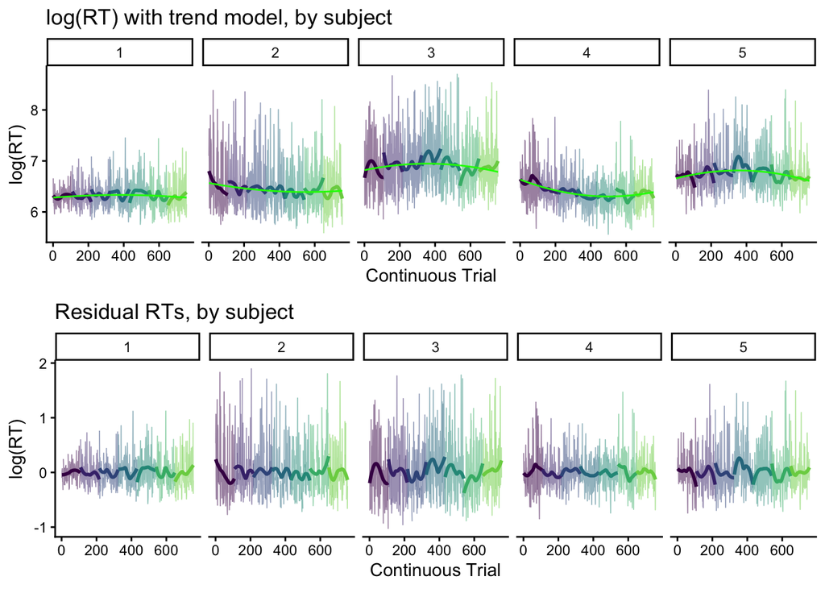

```r
subs <- alt_run$id %>% unique() %>% head(5)

plt_rt_w_model <- ggplot(alt_run %>% filter(id %in% subs), aes(x = trial_cont, y = time_log, color = block, group = interaction(id, block)))+
  geom_line(alpha = 0.5, lwd = 0.3)+
  geom_smooth(se = FALSE)+
  geom_line(aes(y = time_log_pred), color = "green")+
  scale_color_viridis_c(end = 0.8)+
  facet_grid(~id)+
  labs(x = "Continuous Trial", y = "log(RT)", title = "log(RT) with trend model, by subject")+
  theme_classic()+
  theme(legend.position = "none")

plt_rt_residuals <- ggplot(alt_run %>% filter(id %in% subs), aes(x = trial_cont, y = time_log_res, color = block, group = interaction(id, block)))+
  geom_line(alpha = 0.5, lwd = 0.3)+
  geom_smooth(se = FALSE)+
  scale_color_viridis_c(end = 0.8)+
  facet_grid(~id)+
  labs(x = "Continuous Trial", y = "log(RT)", title = "Residual RTs, by subject")+
  theme_classic()+
  theme(legend.position = "none")

ggpubr::ggarrange(plt_rt_w_model, plt_rt_residuals, nrow = 2)
```

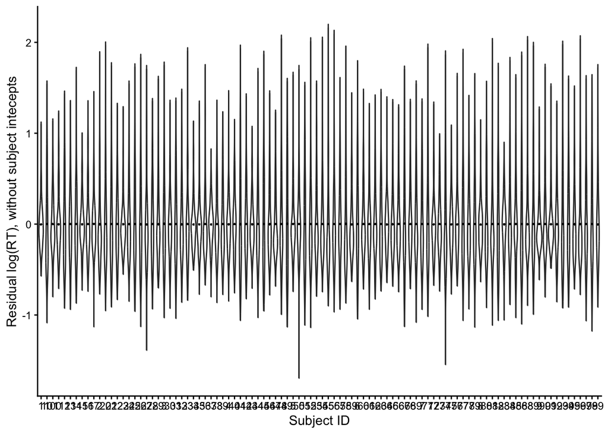

```r
alt_run %>%
  group_by(id) %>%
  mutate(M_time_log_res = mean(time_log_res, na.rm = TRUE)) %>%
  ggplot()+
  geom_violin(aes(x = id, y = time_log_res))+
  geom_point(aes(x = id, y = M_time_log_res), size = 0.1)+
  theme_classic() +
  labs(x = "Subject ID",
       y = "Residual log(RT), without subject intecepts")
```

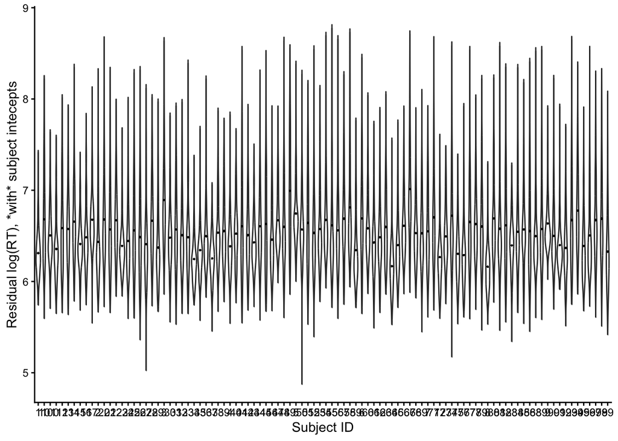

```r
alt_run %>%
  group_by(id) %>%
  mutate(M_time_log_res_w_s_int = mean(time_log_res_w_s_int, na.rm = TRUE)) %>%
  ggplot()+
  geom_violin(aes(x = id, y = time_log_res_w_s_int))+
  geom_point(aes(x = id, y = M_time_log_res_w_s_int), size = 0.1)+
  theme_classic() +
  labs(x = "Subject ID",
       y = "Residual log(RT), *with* subject intecepts")
```

# 3 Data Aggregation by cycle

```r
alt_run_agg_ID <- alt_run %>%
  group_by(id, is_bivalent_contr, prev_bivalent_contr, switch_contr, cycle) %>%
  summarize(RT = mean(time[filter_correct == 0], na.rm = TRUE),
            RT_log = mean(time_log[filter_correct == 0], na.rm = TRUE),
            Error = mean(error, na.rm = TRUE))
```

```
## 'prev_bivalent_contr', 'switch_contr'. You can override using the `.groups`
## argument.
```

```r
alt_run_agg <- alt_run_agg_ID %>%
  normWS(s = "id", dv = "RT") %>%
  mutate(RT = DV_n) %>%
  normWS(s = "id", dv = "RT_log") %>%
  mutate(RT_log = DV_n) %>%
  normWS(s = "id", dv = "Error") %>%
  mutate(Error = DV_n) %>%
  group_by(is_bivalent_contr, prev_bivalent_contr, switch_contr, cycle) %>%
  summarize(RT_m = mean(RT, na.rm = TRUE),
            RT_ci_lower = get_ci(RT, RT_m)[1],
            RT_ci_upper = get_ci(RT, RT_m)[2],
            RT_log_m = mean(RT_log, na.rm = TRUE),
            RT_log_ci_lower = get_ci(RT_log, RT_log_m)[1],
            RT_log_ci_upper = get_ci(RT_log, RT_log_m)[2],
            Error_m = mean(Error, na.rm = TRUE),
            Error_ci_lower = get_ci(Error, Error_m)[1],
            Error_ci_upper = get_ci(Error, Error_m)[2]
  )
```

```
## 'switch_contr'. You can override using the `.groups` argument.
```

```r
alt_run_contr_agg_ID <- alt_run %>%
  group_by(id, is_bivalent_contr, prev_bivalent_contr, switch_contr) %>%
  summarize(RT = mean(time[filter_correct == 0], na.rm = TRUE),
            RT_log = mean(time_log[filter_correct == 0], na.rm = TRUE),
            Error = mean(error, na.rm = TRUE))
```

```
## 'prev_bivalent_contr'. You can override using the `.groups` argument.
```

```r
alt_run_contr_agg <- alt_run_agg_ID %>%
  normWS(s = "id", dv = "RT") %>%
  mutate(RT = DV_n) %>%
  normWS(s = "id", dv = "RT_log") %>%
  mutate(RT_log = DV_n) %>%
  normWS(s = "id", dv = "Error") %>%
  mutate(Error = DV_n) %>%
  group_by(is_bivalent_contr, prev_bivalent_contr, switch_contr) %>%
  summarize(RT_m = mean(RT, na.rm = TRUE),
            RT_ci_lower = get_ci(RT, RT_m)[1],
            RT_ci_upper = get_ci(RT, RT_m)[2],
            RT_log_m = mean(RT_log, na.rm = TRUE),
            RT_log_ci_lower = get_ci(RT_log, RT_log_m)[1],
            RT_log_ci_upper = get_ci(RT_log, RT_log_m)[2],
            Error_m = mean(Error, na.rm = TRUE),
            Error_ci_lower = get_ci(Error, Error_m)[1],
            Error_ci_upper = get_ci(Error, Error_m)[2]
  )
```

```
## You can override using the `.groups` argument.
```

# 4 Plots of correct RTs and Errors

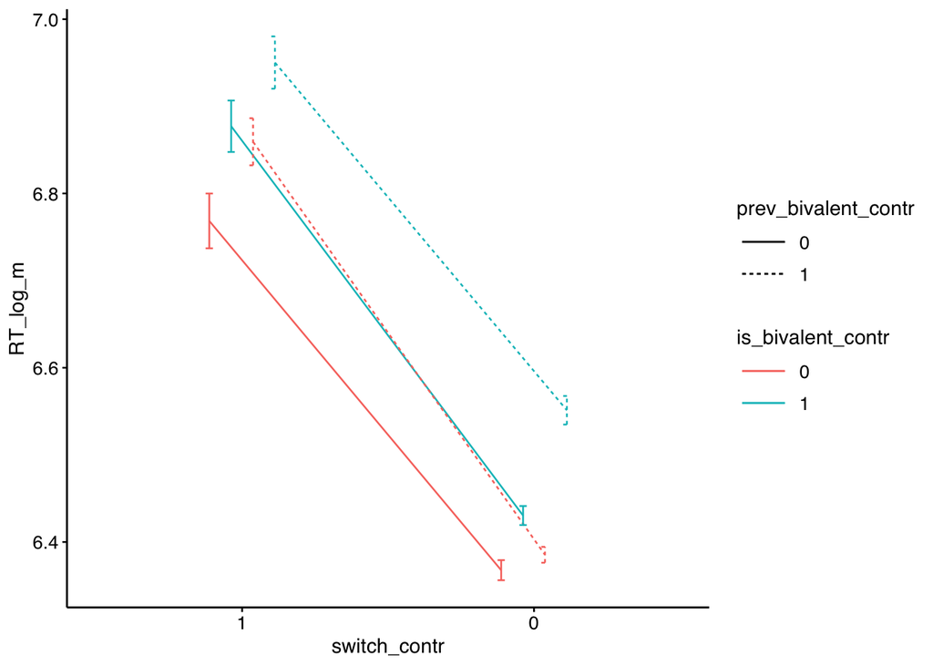

```r
pos <- position_dodge(width = 0.3)

plt_rtlog_cycle <- ggplot(alt_run_agg, aes(x = cycle, y = RT_log_m, color = is_bivalent_contr, linetype = prev_bivalent_contr, group = interaction(is_bivalent_contr, prev_bivalent_contr)))+
  geom_line(position = pos)+
  geom_errorbar(aes(ymin = RT_log_ci_lower, ymax = RT_log_ci_upper), width = 0.1, position = pos)

plt_rt_cycle <- ggplot(alt_run_agg, aes(x = cycle, y = RT_m, color = is_bivalent_contr, linetype = prev_bivalent_contr, group = interaction(is_bivalent_contr, prev_bivalent_contr)))+
  geom_line(position = pos)+
  geom_errorbar(aes(ymin = RT_ci_lower, ymax = RT_ci_upper), width = 0.1, position = pos)


plt_error_cycle <- ggplot(alt_run_agg, aes(x = cycle, y = Error_m, color = is_bivalent_contr, linetype = prev_bivalent_contr, group = interaction(is_bivalent_contr, prev_bivalent_contr)))+
  geom_line(position = pos)+
  geom_errorbar(aes(ymin = Error_ci_lower, ymax = Error_ci_upper), width = 0.1, position = pos)

#########################

plt_rtlog_switch <- ggplot(alt_run_contr_agg, aes(x = switch_contr, y = RT_log_m, color = is_bivalent_contr, linetype = prev_bivalent_contr, group = interaction(is_bivalent_contr, prev_bivalent_contr)))+
  geom_line(position = pos)+
  geom_errorbar(aes(ymin = RT_log_ci_lower, ymax = RT_log_ci_upper), width = 0.1, position = pos)+
  scale_x_discrete(limits = c("1", "0"))
plt_rtlog_switch
```

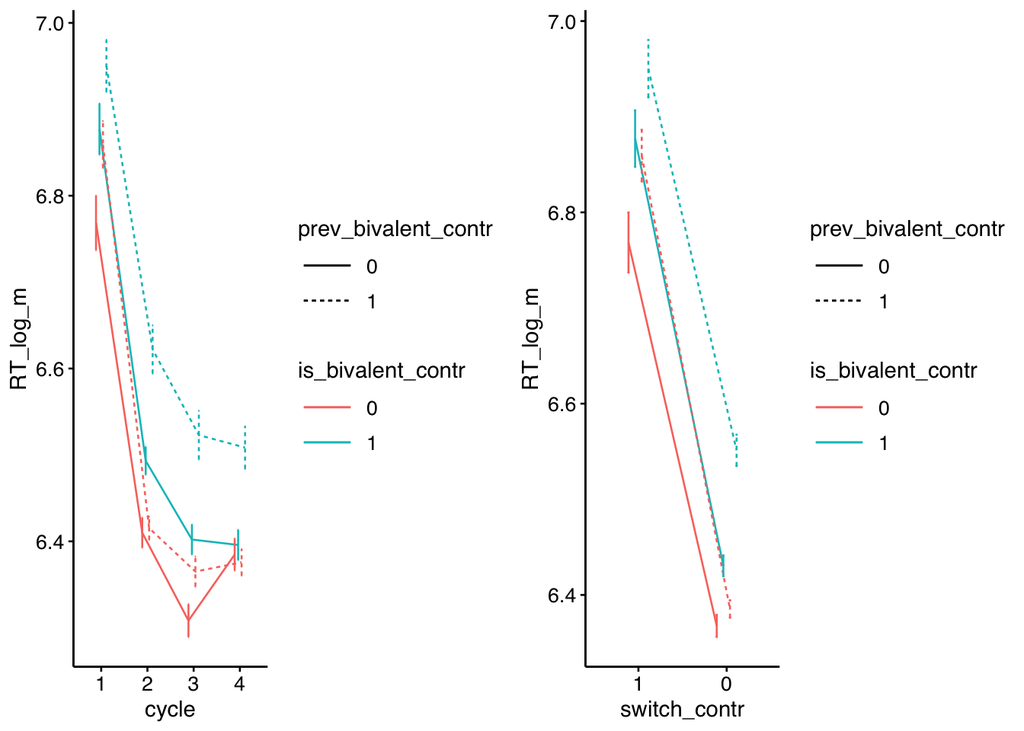

```r
plt_rt_switch <- ggplot(alt_run_contr_agg, aes(x = switch_contr, y = RT_m, color = is_bivalent_contr, linetype = prev_bivalent_contr, group = interaction(is_bivalent_contr, prev_bivalent_contr)))+
  geom_line(position = pos)+
  geom_errorbar(aes(ymin = RT_ci_lower, ymax = RT_ci_upper), width = 0.1, position = pos)+
  scale_x_discrete(limits = c("1", "0"))


plt_error_switch <- ggplot(alt_run_contr_agg, aes(x = switch_contr, y = Error_m, color = is_bivalent_contr, linetype = prev_bivalent_contr, group = interaction(is_bivalent_contr, prev_bivalent_contr)))+
  geom_line(position = pos)+
  geom_errorbar(aes(ymin = Error_ci_lower, ymax = Error_ci_upper), width = 0.1, position = pos)+
  scale_x_discrete(limits = c("1", "0"))


ggpubr::ggarrange(plt_rtlog_cycle, plt_rtlog_switch)
```

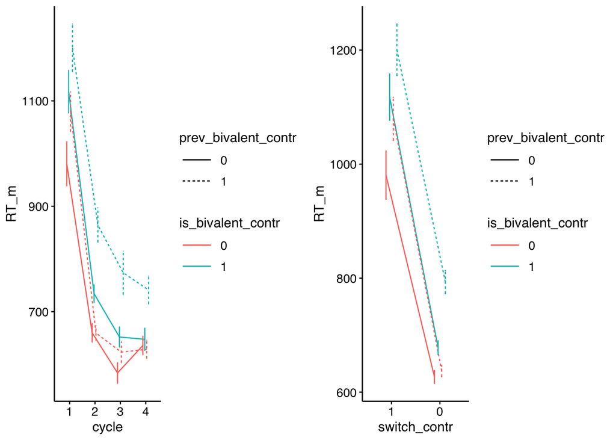

```r
ggpubr::ggarrange(plt_rt_cycle, plt_rt_switch)
```

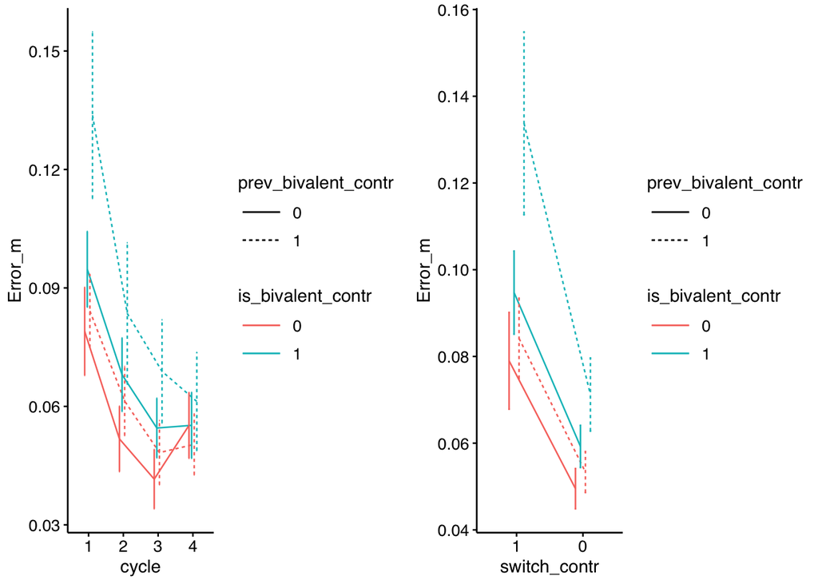

```r
ggpubr::ggarrange(plt_error_cycle, plt_error_switch)
```

## 4.1 Publication Figures

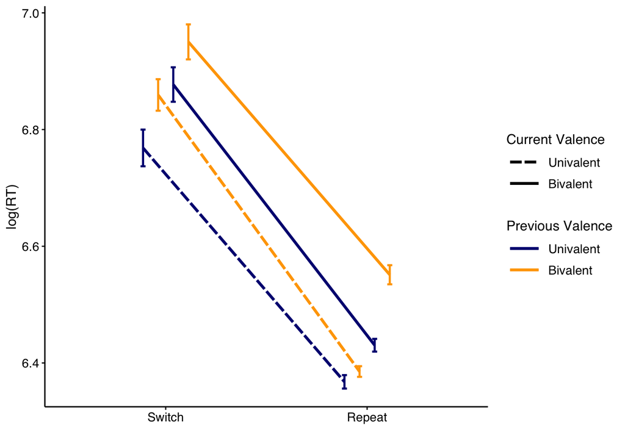

```r
plt_RT_log <- ggplot(alt_run_contr_agg, aes(x = switch_contr, y = RT_log_m, color = prev_bivalent_contr, linetype = is_bivalent_contr, group = interaction(prev_bivalent_contr, is_bivalent_contr)))+
  geom_line(position = pos, linewidth = design$lines$linewidth)+
  geom_errorbar(aes(ymin = RT_log_ci_lower, ymax = RT_log_ci_upper),
                width = design$errorbar$width,
                position = pos,
                linewidth = design$errorbar$linewidth,
                linetype = "solid")+
  scale_linetype_manual(name = "Current Valence",
                       labels = c("0" = "Univalent",
                                  "1" = "Bivalent"),
                       values = c("0" = design$curr_val$linetype$uni,
                                 "1" = design$curr_val$linetype$bi))+
  scale_color_manual(name = "Previous Valence",
                       labels = c("0" = "Univalent",
                                  "1" = "Bivalent"),
                       values = c("0" = design$prev_val$color$uni,
                                 "1" = design$prev_val$color$bi))+
  scale_x_discrete(limits = c("1", "0"), labels = c("1" = "Switch", "0" = "Repeat"))+
  labs(x = "", y = "log(RT)")+
  guides(
    linetype = guide_legend(order = 1),
    color    = guide_legend(order = 2)
  )

plt_RT_log
```

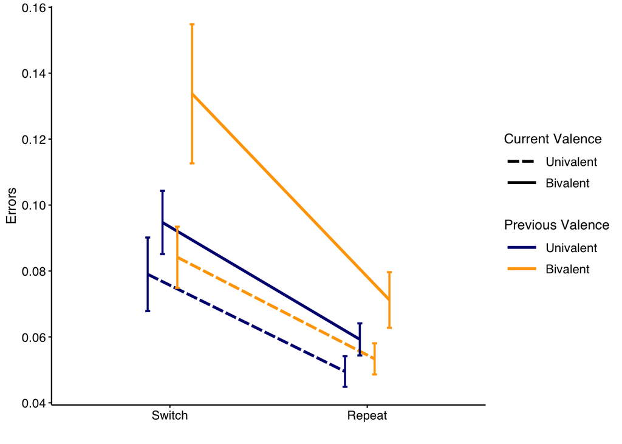

```r
ggsave(plot = plt_RT_log, "figures/AR_RTlog.svg", width = 5, height = 5, units = "in")
saveRDS(plt_RT_log, "figures/AR_RTlog.RDS")

plt_Error <- ggplot(alt_run_contr_agg, aes(x = switch_contr, y = Error_m, color = prev_bivalent_contr, linetype = is_bivalent_contr, group = interaction(is_bivalent_contr, prev_bivalent_contr)))+
  geom_line(position = pos, linewidth = design$lines$linewidth)+
  geom_errorbar(aes(ymin = Error_ci_lower, ymax = Error_ci_upper),
                width = design$errorbar$width,
                position = pos,
                linewidth = design$errorbar$linewidth,
                linetype = "solid")+
  scale_linetype_manual(name = "Current Valence",
                       labels = c("0" = "Univalent",
                                  "1" = "Bivalent"),
                       values = c("0" = design$curr_val$linetype$uni,
                                 "1" = design$curr_val$linetype$bi))+
  scale_color_manual(name = "Previous Valence",
                       labels = c("0" = "Univalent",
                                  "1" = "Bivalent"),
                       values = c("0" = design$prev_val$color$uni,
                                 "1" = design$prev_val$color$bi))+
  scale_x_discrete(limits = c("1", "0"), labels = c("1" = "Switch", "0" = "Repeat"))+
  labs(x = "", y = "Errors")
plt_Error
```

```r
ggsave(plot = plt_Error, "figures/AR_Errors.svg", width = 5, height = 5, units = "in")
saveRDS(plt_Error, "figures/AR_Errors.RDS")
```

# 5 Stats:

## 5.1 RT

### 5.1.1 Effect coded valence (-0.5, 0.5)

```r
alt_run_rt_log_eff <- lmer(time_log ~ is_bivalent_eff * prev_bivalent_eff * switch_contr + (is_bivalent_eff + prev_bivalent_eff + switch_contr|id),
                           alt_run %>%
                             filter(filter_correct == 0),
                           control = lmerControl(optimizer = "bobyqa"))

make_model_table(alt_run_rt_log_eff)
```

| Call: lmer(formula = time_log ~ is_bivalent_eff * prev_bivalent_eff * switch_contr + (is_bivalent_eff + prev_bivalent_eff + switch_contr \| id), data = alt_run %>% filter(filter_correct == 0), control… term | Call: lmer(formula = time_log ~ is_bivalent_eff * prev_bivalent_eff * switch_contr + (is_bivalent_eff + prev_bivalent_eff + switch_contr \| id), data = alt_run %>% filter(filter_correct == 0), control… Estimate | Call: lmer(formula = time_log ~ is_bivalent_eff * prev_bivalent_eff * switch_contr + (is_bivalent_eff + prev_bivalent_eff + switch_contr \| id), data = alt_run %>% filter(filter_correct == 0), control… Std. Error | Call: lmer(formula = time_log ~ is_bivalent_eff * prev_bivalent_eff * switch_contr + (is_bivalent_eff + prev_bivalent_eff + switch_contr \| id), data = alt_run %>% filter(filter_correct == 0), control… df | Call: lmer(formula = time_log ~ is_bivalent_eff * prev_bivalent_eff * switch_contr + (is_bivalent_eff + prev_bivalent_eff + switch_contr \| id), data = alt_run %>% filter(filter_correct == 0), control… t value | Call: lmer(formula = time_log ~ is_bivalent_eff * prev_bivalent_eff * switch_contr + (is_bivalent_eff + prev_bivalent_eff + switch_contr \| id), data = alt_run %>% filter(filter_correct == 0), control… Pr(>\|t\|) |
| --- | --- | --- | --- | --- | --- |
| (Intercept) | 6.43 | 0.01 | 95.08 | 439.68 | 0.0000 |
| is_bivalent_eff1 | 0.11 | 0.01 | 103.97 | 15.92 | 0.0000 |
| prev_bivalent_eff1 | 0.07 | 0.01 | 107.21 | 10.49 | 0.0000 |
| switch_contr1 | 0.43 | 0.02 | 95.13 | 28.44 | 0.0000 |
| is_bivalent_eff1:prev_bivalent_eff1 | 0.09 | 0.01 | 63,666.78 | 13.32 | 0.0000 |
| is_bivalent_eff1:switch_contr1 | -0.01 | 0.01 | 64,918.07 | -1.39 | 0.1659 |
| prev_bivalent_eff1:switch_contr1 | 0.01 | 0.01 | 64,919.12 | 2.13 | 0.0330 |
| is_bivalent_eff1:prev_bivalent_eff1:switch_contr1 | -0.11 | 0.01 | 64,879.46 | -8.25 | 0.0000 |

#### 5.1.1.1 Adding individual differences

```r
alt_run_id <- alt_run %>%
  filter(!is.na(cog_score))

alt_run_rt_log_eff_id_cog <- lmer(time_log ~ is_bivalent_eff * prev_bivalent_eff * switch_contr * cog_score + (is_bivalent_eff + prev_bivalent_eff + switch_contr|id),
                           alt_run_id %>%
                             filter(filter_correct == 0), control = lmerControl(optimizer = "bobyqa"))

make_model_table(alt_run_rt_log_eff_id_cog)
```

| Call: lmer(formula = time_log ~ is_bivalent_eff * prev_bivalent_eff * switch_contr * cog_score + (is_bivalent_eff + prev_bivalent_eff + switch_contr \| id), data = alt_run_id %>% filter(filter_correct… term | Call: lmer(formula = time_log ~ is_bivalent_eff * prev_bivalent_eff * switch_contr * cog_score + (is_bivalent_eff + prev_bivalent_eff + switch_contr \| id), data = alt_run_id %>% filter(filter_correct… Estimate | Call: lmer(formula = time_log ~ is_bivalent_eff * prev_bivalent_eff * switch_contr * cog_score + (is_bivalent_eff + prev_bivalent_eff + switch_contr \| id), data = alt_run_id %>% filter(filter_correct… Std. Error | Call: lmer(formula = time_log ~ is_bivalent_eff * prev_bivalent_eff * switch_contr * cog_score + (is_bivalent_eff + prev_bivalent_eff + switch_contr \| id), data = alt_run_id %>% filter(filter_correct… df | Call: lmer(formula = time_log ~ is_bivalent_eff * prev_bivalent_eff * switch_contr * cog_score + (is_bivalent_eff + prev_bivalent_eff + switch_contr \| id), data = alt_run_id %>% filter(filter_correct… t value | Call: lmer(formula = time_log ~ is_bivalent_eff * prev_bivalent_eff * switch_contr * cog_score + (is_bivalent_eff + prev_bivalent_eff + switch_contr \| id), data = alt_run_id %>% filter(filter_correct… Pr(>\|t\|) |
| --- | --- | --- | --- | --- | --- |
| (Intercept) | 6.44 | 0.02 | 56.10 | 359.12 | 0.0000 |
| is_bivalent_eff1 | 0.12 | 0.01 | 60.90 | 12.03 | 0.0000 |
| prev_bivalent_eff1 | 0.07 | 0.01 | 62.38 | 7.92 | 0.0000 |
| switch_contr1 | 0.44 | 0.02 | 56.15 | 22.01 | 0.0000 |
| cog_score | -0.06 | 0.02 | 56.14 | -2.64 | 0.0106 |
| is_bivalent_eff1:prev_bivalent_eff1 | 0.12 | 0.01 | 35,427.93 | 13.48 | 0.0000 |
| is_bivalent_eff1:switch_contr1 | -0.01 | 0.01 | 37,502.07 | -0.96 | 0.3378 |
| prev_bivalent_eff1:switch_contr1 | 0.02 | 0.01 | 37,501.01 | 1.70 | 0.0899 |
| is_bivalent_eff1:cog_score | -0.03 | 0.01 | 61.25 | -2.42 | 0.0187 |
| prev_bivalent_eff1:cog_score | -0.02 | 0.01 | 62.80 | -1.85 | 0.0684 |
| switch_contr1:cog_score | -0.01 | 0.03 | 56.20 | -0.52 | 0.6045 |
| is_bivalent_eff1:prev_bivalent_eff1:switch_contr1 | -0.11 | 0.02 | 37,471.62 | -6.00 | 0.0000 |
| is_bivalent_eff1:prev_bivalent_eff1:cog_score | -0.01 | 0.01 | 33,801.39 | -0.78 | 0.4346 |
| is_bivalent_eff1:switch_contr1:cog_score | -0.01 | 0.01 | 37,477.31 | -0.80 | 0.4245 |
| prev_bivalent_eff1:switch_contr1:cog_score | -0.01 | 0.01 | 37,449.73 | -0.71 | 0.4802 |
| is_bivalent_eff1:prev_bivalent_eff1:switch_contr1:cog_score | 0.01 | 0.02 | 37,484.05 | 0.40 | 0.6901 |

### 5.1.2 Contrast coded (0, 1)

https://stats.stackexchange.com/questions/381877/whether-to-use-factors-in-r-and-when-ordered-factors#:~:text=One%20of%20the%20categories%20is,does%20not%20cause%20any%20problem.

https://github.com/KennethEnevoldsen/Exp-Meth-III-Tutorials/issues/2

https://github.com/runehaubo/lmerTestR/issues/30

https://stats.stackexchange.com/questions/530804/sjplots-tab-model-and-summary-function-give-different-results-in-multilevel

https://stackoverflow.com/a/77664683

```r
alt_run_rt_log_contr <- lmer(time_log ~ is_bivalent_contr * prev_bivalent_contr * switch_contr + (is_bivalent_contr + prev_bivalent_contr + switch_contr|id),
                             alt_run %>%
                               filter(filter_correct == 0),
                             control = lmerControl(optimizer = "bobyqa"))

make_model_table(alt_run_rt_log_contr)
```

| Call: lmer(formula = time_log ~ is_bivalent_contr * prev_bivalent_contr * switch_contr + (is_bivalent_contr + prev_bivalent_contr + switch_contr \| id), data = alt_run %>% filter(filter_correct == 0),… term | Call: lmer(formula = time_log ~ is_bivalent_contr * prev_bivalent_contr * switch_contr + (is_bivalent_contr + prev_bivalent_contr + switch_contr \| id), data = alt_run %>% filter(filter_correct == 0),… Estimate | Call: lmer(formula = time_log ~ is_bivalent_contr * prev_bivalent_contr * switch_contr + (is_bivalent_contr + prev_bivalent_contr + switch_contr \| id), data = alt_run %>% filter(filter_correct == 0),… Std. Error | Call: lmer(formula = time_log ~ is_bivalent_contr * prev_bivalent_contr * switch_contr + (is_bivalent_contr + prev_bivalent_contr + switch_contr \| id), data = alt_run %>% filter(filter_correct == 0),… df | Call: lmer(formula = time_log ~ is_bivalent_contr * prev_bivalent_contr * switch_contr + (is_bivalent_contr + prev_bivalent_contr + switch_contr \| id), data = alt_run %>% filter(filter_correct == 0),… t value | Call: lmer(formula = time_log ~ is_bivalent_contr * prev_bivalent_contr * switch_contr + (is_bivalent_contr + prev_bivalent_contr + switch_contr \| id), data = alt_run %>% filter(filter_correct == 0),… Pr(>\|t\|) |
| --- | --- | --- | --- | --- | --- |
| (Intercept) | 6.36 | 0.01 | 99.90 | 445.94 | 0.0000 |
| is_bivalent_contr1 | 0.06 | 0.01 | 159.44 | 8.36 | 0.0000 |
| prev_bivalent_contr1 | 0.02 | 0.01 | 175.55 | 2.89 | 0.0044 |
| switch_contr1 | 0.40 | 0.02 | 130.15 | 24.41 | 0.0000 |
| is_bivalent_contr1:prev_bivalent_contr1 | 0.09 | 0.01 | 63,666.64 | 13.32 | 0.0000 |
| is_bivalent_contr1:switch_contr1 | 0.05 | 0.01 | 64,899.24 | 4.86 | 0.0000 |
| prev_bivalent_contr1:switch_contr1 | 0.07 | 0.01 | 64,902.36 | 7.38 | 0.0000 |
| is_bivalent_contr1:prev_bivalent_contr1:switch_contr1 | -0.11 | 0.01 | 64,879.46 | -8.25 | 0.0000 |

## 5.2 Errors

### 5.2.1 Effect coded valence (-0.5, 0.5)

```r
alt_run_error_eff <- xfun::cache_rds({

  glmer(error ~ is_bivalent_eff * prev_bivalent_eff * switch_contr + (is_bivalent_eff + prev_bivalent_eff + switch_contr|id),
        family = "binomial",
        control = glmerControl(optimizer = "bobyqa"),
        alt_run)
}, dir = "dominik/models/", file = "alt_run_errors.RDS", rerun = rerun_all)

make_model_table(alt_run_error_eff)
```

| Call: glmer(formula = error ~ is_bivalent_eff * prev_bivalent_eff * switch_contr + (is_bivalent_eff + prev_bivalent_eff + switch_contr \| id), data = alt_run, family = "binomial", control = glmerContr… term | Call: glmer(formula = error ~ is_bivalent_eff * prev_bivalent_eff * switch_contr + (is_bivalent_eff + prev_bivalent_eff + switch_contr \| id), data = alt_run, family = "binomial", control = glmerContr… Estimate | Call: glmer(formula = error ~ is_bivalent_eff * prev_bivalent_eff * switch_contr + (is_bivalent_eff + prev_bivalent_eff + switch_contr \| id), data = alt_run, family = "binomial", control = glmerContr… Std. Error | Call: glmer(formula = error ~ is_bivalent_eff * prev_bivalent_eff * switch_contr + (is_bivalent_eff + prev_bivalent_eff + switch_contr \| id), data = alt_run, family = "binomial", control = glmerContr… z value | Call: glmer(formula = error ~ is_bivalent_eff * prev_bivalent_eff * switch_contr + (is_bivalent_eff + prev_bivalent_eff + switch_contr \| id), data = alt_run, family = "binomial", control = glmerContr… Pr(>\|z\|) |
| --- | --- | --- | --- | --- |
| (Intercept) | -3.07 | 0.08 | -38.39 | 0.0000 |
| is_bivalent_eff1 | 0.24 | 0.07 | 3.52 | 0.0004 |
| prev_bivalent_eff1 | 0.08 | 0.07 | 1.23 | 0.2182 |
| switch_contr1 | 0.53 | 0.04 | 12.46 | 0.0000 |
| is_bivalent_eff1:prev_bivalent_eff1 | -0.07 | 0.08 | -0.86 | 0.3895 |
| is_bivalent_eff1:switch_contr1 | 0.17 | 0.06 | 2.60 | 0.0092 |
| prev_bivalent_eff1:switch_contr1 | 0.16 | 0.06 | 2.44 | 0.0147 |
| is_bivalent_eff1:prev_bivalent_eff1:switch_contr1 | 0.18 | 0.13 | 1.44 | 0.1496 |

Model figure:

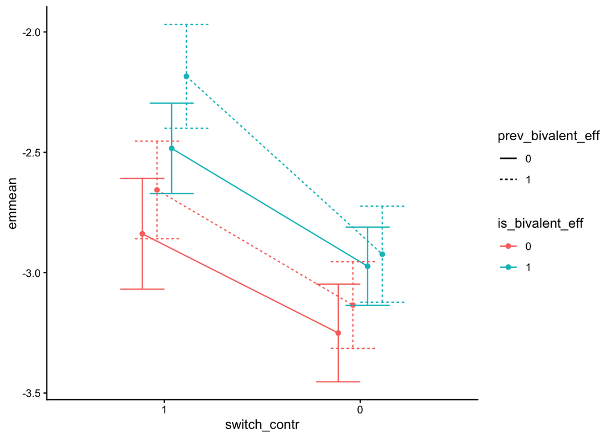

```r
pos  = position_dodge(width = 0.3)
emmeans::emmeans(alt_run_error_eff, ~is_bivalent_eff * prev_bivalent_eff * switch_contr) %>%
  as.data.frame() %>%
  ggplot(aes(x = switch_contr, y = emmean, linetype = prev_bivalent_eff, color = is_bivalent_eff, group = interaction(prev_bivalent_eff, is_bivalent_eff)))+
  geom_line(position = pos)+
  geom_point(position = pos)+
  geom_errorbar(aes(ymin = asymp.LCL, max = asymp.UCL), position = pos)+
  scale_x_discrete(limits = c("1", "0"))+
  theme_classic()
```

#### 5.2.1.1 Adding individual differences

```r
alt_run_error_eff_cogscore <- xfun::cache_rds({

  glmer(error ~ is_bivalent_eff * prev_bivalent_eff * switch_contr * cog_score + (is_bivalent_eff + prev_bivalent_eff + switch_contr|id),
        family = "binomial",
        control = glmerControl(optimizer = "bobyqa"),
        alt_run)
}, dir = "dominik/models/", file = "alt_run_error_eff_cogscore.RDS", rerun = rerun_all)

make_model_table(alt_run_error_eff_cogscore)
```

| Call: glmer(formula = error ~ is_bivalent_eff * prev_bivalent_eff * switch_contr * cog_score + (is_bivalent_eff + prev_bivalent_eff + switch_contr \| id), data = alt_run, family = "binomial", control … term | Call: glmer(formula = error ~ is_bivalent_eff * prev_bivalent_eff * switch_contr * cog_score + (is_bivalent_eff + prev_bivalent_eff + switch_contr \| id), data = alt_run, family = "binomial", control … Estimate | Call: glmer(formula = error ~ is_bivalent_eff * prev_bivalent_eff * switch_contr * cog_score + (is_bivalent_eff + prev_bivalent_eff + switch_contr \| id), data = alt_run, family = "binomial", control … Std. Error | Call: glmer(formula = error ~ is_bivalent_eff * prev_bivalent_eff * switch_contr * cog_score + (is_bivalent_eff + prev_bivalent_eff + switch_contr \| id), data = alt_run, family = "binomial", control … z value | Call: glmer(formula = error ~ is_bivalent_eff * prev_bivalent_eff * switch_contr * cog_score + (is_bivalent_eff + prev_bivalent_eff + switch_contr \| id), data = alt_run, family = "binomial", control … Pr(>\|z\|) |
| --- | --- | --- | --- | --- |
| (Intercept) | -3.13 | 0.10 | -31.31 | 0.0000 |
| is_bivalent_eff1 | 0.30 | 0.09 | 3.13 | 0.0018 |
| prev_bivalent_eff1 | 0.11 | 0.10 | 1.17 | 0.2433 |
| switch_contr1 | 0.60 | 0.05 | 11.58 | 0.0000 |
| cog_score | -0.20 | 0.14 | -1.50 | 0.1347 |
| is_bivalent_eff1:prev_bivalent_eff1 | -0.13 | 0.11 | -1.24 | 0.2141 |
| is_bivalent_eff1:switch_contr1 | 0.08 | 0.09 | 0.88 | 0.3813 |
| prev_bivalent_eff1:switch_contr1 | 0.08 | 0.09 | 0.96 | 0.3385 |
| is_bivalent_eff1:cog_score | -0.10 | 0.13 | -0.78 | 0.4379 |
| prev_bivalent_eff1:cog_score | 0.04 | 0.13 | 0.29 | 0.7737 |
| switch_contr1:cog_score | 0.07 | 0.06 | 1.16 | 0.2467 |
| is_bivalent_eff1:prev_bivalent_eff1:switch_contr1 | 0.33 | 0.17 | 1.92 | 0.0545 |
| is_bivalent_eff1:prev_bivalent_eff1:cog_score | -0.28 | 0.14 | -1.97 | 0.0483 |
| is_bivalent_eff1:switch_contr1:cog_score | 0.11 | 0.12 | 0.96 | 0.3356 |
| prev_bivalent_eff1:switch_contr1:cog_score | -0.15 | 0.12 | -1.24 | 0.2132 |
| is_bivalent_eff1:prev_bivalent_eff1:switch_contr1:cog_score | 0.03 | 0.23 | 0.14 | 0.8910 |

### 5.2.2 Contrast coded (0, 1)

```r
alt_run_error_contr <- xfun::cache_rds({
  glmer(error ~ is_bivalent_contr * prev_bivalent_contr * switch_contr + (is_bivalent_contr + prev_bivalent_contr + switch_contr|id),
        family = "binomial",
        control = glmerControl(optimizer = "bobyqa"),
        alt_run)

}, dir = "dominik/models/", file = "alt_run_error_contr.RDS", rerun = rerun_all)

make_model_table(alt_run_error_contr)
```

| Call: glmer(formula = error ~ is_bivalent_contr * prev_bivalent_contr * switch_contr + (is_bivalent_contr + prev_bivalent_contr + switch_contr \| id), data = alt_run, family = "binomial", control = gl… term | Call: glmer(formula = error ~ is_bivalent_contr * prev_bivalent_contr * switch_contr + (is_bivalent_contr + prev_bivalent_contr + switch_contr \| id), data = alt_run, family = "binomial", control = gl… Estimate | Call: glmer(formula = error ~ is_bivalent_contr * prev_bivalent_contr * switch_contr + (is_bivalent_contr + prev_bivalent_contr + switch_contr \| id), data = alt_run, family = "binomial", control = gl… Std. Error | Call: glmer(formula = error ~ is_bivalent_contr * prev_bivalent_contr * switch_contr + (is_bivalent_contr + prev_bivalent_contr + switch_contr \| id), data = alt_run, family = "binomial", control = gl… z value | Call: glmer(formula = error ~ is_bivalent_contr * prev_bivalent_contr * switch_contr + (is_bivalent_contr + prev_bivalent_contr + switch_contr \| id), data = alt_run, family = "binomial", control = gl… Pr(>\|z\|) |
| --- | --- | --- | --- | --- |
| (Intercept) | -3.25 | 0.10 | -31.50 | 0.0000 |
| is_bivalent_contr1 | 0.28 | 0.08 | 3.48 | 0.0005 |
| prev_bivalent_contr1 | 0.12 | 0.08 | 1.47 | 0.1425 |
| switch_contr1 | 0.41 | 0.08 | 5.34 | 0.0000 |
| is_bivalent_contr1:prev_bivalent_contr1 | -0.07 | 0.08 | -0.86 | 0.3894 |
| is_bivalent_contr1:switch_contr1 | 0.08 | 0.09 | 0.84 | 0.4033 |
| prev_bivalent_contr1:switch_contr1 | 0.07 | 0.09 | 0.70 | 0.4840 |
| is_bivalent_contr1:prev_bivalent_contr1:switch_contr1 | 0.18 | 0.13 | 1.44 | 0.1489 |

# 6 DDM analysis

## 6.1 Aggregation and data processing

```r
alt_run_agg_ID_ddm <- alt_run %>%
  mutate(RT_s = time/1000) %>%
  group_by(id, is_bivalent_contr, prev_bivalent_contr, switch_contr, cycle) %>%
  summarize(RT_log =  mean(time_log[filter_correct == 0], na.rm = TRUE),
            RT_s_m = mean(RT_s[filter_correct == 0], na.rm = TRUE),
            RT_s_var = var(RT_s[filter_correct == 0], na.rm = TRUE),
            Error = mean(error, na.rm = TRUE),
            N_trials = n()) %>%
  rowwise() %>%
  mutate(ezddm = list(ezddm(propCorrect = convert_extremes(1-Error),
                            rtCorrectVariance_seconds = RT_s_var,
                            rtCorrectMean_seconds = RT_s_m,
                            nTrials = N_trials))) %>%
  unnest(ezddm)
```

```
## 'prev_bivalent_contr', 'switch_contr'. You can override using the `.groups`
## argument.
```

```
## Oops, propCorrect == 0.5 (chance performance; drift will be close to 0). Added 0.00001 to propCorrect.
## Oops, propCorrect == 0.5 (chance performance; drift will be close to 0). Added 0.00001 to propCorrect.
```

```r
alt_run_agg_ddm <- alt_run_agg_ID_ddm %>%
  group_by(id, is_bivalent_contr, prev_bivalent_contr, switch_contr, cycle) %>%
  normWS(s = "id", dv = "a") %>%
  mutate(a = DV_n) %>%
  normWS(s = "id", dv = "v") %>%
  mutate(v = DV_n) %>%
  normWS(s = "id", dv = "Ter") %>%
  mutate(Ter = DV_n) %>%
  group_by(is_bivalent_contr, prev_bivalent_contr, switch_contr, cycle) %>%
  summarize(a_m = mean(a, na.rm = TRUE),
            a_ci_lower = get_ci(a, a_m)[1],
            a_ci_upper = get_ci(a, a_m)[2],
            v_m = mean(v, na.rm = TRUE),
            v_ci_lower = get_ci(v, v_m)[1],
            v_ci_upper = get_ci(v, v_m)[2],
            Ter_m = mean(Ter, na.rm = TRUE),
            Ter_ci_lower = get_ci(Ter, Ter_m)[1],
            Ter_ci_upper = get_ci(Ter, Ter_m)[2],)
```

```
## 'switch_contr'. You can override using the `.groups` argument.
```

## 6.2 Statistical Models

### 6.2.1 First prep data so that it’s ignoring cycle

```r
alt_run_agg_ID_ddm_nocycle <- alt_run %>%
  mutate(RT_s = time/1000) %>%
  group_by(id, is_bivalent_eff, is_bivalent_contr, prev_bivalent_eff, prev_bivalent_contr, switch_eff, switch_contr) %>%
  summarize(RT_log =  mean(time_log[filter_correct == 0], na.rm = TRUE),
            RT_s_m = mean(RT_s[filter_correct == 0], na.rm = TRUE),
            RT_s_var = var(RT_s[filter_correct == 0], na.rm = TRUE),
            Error = mean(error, na.rm = TRUE),
            N_trials = n()) %>%
  rowwise() %>%
  mutate(ezddm = list(ezddm(propCorrect = convert_extremes(1-Error),
                            rtCorrectVariance_seconds = RT_s_var,
                            rtCorrectMean_seconds = RT_s_m,
                            nTrials = N_trials))) %>%
  unnest(ezddm)
```

```
## 'is_bivalent_contr', 'prev_bivalent_eff', 'prev_bivalent_contr', 'switch_eff'.
## You can override using the `.groups` argument.
```

```r
alt_run_agg_ddm_nocycle <- alt_run_agg_ID_ddm_nocycle %>%
  group_by(id, is_bivalent_contr, prev_bivalent_contr, switch_contr) %>%
  normWS(s = "id", dv = "a") %>%
  mutate(a = DV_n) %>%
  normWS(s = "id", dv = "v") %>%
  mutate(v = DV_n) %>%
  normWS(s = "id", dv = "Ter") %>%
  mutate(Ter = DV_n) %>%
  group_by(is_bivalent_contr, prev_bivalent_contr, switch_contr) %>%
  summarize(a_m = mean(a, na.rm = TRUE),
            a_ci_lower = get_ci(a, a_m)[1],
            a_ci_upper = get_ci(a, a_m)[2],
            v_m = mean(v, na.rm = TRUE),
            v_ci_lower = get_ci(v, v_m)[1],
            v_ci_upper = get_ci(v, v_m)[2],
            Ter_m = mean(Ter, na.rm = TRUE),
            Ter_ci_lower = get_ci(Ter, Ter_m)[1],
            Ter_ci_upper = get_ci(Ter, Ter_m)[2],)
```

```
## You can override using the `.groups` argument.
```

### 6.2.2 Plots

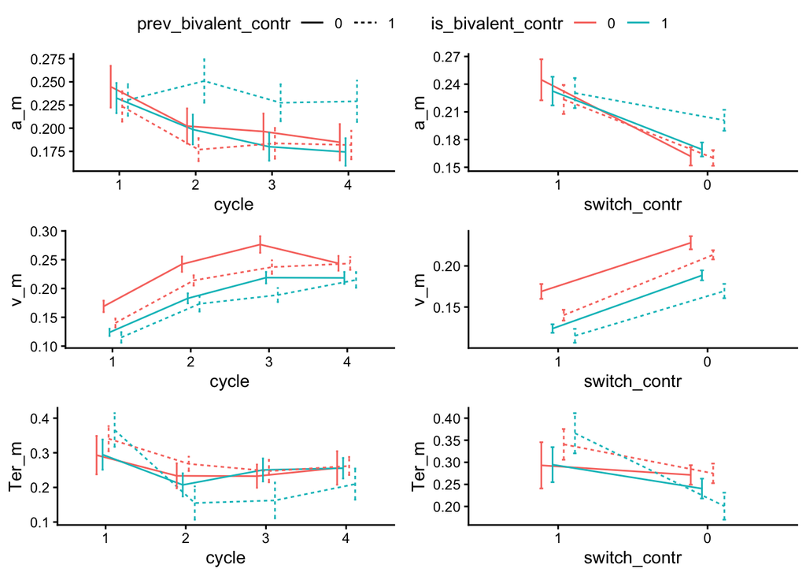

```r
plt_ddm_a <- ggplot(alt_run_agg_ddm, aes(x = cycle, y = a_m, color = is_bivalent_contr, linetype = prev_bivalent_contr, group = interaction(is_bivalent_contr, prev_bivalent_contr)))+
  geom_line(position = pos)+
  geom_errorbar(aes(ymin = a_ci_lower, ymax = a_ci_upper), width = 0.1, position = pos)+
  theme_classic()

plt_ddm_v <- ggplot(alt_run_agg_ddm, aes(x = cycle, y = v_m, color = is_bivalent_contr, linetype = prev_bivalent_contr, group = interaction(is_bivalent_contr, prev_bivalent_contr)))+
  geom_line(position = pos)+
  geom_errorbar(aes(ymin = v_ci_lower, ymax = v_ci_upper), width = 0.1, position = pos)+
  theme_classic()


plt_ddm_Ter <- ggplot(alt_run_agg_ddm, aes(x = cycle, y = Ter_m, color = is_bivalent_contr, linetype = prev_bivalent_contr, group = interaction(is_bivalent_contr, prev_bivalent_contr)))+
  geom_line(position = pos)+
  geom_errorbar(aes(ymin = Ter_ci_lower, ymax = Ter_ci_upper), width = 0.1, position = pos)+
  theme_classic()

#########
plt_ddm_a_nocycle <- ggplot(alt_run_agg_ddm_nocycle, aes(x = switch_contr, y = a_m, color = is_bivalent_contr, linetype = prev_bivalent_contr, group = interaction(is_bivalent_contr, prev_bivalent_contr)))+
  geom_line(position = pos)+
  geom_errorbar(aes(ymin = a_ci_lower, ymax = a_ci_upper), width = 0.1, position = pos)+
  scale_x_discrete(limits = c("1", "0"))+
  theme_classic()

plt_ddm_v_nocycle <- ggplot(alt_run_agg_ddm_nocycle, aes(x = switch_contr, y = v_m, color = is_bivalent_contr, linetype = prev_bivalent_contr, group = interaction(is_bivalent_contr, prev_bivalent_contr)))+
  geom_line(position = pos)+
  geom_errorbar(aes(ymin = v_ci_lower, ymax = v_ci_upper), width = 0.1, position = pos)+
  scale_x_discrete(limits = c("1", "0"))+
  theme_classic()


plt_ddm_Ter_nocycle <- ggplot(alt_run_agg_ddm_nocycle, aes(x = switch_contr, y = Ter_m, color = is_bivalent_contr, linetype = prev_bivalent_contr, group = interaction(is_bivalent_contr, prev_bivalent_contr)))+
  geom_line(position = pos)+
  geom_errorbar(aes(ymin = Ter_ci_lower, ymax = Ter_ci_upper), width = 0.1, position = pos)+
  scale_x_discrete(limits = c("1", "0"))+
  theme_classic()

ggpubr::ggarrange(plt_ddm_a, plt_ddm_a_nocycle,
                  plt_ddm_v, plt_ddm_v_nocycle,
                  plt_ddm_Ter, plt_ddm_Ter_nocycle, common.legend = TRUE, nrow = 3, ncol = 2)
```

#### 6.2.2.1 Publication Figures

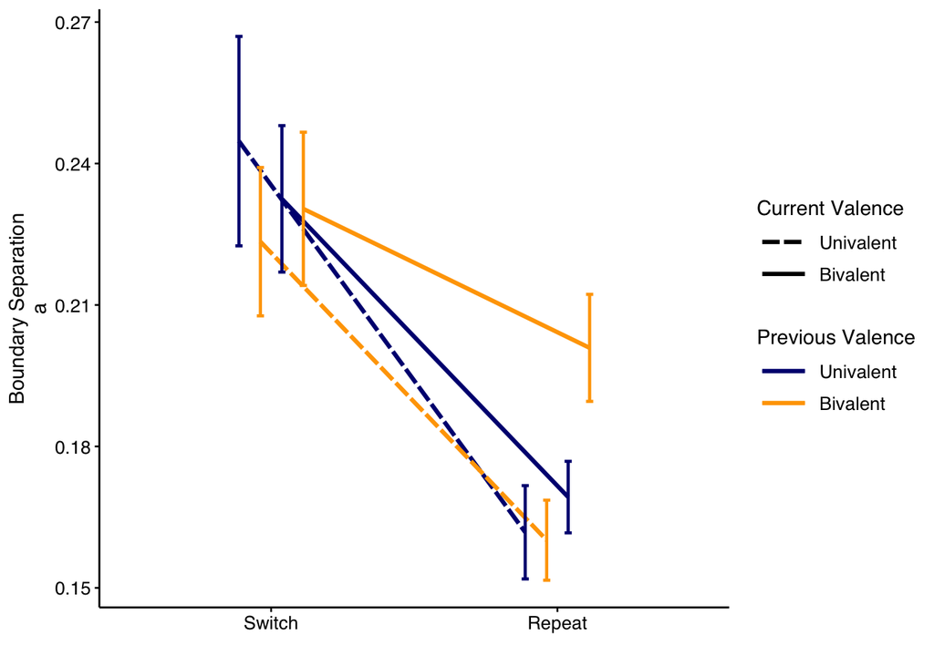

```r
pos = position_dodge(0.3)
plt_ddm_a_nocycle <- ggplot(alt_run_agg_ddm_nocycle, aes(x = switch_contr, y = a_m, color =  prev_bivalent_contr, linetype =is_bivalent_contr, group = interaction(prev_bivalent_contr, is_bivalent_contr)))+
  geom_line(position = pos, linewidth = design$lines$linewidth)+
  geom_errorbar(aes(ymin = a_ci_lower, ymax = a_ci_upper),
                width = design$errorbar$width,
                position = pos,
                linewidth = design$errorbar$linewidth,
                linetype = "solid")+
  scale_color_manual(name = "Previous Valence",
                     labels = c("0" = "Univalent",
                                "1" = "Bivalent"),
                     values = c("0" = design$curr_val$color$uni,
                                "1" = design$curr_val$color$bi))+
  scale_linetype_manual(name = "Current Valence",
                        labels = c("0" = "Univalent",
                                   "1" = "Bivalent"),
                        values = c("0" = design$prev_val$linetype$uni,
                                   "1" = design$prev_val$linetype$bi))+
  scale_x_discrete(limits = c("1", "0"), labels = c("1" = "Switch", "0" = "Repeat"))+
  labs(x = "",
       y = "Boundary Separation\na") +
  guides(
    linetype = guide_legend(order = 1),  # appears first
    color    = guide_legend(order = 2)   # appears second
  )

plt_ddm_a_nocycle
```

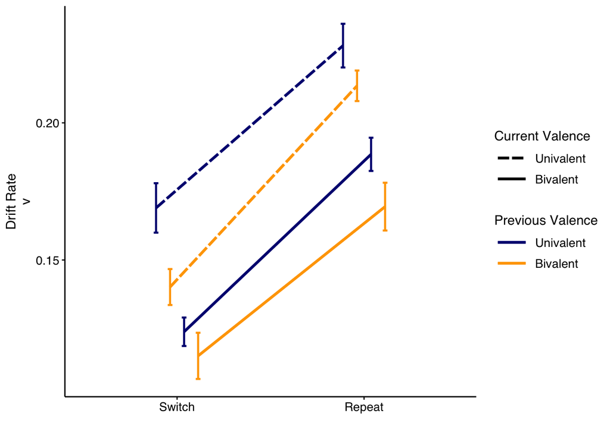

```r
plt_ddm_v_nocycle <- ggplot(alt_run_agg_ddm_nocycle, aes(x = switch_contr, y = v_m, color = prev_bivalent_contr, linetype = is_bivalent_contr, group = interaction(prev_bivalent_contr, is_bivalent_contr)))+
  geom_line(position = pos, linewidth = design$lines$linewidth)+
  geom_errorbar(aes(ymin = v_ci_lower, ymax = v_ci_upper),
                width = design$errorbar$width,
                position = pos,
                linewidth = design$errorbar$linewidth,
                linetype = "solid")+
  scale_color_manual(name = "Previous Valence",
                     labels = c("0" = "Univalent",
                                "1" = "Bivalent"),
                     values = c("0" = design$curr_val$color$uni,
                                "1" = design$curr_val$color$bi))+
  scale_linetype_manual(name = "Current Valence",
                        labels = c("0" = "Univalent",
                                   "1" = "Bivalent"),
                        values = c("0" = design$curr_val$linetype$uni,
                                   "1" = design$curr_val$linetype$bi))+
  scale_x_discrete(limits = c("1", "0"), labels = c("1" = "Switch", "0" = "Repeat"))+
  labs(x = "",
       y = "Drift Rate\nv") +
  guides(
    linetype = guide_legend(order = 1),  # appears first
    color    = guide_legend(order = 2)   # appears second
  )
plt_ddm_v_nocycle
```

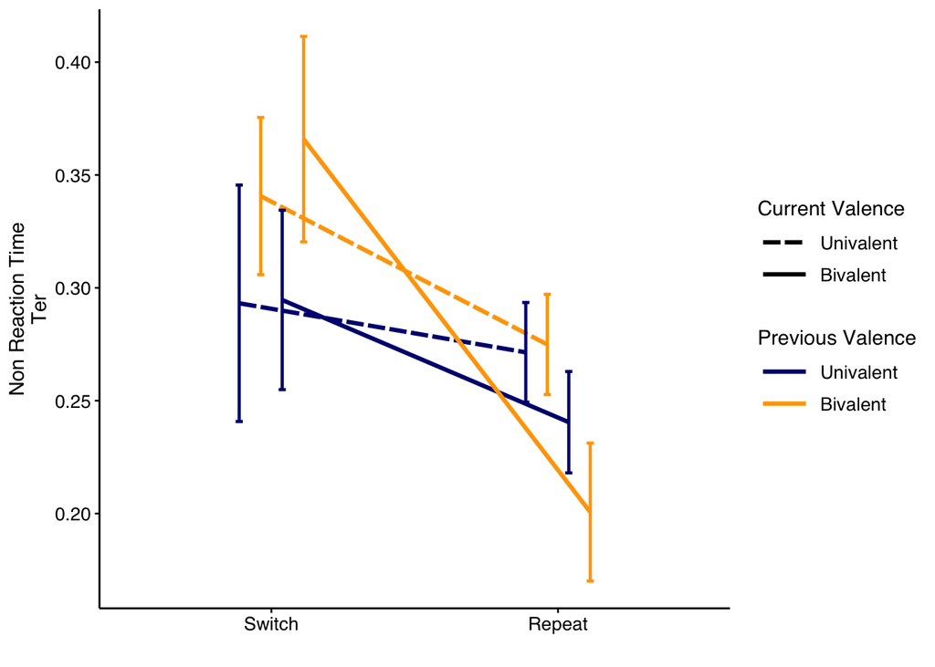

```r
plt_ddm_Ter_nocycle <- ggplot(alt_run_agg_ddm_nocycle, aes(x = switch_contr, y = Ter_m, color = prev_bivalent_contr, linetype = is_bivalent_contr, group = interaction(prev_bivalent_contr, is_bivalent_contr)))+
  geom_line(position = pos, linewidth = design$lines$linewidth)+
  geom_errorbar(aes(ymin = Ter_ci_lower, ymax = Ter_ci_upper),
                width = design$errorbar$width,
                position = pos,
                linewidth = design$errorbar$linewidth,
                linetype = "solid")+
  scale_color_manual(name = "Previous Valence",
                     labels = c("0" = "Univalent",
                                "1" = "Bivalent"),
                     values = c("0" = design$curr_val$color$uni,
                                "1" = design$curr_val$color$bi))+
  scale_linetype_manual(name = "Current Valence",
                        labels = c("0" = "Univalent",
                                   "1" = "Bivalent"),
                        values = c("0" = design$curr_val$linetype$uni,
                                   "1" = design$curr_val$linetype$bi))+
  scale_x_discrete(limits = c("1", "0"), labels = c("1" = "Switch", "0" = "Repeat")) +
  labs(x = "",
       y = "Non Reaction Time\nTer")+
  guides(
    linetype = guide_legend(order = 1),  # appears first
    color    = guide_legend(order = 2)   # appears second
  )


plt_ddm_Ter_nocycle
```

```r
ggsave(plot = plt_ddm_Ter_nocycle, filename = "figures/AR_ddm_TER.svg", width = 5, height = 5, units = "in")
ggsave(plot = plt_ddm_v_nocycle, filename = "figures/AR_ddm_v.svg", width = 5, height = 5, units = "in")
ggsave(plot = plt_ddm_a_nocycle, filename = "figures/AR_ddm_a.svg", width = 5, height = 5, units = "in")

saveRDS(plt_ddm_Ter_nocycle,"figures/AR_ddm_TER.RDS")
saveRDS(plt_ddm_v_nocycle, "figures/AR_ddm_v.RDS")
saveRDS(plt_ddm_a_nocycle, "figures/AR_ddm_a.RDS")
```

### 6.2.3 Models

#### 6.2.3.1 Effect coded valence (-0.5, 0.5)

##### 6.2.3.1.1 a

Only model that converges and is not singular is the intercept model.

```r
alt_run_a_eff <- lmer(a ~ is_bivalent_eff * prev_bivalent_eff * switch_contr + (prev_bivalent_eff + is_bivalent_eff + switch_contr|id),
                      control = lmerControl(optimizer = "bobyqa"),
                      alt_run_agg_ID_ddm_nocycle)
```

```
## boundary (singular) fit: see help('isSingular')
```

```r
#summary(alt_run_a)
make_model_table(alt_run_a_eff)
```

| Call: lmer(formula = a ~ is_bivalent_eff * prev_bivalent_eff * switch_contr + (prev_bivalent_eff + is_bivalent_eff + switch_contr \| id), data = alt_run_agg_ID_ddm_nocycle, control = lmerControl(optim… term | Call: lmer(formula = a ~ is_bivalent_eff * prev_bivalent_eff * switch_contr + (prev_bivalent_eff + is_bivalent_eff + switch_contr \| id), data = alt_run_agg_ID_ddm_nocycle, control = lmerControl(optim… Estimate | Call: lmer(formula = a ~ is_bivalent_eff * prev_bivalent_eff * switch_contr + (prev_bivalent_eff + is_bivalent_eff + switch_contr \| id), data = alt_run_agg_ID_ddm_nocycle, control = lmerControl(optim… Std. Error | Call: lmer(formula = a ~ is_bivalent_eff * prev_bivalent_eff * switch_contr + (prev_bivalent_eff + is_bivalent_eff + switch_contr \| id), data = alt_run_agg_ID_ddm_nocycle, control = lmerControl(optim… df | Call: lmer(formula = a ~ is_bivalent_eff * prev_bivalent_eff * switch_contr + (prev_bivalent_eff + is_bivalent_eff + switch_contr \| id), data = alt_run_agg_ID_ddm_nocycle, control = lmerControl(optim… t value | Call: lmer(formula = a ~ is_bivalent_eff * prev_bivalent_eff * switch_contr + (prev_bivalent_eff + is_bivalent_eff + switch_contr \| id), data = alt_run_agg_ID_ddm_nocycle, control = lmerControl(optim… Pr(>\|t\|) |
| --- | --- | --- | --- | --- | --- |
| (Intercept) | 0.17 | 0.01 | 106.24 | 30.62 | 0.0000 |
| is_bivalent_eff1 | 0.02 | 0.01 | 351.44 | 3.20 | 0.0015 |
| prev_bivalent_eff1 | 0.01 | 0.01 | 432.65 | 1.99 | 0.0470 |
| switch_contr1 | 0.06 | 0.01 | 160.40 | 9.89 | 0.0000 |
| is_bivalent_eff1:prev_bivalent_eff1 | 0.03 | 0.01 | 570.00 | 2.29 | 0.0222 |
| is_bivalent_eff1:switch_contr1 | -0.03 | 0.01 | 570.00 | -2.61 | 0.0094 |
| prev_bivalent_eff1:switch_contr1 | -0.03 | 0.01 | 570.00 | -2.60 | 0.0096 |
| is_bivalent_eff1:prev_bivalent_eff1:switch_contr1 | -0.01 | 0.02 | 570.00 | -0.69 | 0.4923 |

This model is singular. Only the intercept only model is not singular.

```r
#BASELINE MODEL

alt_run_a_eff_baseline <- lmer(a ~ is_bivalent_eff * prev_bivalent_eff * switch_contr + (1|id),
                               control = lmerControl(optimizer = "bobyqa"),
                               alt_run_agg_ID_ddm_nocycle)


# MODELS WITH 1RE
alt_run_a_eff_prev_bivalent <- lmer(a ~ is_bivalent_eff * prev_bivalent_eff * switch_contr + (prev_bivalent_eff|id),
                                    control = lmerControl(optimizer = "bobyqa"),
                                    alt_run_agg_ID_ddm_nocycle)
```

```
## boundary (singular) fit: see help('isSingular')
```

```r
alt_run_a_eff_is_bivalent <- lmer(a ~ is_bivalent_eff * prev_bivalent_eff * switch_contr + (is_bivalent_eff|id),
                                  control = lmerControl(optimizer = "bobyqa"),
                                  alt_run_agg_ID_ddm_nocycle)
```

```
## boundary (singular) fit: see help('isSingular')
```

```r
alt_run_a_eff_switch <- lmer(a ~ is_bivalent_eff * prev_bivalent_eff * switch_contr + (switch_contr|id),
                             control = lmerControl(optimizer = "bobyqa"),
                             alt_run_agg_ID_ddm_nocycle)
```

```
## boundary (singular) fit: see help('isSingular')
```

```r
# MODELS WITH 2 RE

alt_run_a_eff_switch_prev_bivalent <- lmer(a ~ is_bivalent_eff * prev_bivalent_eff * switch_contr + (switch_contr + prev_bivalent_eff|id),
                                    control = lmerControl(optimizer = "bobyqa"),
                                    alt_run_agg_ID_ddm_nocycle)
```

```
## boundary (singular) fit: see help('isSingular')
```

```r
alt_run_a_eff_switch_is_bivalent <- lmer(a ~ is_bivalent_eff * prev_bivalent_eff * switch_contr + (switch_contr + is_bivalent_eff|id),
                                  control = lmerControl(optimizer = "bobyqa"),
                                  alt_run_agg_ID_ddm_nocycle)
```

```
## boundary (singular) fit: see help('isSingular')
```

```r
alt_run_a_eff_is_bivalent_prev_bivalent <- lmer(a ~ is_bivalent_eff * prev_bivalent_eff * switch_contr + (prev_bivalent_eff + is_bivalent_eff|id),
                             control = lmerControl(optimizer = "bobyqa"),
                             alt_run_agg_ID_ddm_nocycle)
```

```
## boundary (singular) fit: see help('isSingular')
```

Final model:

```r
#final model
alt_run_a_eff_final <- alt_run_a_eff_baseline
make_model_table(alt_run_a_eff_final)
```

| Call: lmer(formula = a ~ is_bivalent_eff * prev_bivalent_eff * switch_contr + (1 \| id), data = alt_run_agg_ID_ddm_nocycle, control = lmerControl(optimizer = "bobyqa")) Convergence: OK \| Singular fit… term | Call: lmer(formula = a ~ is_bivalent_eff * prev_bivalent_eff * switch_contr + (1 \| id), data = alt_run_agg_ID_ddm_nocycle, control = lmerControl(optimizer = "bobyqa")) Convergence: OK \| Singular fit… Estimate | Call: lmer(formula = a ~ is_bivalent_eff * prev_bivalent_eff * switch_contr + (1 \| id), data = alt_run_agg_ID_ddm_nocycle, control = lmerControl(optimizer = "bobyqa")) Convergence: OK \| Singular fit… Std. Error | Call: lmer(formula = a ~ is_bivalent_eff * prev_bivalent_eff * switch_contr + (1 \| id), data = alt_run_agg_ID_ddm_nocycle, control = lmerControl(optimizer = "bobyqa")) Convergence: OK \| Singular fit… df | Call: lmer(formula = a ~ is_bivalent_eff * prev_bivalent_eff * switch_contr + (1 \| id), data = alt_run_agg_ID_ddm_nocycle, control = lmerControl(optimizer = "bobyqa")) Convergence: OK \| Singular fit… t value | Call: lmer(formula = a ~ is_bivalent_eff * prev_bivalent_eff * switch_contr + (1 \| id), data = alt_run_agg_ID_ddm_nocycle, control = lmerControl(optimizer = "bobyqa")) Convergence: OK \| Singular fit… Pr(>\|t\|) |
| --- | --- | --- | --- | --- | --- |
| (Intercept) | 0.17 | 0.01 | 130.87 | 24.86 | 0.0000 |
| is_bivalent_eff1 | 0.02 | 0.01 | 665.00 | 3.17 | 0.0016 |
| prev_bivalent_eff1 | 0.01 | 0.01 | 665.00 | 1.97 | 0.0497 |
| switch_contr1 | 0.06 | 0.01 | 665.00 | 11.09 | 0.0000 |
| is_bivalent_eff1:prev_bivalent_eff1 | 0.03 | 0.02 | 665.00 | 2.19 | 0.0291 |
| is_bivalent_eff1:switch_contr1 | -0.03 | 0.01 | 665.00 | -2.48 | 0.0133 |
| prev_bivalent_eff1:switch_contr1 | -0.03 | 0.01 | 665.00 | -2.48 | 0.0135 |
| is_bivalent_eff1:prev_bivalent_eff1:switch_contr1 | -0.01 | 0.02 | 665.00 | -0.65 | 0.5127 |

##### 6.2.3.1.2 v

```r
alt_run_v_eff <- lmer(v ~ is_bivalent_eff * prev_bivalent_eff * switch_contr + (prev_bivalent_eff + is_bivalent_eff + switch_contr|id),
                      control = lmerControl(optimizer = "bobyqa"),
                      alt_run_agg_ID_ddm_nocycle)
```

```
## boundary (singular) fit: see help('isSingular')
```

```r
#summary(alt_run_v)
make_model_table(alt_run_v_eff)
```

| Call: lmer(formula = v ~ is_bivalent_eff * prev_bivalent_eff * switch_contr + (prev_bivalent_eff + is_bivalent_eff + switch_contr \| id), data = alt_run_agg_ID_ddm_nocycle, control = lmerControl(optim… term | Call: lmer(formula = v ~ is_bivalent_eff * prev_bivalent_eff * switch_contr + (prev_bivalent_eff + is_bivalent_eff + switch_contr \| id), data = alt_run_agg_ID_ddm_nocycle, control = lmerControl(optim… Estimate | Call: lmer(formula = v ~ is_bivalent_eff * prev_bivalent_eff * switch_contr + (prev_bivalent_eff + is_bivalent_eff + switch_contr \| id), data = alt_run_agg_ID_ddm_nocycle, control = lmerControl(optim… Std. Error | Call: lmer(formula = v ~ is_bivalent_eff * prev_bivalent_eff * switch_contr + (prev_bivalent_eff + is_bivalent_eff + switch_contr \| id), data = alt_run_agg_ID_ddm_nocycle, control = lmerControl(optim… df | Call: lmer(formula = v ~ is_bivalent_eff * prev_bivalent_eff * switch_contr + (prev_bivalent_eff + is_bivalent_eff + switch_contr \| id), data = alt_run_agg_ID_ddm_nocycle, control = lmerControl(optim… t value | Call: lmer(formula = v ~ is_bivalent_eff * prev_bivalent_eff * switch_contr + (prev_bivalent_eff + is_bivalent_eff + switch_contr \| id), data = alt_run_agg_ID_ddm_nocycle, control = lmerControl(optim… Pr(>\|t\|) |
| --- | --- | --- | --- | --- | --- |
| (Intercept) | 0.20 | 0.01 | 95.00 | 37.93 | 0.0000 |
| is_bivalent_eff1 | -0.04 | 0.00 | 193.66 | -9.94 | 0.0000 |
| prev_bivalent_eff1 | -0.02 | 0.00 | 232.83 | -4.35 | 0.0000 |
| switch_contr1 | -0.06 | 0.00 | 95.14 | -18.93 | 0.0000 |
| is_bivalent_eff1:prev_bivalent_eff1 | -0.00 | 0.01 | 475.00 | -0.68 | 0.4989 |
| is_bivalent_eff1:switch_contr1 | 0.01 | 0.00 | 475.00 | 1.46 | 0.1463 |
| prev_bivalent_eff1:switch_contr1 | -0.00 | 0.00 | 475.00 | -0.42 | 0.6715 |
| is_bivalent_eff1:prev_bivalent_eff1:switch_contr1 | 0.02 | 0.01 | 475.00 | 2.65 | 0.0083 |

This model is singular. Let’s check which random effects we can add.

```r
# BASELINE MODEL
alt_run_v_eff_baseline <- lmer(v ~ is_bivalent_eff * prev_bivalent_eff * switch_contr + (1|id),
                               control = lmerControl(optimizer = "bobyqa"),
                               alt_run_agg_ID_ddm_nocycle)


#MODELS WITH 1 RE
alt_run_v_eff_prev_bivalent <- lmer(v ~ is_bivalent_eff * prev_bivalent_eff * switch_contr + (prev_bivalent_eff|id),
                                    control = lmerControl(optimizer = "bobyqa"),
                                    alt_run_agg_ID_ddm_nocycle)


alt_run_v_eff_is_bivalent <- lmer(v ~ is_bivalent_eff * prev_bivalent_eff * switch_contr + (is_bivalent_eff|id),
                                  control = lmerControl(optimizer = "bobyqa"),
                                  alt_run_agg_ID_ddm_nocycle)

alt_run_v_eff_switch <- lmer(v ~ is_bivalent_eff * prev_bivalent_eff * switch_contr + (switch_contr|id),
                             control = lmerControl(optimizer = "bobyqa"),
                             alt_run_agg_ID_ddm_nocycle)

# MODELS WITH 2 RE

alt_run_v_eff_switch_prev_bivalent <- lmer(v ~ is_bivalent_eff * prev_bivalent_eff * switch_contr + (switch_contr + prev_bivalent_eff|id),
                                    control = lmerControl(optimizer = "bobyqa"),
                                    alt_run_agg_ID_ddm_nocycle)


alt_run_v_eff_switch_is_bivalent <- lmer(v ~ is_bivalent_eff * prev_bivalent_eff * switch_contr + (switch_contr + is_bivalent_eff|id),
                                  control = lmerControl(optimizer = "bobyqa"),
                                  alt_run_agg_ID_ddm_nocycle)

alt_run_v_eff_prev_bivalent_is_bivalent <- lmer(v ~ is_bivalent_eff * prev_bivalent_eff * switch_contr + (prev_bivalent_eff + is_bivalent_eff|id),
                             control = lmerControl(optimizer = "bobyqa"),
                             alt_run_agg_ID_ddm_nocycle)
```

```
## boundary (singular) fit: see help('isSingular')
```

```r
AIC(alt_run_v_eff_switch_prev_bivalent, alt_run_v_eff_switch_is_bivalent)
```

```
##                                    df       AIC
## alt_run_v_eff_switch_prev_bivalent 15 -2502.852
## alt_run_v_eff_switch_is_bivalent   15 -2524.602
```

```r
BIC(alt_run_v_eff_switch_prev_bivalent, alt_run_v_eff_switch_is_bivalent)
```

```
##                                    df       BIC
## alt_run_v_eff_switch_prev_bivalent 15 -2433.195
## alt_run_v_eff_switch_is_bivalent   15 -2454.945
```

Final model:

```r
alt_run_v_eff_final <- alt_run_v_eff_switch_is_bivalent

make_model_table(alt_run_v_eff_final)
```

| Call: lmer(formula = v ~ is_bivalent_eff * prev_bivalent_eff * switch_contr + (switch_contr + is_bivalent_eff \| id), data = alt_run_agg_ID_ddm_nocycle, control = lmerControl(optimizer = "bobyqa")) Co… term | Call: lmer(formula = v ~ is_bivalent_eff * prev_bivalent_eff * switch_contr + (switch_contr + is_bivalent_eff \| id), data = alt_run_agg_ID_ddm_nocycle, control = lmerControl(optimizer = "bobyqa")) Co… Estimate | Call: lmer(formula = v ~ is_bivalent_eff * prev_bivalent_eff * switch_contr + (switch_contr + is_bivalent_eff \| id), data = alt_run_agg_ID_ddm_nocycle, control = lmerControl(optimizer = "bobyqa")) Co… Std. Error | Call: lmer(formula = v ~ is_bivalent_eff * prev_bivalent_eff * switch_contr + (switch_contr + is_bivalent_eff \| id), data = alt_run_agg_ID_ddm_nocycle, control = lmerControl(optimizer = "bobyqa")) Co… df | Call: lmer(formula = v ~ is_bivalent_eff * prev_bivalent_eff * switch_contr + (switch_contr + is_bivalent_eff \| id), data = alt_run_agg_ID_ddm_nocycle, control = lmerControl(optimizer = "bobyqa")) Co… t value | Call: lmer(formula = v ~ is_bivalent_eff * prev_bivalent_eff * switch_contr + (switch_contr + is_bivalent_eff \| id), data = alt_run_agg_ID_ddm_nocycle, control = lmerControl(optimizer = "bobyqa")) Co… Pr(>\|t\|) |
| --- | --- | --- | --- | --- | --- |
| (Intercept) | 0.20 | 0.01 | 95.00 | 37.93 | 0.0000 |
| is_bivalent_eff1 | -0.04 | 0.00 | 214.13 | -9.86 | 0.0000 |
| prev_bivalent_eff1 | -0.02 | 0.00 | 475.00 | -4.73 | 0.0000 |
| switch_contr1 | -0.06 | 0.00 | 95.00 | -18.94 | 0.0000 |
| is_bivalent_eff1:prev_bivalent_eff1 | -0.00 | 0.01 | 475.00 | -0.62 | 0.5356 |
| is_bivalent_eff1:switch_contr1 | 0.01 | 0.01 | 475.00 | 1.33 | 0.1832 |
| prev_bivalent_eff1:switch_contr1 | -0.00 | 0.01 | 475.00 | -0.39 | 0.6977 |
| is_bivalent_eff1:prev_bivalent_eff1:switch_contr1 | 0.02 | 0.01 | 475.00 | 2.43 | 0.0156 |

The baseline model and the two competing 2 RE models show the same significance and direction of effects.

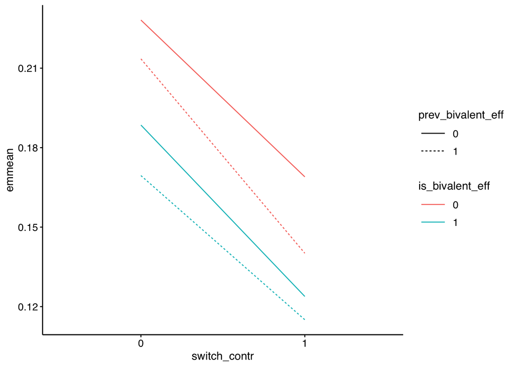

```r
emmeans::emmeans(alt_run_v_eff_final, ~ is_bivalent_eff * prev_bivalent_eff * switch_contr) %>%
  as.data.frame() %>%
  ggplot(aes(x = switch_contr, y = emmean, color = is_bivalent_eff, linetype = prev_bivalent_eff,
             group = interaction(is_bivalent_eff, prev_bivalent_eff)))+
  geom_line()
```

##### 6.2.3.1.3 Ter

```r
alt_run_Ter_eff <- lmer(Ter ~ is_bivalent_eff * prev_bivalent_eff * switch_contr + (prev_bivalent_eff + is_bivalent_eff + switch_contr|id),
                        control = lmerControl(optimizer = "bobyqa"),
                        alt_run_agg_ID_ddm_nocycle)
```

```
## boundary (singular) fit: see help('isSingular')
```

```r
#summary(alt_run_a)
make_model_table(alt_run_Ter_eff)
```

| Call: lmer(formula = Ter ~ is_bivalent_eff * prev_bivalent_eff * switch_contr + (prev_bivalent_eff + is_bivalent_eff + switch_contr \| id), data = alt_run_agg_ID_ddm_nocycle, control = lmerControl(opt… term | Call: lmer(formula = Ter ~ is_bivalent_eff * prev_bivalent_eff * switch_contr + (prev_bivalent_eff + is_bivalent_eff + switch_contr \| id), data = alt_run_agg_ID_ddm_nocycle, control = lmerControl(opt… Estimate | Call: lmer(formula = Ter ~ is_bivalent_eff * prev_bivalent_eff * switch_contr + (prev_bivalent_eff + is_bivalent_eff + switch_contr \| id), data = alt_run_agg_ID_ddm_nocycle, control = lmerControl(opt… Std. Error | Call: lmer(formula = Ter ~ is_bivalent_eff * prev_bivalent_eff * switch_contr + (prev_bivalent_eff + is_bivalent_eff + switch_contr \| id), data = alt_run_agg_ID_ddm_nocycle, control = lmerControl(opt… df | Call: lmer(formula = Ter ~ is_bivalent_eff * prev_bivalent_eff * switch_contr + (prev_bivalent_eff + is_bivalent_eff + switch_contr \| id), data = alt_run_agg_ID_ddm_nocycle, control = lmerControl(opt… t value | Call: lmer(formula = Ter ~ is_bivalent_eff * prev_bivalent_eff * switch_contr + (prev_bivalent_eff + is_bivalent_eff + switch_contr \| id), data = alt_run_agg_ID_ddm_nocycle, control = lmerControl(opt… Pr(>\|t\|) |
| --- | --- | --- | --- | --- | --- |
| (Intercept) | 0.25 | 0.01 | 126.64 | 21.74 | 0.0000 |
| is_bivalent_eff1 | -0.05 | 0.02 | 378.29 | -2.85 | 0.0045 |
| prev_bivalent_eff1 | -0.02 | 0.02 | 352.21 | -0.95 | 0.3404 |
| switch_contr1 | 0.08 | 0.02 | 131.84 | 4.87 | 0.0000 |
| is_bivalent_eff1:prev_bivalent_eff1 | -0.04 | 0.04 | 570.00 | -1.22 | 0.2235 |
| is_bivalent_eff1:switch_contr1 | 0.07 | 0.03 | 570.00 | 2.62 | 0.0089 |
| prev_bivalent_eff1:switch_contr1 | 0.08 | 0.03 | 570.00 | 3.08 | 0.0021 |
| is_bivalent_eff1:prev_bivalent_eff1:switch_contr1 | 0.07 | 0.05 | 570.00 | 1.33 | 0.1829 |

Ter model is singular. Adding slopes individually still results in singular models, so we stick with the intercept model.

```r
#BASELINE MODEL
alt_run_Ter_eff_baseline <- lmer(Ter ~ is_bivalent_eff * prev_bivalent_eff * switch_contr + (1|id),
                                 control = lmerControl(optimizer = "bobyqa"),
                                 alt_run_agg_ID_ddm_nocycle)
#MODELS WITH 1 RE

alt_run_Ter_eff_is_bivalent <- lmer(Ter ~ is_bivalent_eff * prev_bivalent_eff * switch_contr + (is_bivalent_eff|id),
                                    control = lmerControl(optimizer = "bobyqa"),
                                    alt_run_agg_ID_ddm_nocycle)
```

```
## boundary (singular) fit: see help('isSingular')
```

```r
alt_run_Ter_eff_switch <- lmer(Ter ~ is_bivalent_eff * prev_bivalent_eff * switch_contr + (switch_contr|id),
                                    control = lmerControl(optimizer = "bobyqa"),
                                    alt_run_agg_ID_ddm_nocycle)
```

```
## boundary (singular) fit: see help('isSingular')
```

```r
alt_run_Ter_eff_prev_bivalent <- lmer(Ter ~ is_bivalent_eff * prev_bivalent_eff * switch_contr + (prev_bivalent_eff|id),
                                    control = lmerControl(optimizer = "bobyqa"),
                                    alt_run_agg_ID_ddm_nocycle)
```

```
## boundary (singular) fit: see help('isSingular')
```

```r
#MODELS WITH 2RE


alt_run_Ter_eff_switch_is_bivalent <- lmer(Ter ~ is_bivalent_eff * prev_bivalent_eff * switch_contr + (switch_contr + is_bivalent_eff|id),
                                    control = lmerControl(optimizer = "bobyqa"),
                                    alt_run_agg_ID_ddm_nocycle)
```

```
## boundary (singular) fit: see help('isSingular')
```

```r
alt_run_Ter_eff_switch_prev_bivalent <- lmer(Ter ~ is_bivalent_eff * prev_bivalent_eff * switch_contr + (switch_contr + prev_bivalent_eff|id),
                                    control = lmerControl(optimizer = "bobyqa"),
                                    alt_run_agg_ID_ddm_nocycle)
```

```
## boundary (singular) fit: see help('isSingular')
```

```r
alt_run_Ter_eff_prev_bivalent_is_bivalent <- lmer(Ter ~ is_bivalent_eff * prev_bivalent_eff * switch_contr + (prev_bivalent_eff + is_bivalent_eff|id),
                                    control = lmerControl(optimizer = "bobyqa"),
                                    alt_run_agg_ID_ddm_nocycle)
```

```
## boundary (singular) fit: see help('isSingular')
```

Final model:

```r
alt_run_Ter_eff_final <- alt_run_Ter_eff_baseline

make_model_table(alt_run_Ter_eff_baseline)
```

| Call: lmer(formula = Ter ~ is_bivalent_eff * prev_bivalent_eff * switch_contr + (1 \| id), data = alt_run_agg_ID_ddm_nocycle, control = lmerControl(optimizer = "bobyqa")) Convergence: OK \| Singular f… term | Call: lmer(formula = Ter ~ is_bivalent_eff * prev_bivalent_eff * switch_contr + (1 \| id), data = alt_run_agg_ID_ddm_nocycle, control = lmerControl(optimizer = "bobyqa")) Convergence: OK \| Singular f… Estimate | Call: lmer(formula = Ter ~ is_bivalent_eff * prev_bivalent_eff * switch_contr + (1 \| id), data = alt_run_agg_ID_ddm_nocycle, control = lmerControl(optimizer = "bobyqa")) Convergence: OK \| Singular f… Std. Error | Call: lmer(formula = Ter ~ is_bivalent_eff * prev_bivalent_eff * switch_contr + (1 \| id), data = alt_run_agg_ID_ddm_nocycle, control = lmerControl(optimizer = "bobyqa")) Convergence: OK \| Singular f… df | Call: lmer(formula = Ter ~ is_bivalent_eff * prev_bivalent_eff * switch_contr + (1 \| id), data = alt_run_agg_ID_ddm_nocycle, control = lmerControl(optimizer = "bobyqa")) Convergence: OK \| Singular f… t value | Call: lmer(formula = Ter ~ is_bivalent_eff * prev_bivalent_eff * switch_contr + (1 \| id), data = alt_run_agg_ID_ddm_nocycle, control = lmerControl(optimizer = "bobyqa")) Convergence: OK \| Singular f… Pr(>\|t\|) |
| --- | --- | --- | --- | --- | --- |
| (Intercept) | 0.25 | 0.01 | 148.43 | 16.53 | 0.0000 |
| is_bivalent_eff1 | -0.05 | 0.02 | 665.00 | -2.76 | 0.0059 |
| prev_bivalent_eff1 | -0.02 | 0.02 | 665.00 | -0.95 | 0.3407 |
| switch_contr1 | 0.08 | 0.01 | 665.00 | 5.69 | 0.0000 |
| is_bivalent_eff1:prev_bivalent_eff1 | -0.04 | 0.04 | 665.00 | -1.14 | 0.2563 |
| is_bivalent_eff1:switch_contr1 | 0.07 | 0.03 | 665.00 | 2.45 | 0.0147 |
| prev_bivalent_eff1:switch_contr1 | 0.08 | 0.03 | 665.00 | 2.88 | 0.0042 |
| is_bivalent_eff1:prev_bivalent_eff1:switch_contr1 | 0.07 | 0.05 | 665.00 | 1.24 | 0.2142 |

###### 6.2.3.1.3.1 individual differences

v

```r
alt_run_agg_ID_ddm_nocycle_id <- alt_run_agg_ID_ddm_nocycle %>%
  left_join(alt_run_indivdiff, by = c("id" = "Number")) %>%
  filter(!is.na(cog_score))


alt_run_v_eff_id <- lmer(v ~ is_bivalent_eff * prev_bivalent_eff * switch_contr * cog_score + (prev_bivalent_eff + is_bivalent_eff + switch_contr|id),
                      control = lmerControl(optimizer = "bobyqa"),
                      alt_run_agg_ID_ddm_nocycle_id)
```

```
## boundary (singular) fit: see help('isSingular')
```

```r
#summary(alt_run_v)
make_model_table(alt_run_v_eff_id)
```

| Call: lmer(formula = v ~ is_bivalent_eff * prev_bivalent_eff * switch_contr * cog_score + (prev_bivalent_eff + is_bivalent_eff + switch_contr \| id), data = alt_run_agg_ID_ddm_nocycle_id, control = lm… term | Call: lmer(formula = v ~ is_bivalent_eff * prev_bivalent_eff * switch_contr * cog_score + (prev_bivalent_eff + is_bivalent_eff + switch_contr \| id), data = alt_run_agg_ID_ddm_nocycle_id, control = lm… Estimate | Call: lmer(formula = v ~ is_bivalent_eff * prev_bivalent_eff * switch_contr * cog_score + (prev_bivalent_eff + is_bivalent_eff + switch_contr \| id), data = alt_run_agg_ID_ddm_nocycle_id, control = lm… Std. Error | Call: lmer(formula = v ~ is_bivalent_eff * prev_bivalent_eff * switch_contr * cog_score + (prev_bivalent_eff + is_bivalent_eff + switch_contr \| id), data = alt_run_agg_ID_ddm_nocycle_id, control = lm… df | Call: lmer(formula = v ~ is_bivalent_eff * prev_bivalent_eff * switch_contr * cog_score + (prev_bivalent_eff + is_bivalent_eff + switch_contr \| id), data = alt_run_agg_ID_ddm_nocycle_id, control = lm… t value | Call: lmer(formula = v ~ is_bivalent_eff * prev_bivalent_eff * switch_contr * cog_score + (prev_bivalent_eff + is_bivalent_eff + switch_contr \| id), data = alt_run_agg_ID_ddm_nocycle_id, control = lm… Pr(>\|t\|) |
| --- | --- | --- | --- | --- | --- |
| (Intercept) | 0.20 | 0.01 | 56.00 | 29.21 | 0.0000 |
| is_bivalent_eff1 | -0.04 | 0.01 | 120.25 | -7.73 | 0.0000 |
| prev_bivalent_eff1 | -0.02 | 0.01 | 140.33 | -3.28 | 0.0013 |
| switch_contr1 | -0.07 | 0.00 | 56.02 | -16.23 | 0.0000 |
| cog_score | 0.03 | 0.01 | 56.00 | 2.92 | 0.0050 |
| is_bivalent_eff1:prev_bivalent_eff1 | -0.01 | 0.01 | 280.00 | -0.89 | 0.3767 |
| is_bivalent_eff1:switch_contr1 | 0.01 | 0.01 | 280.00 | 1.80 | 0.0733 |
| prev_bivalent_eff1:switch_contr1 | -0.00 | 0.01 | 280.00 | -0.09 | 0.9265 |
| is_bivalent_eff1:cog_score | 0.00 | 0.01 | 120.25 | 0.41 | 0.6797 |
| prev_bivalent_eff1:cog_score | 0.00 | 0.01 | 140.33 | 0.04 | 0.9702 |
| switch_contr1:cog_score | -0.02 | 0.01 | 56.02 | -2.71 | 0.0088 |
| is_bivalent_eff1:prev_bivalent_eff1:switch_contr1 | 0.02 | 0.01 | 280.00 | 1.65 | 0.0997 |
| is_bivalent_eff1:prev_bivalent_eff1:cog_score | 0.00 | 0.01 | 280.00 | 0.37 | 0.7123 |
| is_bivalent_eff1:switch_contr1:cog_score | 0.00 | 0.01 | 280.00 | 0.06 | 0.9508 |
| prev_bivalent_eff1:switch_contr1:cog_score | 0.01 | 0.01 | 280.00 | 0.87 | 0.3828 |
| is_bivalent_eff1:prev_bivalent_eff1:switch_contr1:cog_score | 0.01 | 0.02 | 280.00 | 0.42 | 0.6757 |

#### 6.2.3.2 Contrast coded (0, 1)

##### 6.2.3.2.1 a

```r
alt_run_a_contr <- lmer(a ~ is_bivalent_contr * prev_bivalent_contr * switch_contr + (prev_bivalent_contr + is_bivalent_contr + switch_contr|id),
                        control = lmerControl(optimizer = "bobyqa"),
                        alt_run_agg_ID_ddm_nocycle)
```

```
## boundary (singular) fit: see help('isSingular')
```

```r
make_model_table(alt_run_a_contr)
```

| Call: lmer(formula = a ~ is_bivalent_contr * prev_bivalent_contr * switch_contr + (prev_bivalent_contr + is_bivalent_contr + switch_contr \| id), data = alt_run_agg_ID_ddm_nocycle, control = lmerContr… term | Call: lmer(formula = a ~ is_bivalent_contr * prev_bivalent_contr * switch_contr + (prev_bivalent_contr + is_bivalent_contr + switch_contr \| id), data = alt_run_agg_ID_ddm_nocycle, control = lmerContr… Estimate | Call: lmer(formula = a ~ is_bivalent_contr * prev_bivalent_contr * switch_contr + (prev_bivalent_contr + is_bivalent_contr + switch_contr \| id), data = alt_run_agg_ID_ddm_nocycle, control = lmerContr… Std. Error | Call: lmer(formula = a ~ is_bivalent_contr * prev_bivalent_contr * switch_contr + (prev_bivalent_contr + is_bivalent_contr + switch_contr \| id), data = alt_run_agg_ID_ddm_nocycle, control = lmerContr… df | Call: lmer(formula = a ~ is_bivalent_contr * prev_bivalent_contr * switch_contr + (prev_bivalent_contr + is_bivalent_contr + switch_contr \| id), data = alt_run_agg_ID_ddm_nocycle, control = lmerContr… t value | Call: lmer(formula = a ~ is_bivalent_contr * prev_bivalent_contr * switch_contr + (prev_bivalent_contr + is_bivalent_contr + switch_contr \| id), data = alt_run_agg_ID_ddm_nocycle, control = lmerContr… Pr(>\|t\|) |
| --- | --- | --- | --- | --- | --- |
| (Intercept) | 0.16 | 0.01 | 211.14 | 17.59 | 0.0000 |
| is_bivalent_contr1 | 0.01 | 0.01 | 585.87 | 0.71 | 0.4763 |
| prev_bivalent_contr1 | -0.00 | 0.01 | 577.38 | -0.16 | 0.8724 |
| switch_contr1 | 0.08 | 0.01 | 516.16 | 7.71 | 0.0000 |
| is_bivalent_contr1:prev_bivalent_contr1 | 0.03 | 0.01 | 570.00 | 2.29 | 0.0222 |
| is_bivalent_contr1:switch_contr1 | -0.02 | 0.01 | 570.00 | -1.36 | 0.1755 |
| prev_bivalent_contr1:switch_contr1 | -0.02 | 0.01 | 570.00 | -1.35 | 0.1769 |
| is_bivalent_contr1:prev_bivalent_contr1:switch_contr1 | -0.01 | 0.02 | 570.00 | -0.69 | 0.4923 |

Singular. Let’s test which random effects structure works. All of them are singular, so the intercept model wins.

```r
# BASELINE MODEL
alt_run_a_contr_baseline <- lmer(a ~ is_bivalent_contr * prev_bivalent_contr * switch_contr + (1|id),
                                 control = lmerControl(optimizer = "bobyqa"),
                                 alt_run_agg_ID_ddm_nocycle)

# MODELS WITH 1 RE
alt_run_a_contr_is_bivalent <- lmer(a ~ is_bivalent_contr * prev_bivalent_contr * switch_contr + (is_bivalent_contr|id),
                                    control = lmerControl(optimizer = "bobyqa"),
                                    alt_run_agg_ID_ddm_nocycle)
```

```
## boundary (singular) fit: see help('isSingular')
```

```r
alt_run_a_contr_prev_bivalent <- lmer(a ~ is_bivalent_contr * prev_bivalent_contr * switch_contr + (prev_bivalent_contr|id),
                                      control = lmerControl(optimizer = "bobyqa"),
                                      alt_run_agg_ID_ddm_nocycle)
```

```
## boundary (singular) fit: see help('isSingular')
```

```r
alt_run_a_contr_switch <- lmer(a ~ is_bivalent_contr * prev_bivalent_contr * switch_contr + (switch_contr|id),
                               control = lmerControl(optimizer = "bobyqa"),
                               alt_run_agg_ID_ddm_nocycle)
```

```
## boundary (singular) fit: see help('isSingular')
```

```r
# MODELS 2 RE
alt_run_a_contr_switch_is_bivalent <- lmer(a ~ is_bivalent_contr * prev_bivalent_contr * switch_contr + (switch_contr + is_bivalent_contr|id),
                                    control = lmerControl(optimizer = "bobyqa"),
                                    alt_run_agg_ID_ddm_nocycle)
```

```
## boundary (singular) fit: see help('isSingular')
```

```r
alt_run_a_contr_switch_prev_bivalent <- lmer(a ~ is_bivalent_contr * prev_bivalent_contr * switch_contr + (switch_contr + prev_bivalent_contr|id),
                                      control = lmerControl(optimizer = "bobyqa"),
                                      alt_run_agg_ID_ddm_nocycle)
```

```
## boundary (singular) fit: see help('isSingular')
```

```r
alt_run_a_contr_is_bivalent_prev_bivalent <- lmer(a ~ is_bivalent_contr * prev_bivalent_contr * switch_contr + (is_bivalent_contr + prev_bivalent_contr|id),
                               control = lmerControl(optimizer = "bobyqa"),
                               alt_run_agg_ID_ddm_nocycle)
```

```
## boundary (singular) fit: see help('isSingular')
```

Final model:

```r
alt_run_a_contr_final <- alt_run_a_contr_baseline
make_model_table(alt_run_a_contr_final)
```

| Call: lmer(formula = a ~ is_bivalent_contr * prev_bivalent_contr * switch_contr + (1 \| id), data = alt_run_agg_ID_ddm_nocycle, control = lmerControl(optimizer = "bobyqa")) Convergence: OK \| Singular… term | Call: lmer(formula = a ~ is_bivalent_contr * prev_bivalent_contr * switch_contr + (1 \| id), data = alt_run_agg_ID_ddm_nocycle, control = lmerControl(optimizer = "bobyqa")) Convergence: OK \| Singular… Estimate | Call: lmer(formula = a ~ is_bivalent_contr * prev_bivalent_contr * switch_contr + (1 \| id), data = alt_run_agg_ID_ddm_nocycle, control = lmerControl(optimizer = "bobyqa")) Convergence: OK \| Singular… Std. Error | Call: lmer(formula = a ~ is_bivalent_contr * prev_bivalent_contr * switch_contr + (1 \| id), data = alt_run_agg_ID_ddm_nocycle, control = lmerControl(optimizer = "bobyqa")) Convergence: OK \| Singular… df | Call: lmer(formula = a ~ is_bivalent_contr * prev_bivalent_contr * switch_contr + (1 \| id), data = alt_run_agg_ID_ddm_nocycle, control = lmerControl(optimizer = "bobyqa")) Convergence: OK \| Singular… t value | Call: lmer(formula = a ~ is_bivalent_contr * prev_bivalent_contr * switch_contr + (1 \| id), data = alt_run_agg_ID_ddm_nocycle, control = lmerControl(optimizer = "bobyqa")) Convergence: OK \| Singular… Pr(>\|t\|) |
| --- | --- | --- | --- | --- | --- |
| (Intercept) | 0.16 | 0.01 | 389.47 | 16.87 | 0.0000 |
| is_bivalent_contr1 | 0.01 | 0.01 | 665.00 | 0.69 | 0.4888 |
| prev_bivalent_contr1 | -0.00 | 0.01 | 665.00 | -0.16 | 0.8762 |
| switch_contr1 | 0.08 | 0.01 | 665.00 | 7.70 | 0.0000 |
| is_bivalent_contr1:prev_bivalent_contr1 | 0.03 | 0.02 | 665.00 | 2.19 | 0.0291 |
| is_bivalent_contr1:switch_contr1 | -0.02 | 0.02 | 665.00 | -1.29 | 0.1965 |
| prev_bivalent_contr1:switch_contr1 | -0.02 | 0.02 | 665.00 | -1.29 | 0.1979 |
| is_bivalent_contr1:prev_bivalent_contr1:switch_contr1 | -0.01 | 0.02 | 665.00 | -0.65 | 0.5127 |

##### 6.2.3.2.2 v

```r
alt_run_v_contr <- lmer(v ~ is_bivalent_contr * prev_bivalent_contr * switch_contr + (prev_bivalent_contr + is_bivalent_contr + switch_contr|id),
                        control = lmerControl(optimizer = "bobyqa"),
                        alt_run_agg_ID_ddm_nocycle)
```

```
## boundary (singular) fit: see help('isSingular')
```

```r
make_model_table(alt_run_v_contr)
```

| Call: lmer(formula = v ~ is_bivalent_contr * prev_bivalent_contr * switch_contr + (prev_bivalent_contr + is_bivalent_contr + switch_contr \| id), data = alt_run_agg_ID_ddm_nocycle, control = lmerContr… term | Call: lmer(formula = v ~ is_bivalent_contr * prev_bivalent_contr * switch_contr + (prev_bivalent_contr + is_bivalent_contr + switch_contr \| id), data = alt_run_agg_ID_ddm_nocycle, control = lmerContr… Estimate | Call: lmer(formula = v ~ is_bivalent_contr * prev_bivalent_contr * switch_contr + (prev_bivalent_contr + is_bivalent_contr + switch_contr \| id), data = alt_run_agg_ID_ddm_nocycle, control = lmerContr… Std. Error | Call: lmer(formula = v ~ is_bivalent_contr * prev_bivalent_contr * switch_contr + (prev_bivalent_contr + is_bivalent_contr + switch_contr \| id), data = alt_run_agg_ID_ddm_nocycle, control = lmerContr… df | Call: lmer(formula = v ~ is_bivalent_contr * prev_bivalent_contr * switch_contr + (prev_bivalent_contr + is_bivalent_contr + switch_contr \| id), data = alt_run_agg_ID_ddm_nocycle, control = lmerContr… t value | Call: lmer(formula = v ~ is_bivalent_contr * prev_bivalent_contr * switch_contr + (prev_bivalent_contr + is_bivalent_contr + switch_contr \| id), data = alt_run_agg_ID_ddm_nocycle, control = lmerContr… Pr(>\|t\|) |
| --- | --- | --- | --- | --- | --- |
| (Intercept) | 0.23 | 0.01 | 121.11 | 33.64 | 0.0000 |
| is_bivalent_contr1 | -0.04 | 0.01 | 366.28 | -7.44 | 0.0000 |
| prev_bivalent_contr1 | -0.01 | 0.01 | 415.73 | -2.89 | 0.0040 |
| switch_contr1 | -0.06 | 0.01 | 400.85 | -11.38 | 0.0000 |
| is_bivalent_contr1:prev_bivalent_contr1 | -0.00 | 0.01 | 475.00 | -0.68 | 0.4989 |
| is_bivalent_contr1:switch_contr1 | -0.01 | 0.01 | 475.00 | -0.84 | 0.3989 |
| prev_bivalent_contr1:switch_contr1 | -0.01 | 0.01 | 475.00 | -2.17 | 0.0302 |
| is_bivalent_contr1:prev_bivalent_contr1:switch_contr1 | 0.02 | 0.01 | 475.00 | 2.65 | 0.0083 |

Singular. Let’s simplify.

```r
# BASELINE MODEL
alt_run_v_contr_baseline <- lmer(v ~ is_bivalent_contr * prev_bivalent_contr * switch_contr + (1|id),
                                 control = lmerControl(optimizer = "bobyqa"),
                                 alt_run_agg_ID_ddm_nocycle)

# MODELS WITH 1 RE

alt_run_v_contr_is_bivalent <- lmer(v ~ is_bivalent_contr * prev_bivalent_contr * switch_contr + (is_bivalent_contr|id),
                                    control = lmerControl(optimizer = "bobyqa"),
                                    alt_run_agg_ID_ddm_nocycle)


alt_run_v_contr_prev_bivalent <- lmer(v ~ is_bivalent_contr * prev_bivalent_contr * switch_contr + (prev_bivalent_contr|id),
                                      control = lmerControl(optimizer = "bobyqa"),
                                      alt_run_agg_ID_ddm_nocycle)


alt_run_v_contr_switch <- lmer(v ~ is_bivalent_contr * prev_bivalent_contr * switch_contr + (switch_contr|id),
                               control = lmerControl(optimizer = "bobyqa"),
                               alt_run_agg_ID_ddm_nocycle)


# MODELS WITH 2 RE

alt_run_v_contr_switch_is_bivalent <- lmer(v ~ is_bivalent_contr * prev_bivalent_contr * switch_contr + (switch_contr + is_bivalent_contr|id),
                                    control = lmerControl(optimizer = "bobyqa"),
                                    alt_run_agg_ID_ddm_nocycle)


alt_run_v_contr_switch_prev_bivalent <- lmer(v ~ is_bivalent_contr * prev_bivalent_contr * switch_contr + (switch_contr + prev_bivalent_contr|id),
                                      control = lmerControl(optimizer = "bobyqa"),
                                      alt_run_agg_ID_ddm_nocycle)


alt_run_v_contr_is_bivalent_prev_bivalent <- lmer(v ~ is_bivalent_contr * prev_bivalent_contr * switch_contr + (is_bivalent_contr + prev_bivalent_contr|id),
                               control = lmerControl(optimizer = "bobyqa"),
                               alt_run_agg_ID_ddm_nocycle)
```

```
## boundary (singular) fit: see help('isSingular')
```

```r
AIC(alt_run_v_contr_switch_is_bivalent, alt_run_v_contr_switch_prev_bivalent)
```

```
##                                      df       AIC
## alt_run_v_contr_switch_is_bivalent   15 -2524.602
## alt_run_v_contr_switch_prev_bivalent 15 -2502.852
```

```r
BIC(alt_run_v_contr_switch_is_bivalent, alt_run_v_contr_switch_prev_bivalent)
```

```
##                                      df       BIC
## alt_run_v_contr_switch_is_bivalent   15 -2454.945
## alt_run_v_contr_switch_prev_bivalent 15 -2433.195
```

```r
make_model_table(alt_run_v_contr_baseline)
```

| Call: lmer(formula = v ~ is_bivalent_contr * prev_bivalent_contr * switch_contr + (1 \| id), data = alt_run_agg_ID_ddm_nocycle, control = lmerControl(optimizer = "bobyqa")) Convergence: OK \| Singular… term | Call: lmer(formula = v ~ is_bivalent_contr * prev_bivalent_contr * switch_contr + (1 \| id), data = alt_run_agg_ID_ddm_nocycle, control = lmerControl(optimizer = "bobyqa")) Convergence: OK \| Singular… Estimate | Call: lmer(formula = v ~ is_bivalent_contr * prev_bivalent_contr * switch_contr + (1 \| id), data = alt_run_agg_ID_ddm_nocycle, control = lmerControl(optimizer = "bobyqa")) Convergence: OK \| Singular… Std. Error | Call: lmer(formula = v ~ is_bivalent_contr * prev_bivalent_contr * switch_contr + (1 \| id), data = alt_run_agg_ID_ddm_nocycle, control = lmerControl(optimizer = "bobyqa")) Convergence: OK \| Singular… df | Call: lmer(formula = v ~ is_bivalent_contr * prev_bivalent_contr * switch_contr + (1 \| id), data = alt_run_agg_ID_ddm_nocycle, control = lmerControl(optimizer = "bobyqa")) Convergence: OK \| Singular… t value | Call: lmer(formula = v ~ is_bivalent_contr * prev_bivalent_contr * switch_contr + (1 \| id), data = alt_run_agg_ID_ddm_nocycle, control = lmerControl(optimizer = "bobyqa")) Convergence: OK \| Singular… Pr(>\|t\|) |
| --- | --- | --- | --- | --- | --- |
| (Intercept) | 0.23 | 0.01 | 231.13 | 37.86 | 0.0000 |
| is_bivalent_contr1 | -0.04 | 0.01 | 665.00 | -7.11 | 0.0000 |
| prev_bivalent_contr1 | -0.01 | 0.01 | 665.00 | -2.63 | 0.0088 |
| switch_contr1 | -0.06 | 0.01 | 665.00 | -10.61 | 0.0000 |
| is_bivalent_contr1:prev_bivalent_contr1 | -0.00 | 0.01 | 665.00 | -0.56 | 0.5755 |
| is_bivalent_contr1:switch_contr1 | -0.01 | 0.01 | 665.00 | -0.70 | 0.4848 |
| prev_bivalent_contr1:switch_contr1 | -0.01 | 0.01 | 665.00 | -1.80 | 0.0725 |
| is_bivalent_contr1:prev_bivalent_contr1:switch_contr1 | 0.02 | 0.01 | 665.00 | 2.19 | 0.0287 |

```r
make_model_table(alt_run_v_contr_switch_is_bivalent)
```

| Call: lmer(formula = v ~ is_bivalent_contr * prev_bivalent_contr * switch_contr + (switch_contr + is_bivalent_contr \| id), data = alt_run_agg_ID_ddm_nocycle, control = lmerControl(optimizer = "bobyqa… term | Call: lmer(formula = v ~ is_bivalent_contr * prev_bivalent_contr * switch_contr + (switch_contr + is_bivalent_contr \| id), data = alt_run_agg_ID_ddm_nocycle, control = lmerControl(optimizer = "bobyqa… Estimate | Call: lmer(formula = v ~ is_bivalent_contr * prev_bivalent_contr * switch_contr + (switch_contr + is_bivalent_contr \| id), data = alt_run_agg_ID_ddm_nocycle, control = lmerControl(optimizer = "bobyqa… Std. Error | Call: lmer(formula = v ~ is_bivalent_contr * prev_bivalent_contr * switch_contr + (switch_contr + is_bivalent_contr \| id), data = alt_run_agg_ID_ddm_nocycle, control = lmerControl(optimizer = "bobyqa… df | Call: lmer(formula = v ~ is_bivalent_contr * prev_bivalent_contr * switch_contr + (switch_contr + is_bivalent_contr \| id), data = alt_run_agg_ID_ddm_nocycle, control = lmerControl(optimizer = "bobyqa… t value | Call: lmer(formula = v ~ is_bivalent_contr * prev_bivalent_contr * switch_contr + (switch_contr + is_bivalent_contr \| id), data = alt_run_agg_ID_ddm_nocycle, control = lmerControl(optimizer = "bobyqa… Pr(>\|t\|) |
| --- | --- | --- | --- | --- | --- |
| (Intercept) | 0.23 | 0.01 | 143.04 | 35.25 | 0.0000 |
| is_bivalent_contr1 | -0.04 | 0.01 | 429.96 | -7.15 | 0.0000 |
| prev_bivalent_contr1 | -0.01 | 0.01 | 475.00 | -2.91 | 0.0038 |
| switch_contr1 | -0.06 | 0.01 | 442.42 | -10.79 | 0.0000 |
| is_bivalent_contr1:prev_bivalent_contr1 | -0.00 | 0.01 | 475.00 | -0.62 | 0.5356 |
| is_bivalent_contr1:switch_contr1 | -0.01 | 0.01 | 475.00 | -0.77 | 0.4397 |
| prev_bivalent_contr1:switch_contr1 | -0.01 | 0.01 | 475.00 | -1.99 | 0.0471 |
| is_bivalent_contr1:prev_bivalent_contr1:switch_contr1 | 0.02 | 0.01 | 475.00 | 2.43 | 0.0156 |

```r
make_model_table(alt_run_v_contr_switch_prev_bivalent)
```

| Call: lmer(formula = v ~ is_bivalent_contr * prev_bivalent_contr * switch_contr + (switch_contr + prev_bivalent_contr \| id), data = alt_run_agg_ID_ddm_nocycle, control = lmerControl(optimizer = "boby… term | Call: lmer(formula = v ~ is_bivalent_contr * prev_bivalent_contr * switch_contr + (switch_contr + prev_bivalent_contr \| id), data = alt_run_agg_ID_ddm_nocycle, control = lmerControl(optimizer = "boby… Estimate | Call: lmer(formula = v ~ is_bivalent_contr * prev_bivalent_contr * switch_contr + (switch_contr + prev_bivalent_contr \| id), data = alt_run_agg_ID_ddm_nocycle, control = lmerControl(optimizer = "boby… Std. Error | Call: lmer(formula = v ~ is_bivalent_contr * prev_bivalent_contr * switch_contr + (switch_contr + prev_bivalent_contr \| id), data = alt_run_agg_ID_ddm_nocycle, control = lmerControl(optimizer = "boby… df | Call: lmer(formula = v ~ is_bivalent_contr * prev_bivalent_contr * switch_contr + (switch_contr + prev_bivalent_contr \| id), data = alt_run_agg_ID_ddm_nocycle, control = lmerControl(optimizer = "boby… t value | Call: lmer(formula = v ~ is_bivalent_contr * prev_bivalent_contr * switch_contr + (switch_contr + prev_bivalent_contr \| id), data = alt_run_agg_ID_ddm_nocycle, control = lmerControl(optimizer = "boby… Pr(>\|t\|) |
| --- | --- | --- | --- | --- | --- |
| (Intercept) | 0.23 | 0.01 | 152.79 | 36.07 | 0.0000 |
| is_bivalent_contr1 | -0.04 | 0.01 | 475.00 | -7.51 | 0.0000 |
| prev_bivalent_contr1 | -0.01 | 0.01 | 512.45 | -2.70 | 0.0072 |
| switch_contr1 | -0.06 | 0.01 | 463.06 | -10.47 | 0.0000 |
| is_bivalent_contr1:prev_bivalent_contr1 | -0.00 | 0.01 | 475.00 | -0.59 | 0.5540 |
| is_bivalent_contr1:switch_contr1 | -0.01 | 0.01 | 475.00 | -0.74 | 0.4604 |
| prev_bivalent_contr1:switch_contr1 | -0.01 | 0.01 | 475.00 | -1.90 | 0.0578 |
| is_bivalent_contr1:prev_bivalent_contr1:switch_contr1 | 0.02 | 0.01 | 475.00 | 2.32 | 0.0209 |

For the contrast coded version, the baseline model and the two converged/nonsingular models show different effects - the model with switch and current bivalence makes the previous bivalence X Switch interaction significant.

Final model:

```r
alt_run_v_contr_final <- alt_run_v_contr_switch_is_bivalent
make_model_table(alt_run_v_contr_final)
```

| Call: lmer(formula = v ~ is_bivalent_contr * prev_bivalent_contr * switch_contr + (switch_contr + is_bivalent_contr \| id), data = alt_run_agg_ID_ddm_nocycle, control = lmerControl(optimizer = "bobyqa… term | Call: lmer(formula = v ~ is_bivalent_contr * prev_bivalent_contr * switch_contr + (switch_contr + is_bivalent_contr \| id), data = alt_run_agg_ID_ddm_nocycle, control = lmerControl(optimizer = "bobyqa… Estimate | Call: lmer(formula = v ~ is_bivalent_contr * prev_bivalent_contr * switch_contr + (switch_contr + is_bivalent_contr \| id), data = alt_run_agg_ID_ddm_nocycle, control = lmerControl(optimizer = "bobyqa… Std. Error | Call: lmer(formula = v ~ is_bivalent_contr * prev_bivalent_contr * switch_contr + (switch_contr + is_bivalent_contr \| id), data = alt_run_agg_ID_ddm_nocycle, control = lmerControl(optimizer = "bobyqa… df | Call: lmer(formula = v ~ is_bivalent_contr * prev_bivalent_contr * switch_contr + (switch_contr + is_bivalent_contr \| id), data = alt_run_agg_ID_ddm_nocycle, control = lmerControl(optimizer = "bobyqa… t value | Call: lmer(formula = v ~ is_bivalent_contr * prev_bivalent_contr * switch_contr + (switch_contr + is_bivalent_contr \| id), data = alt_run_agg_ID_ddm_nocycle, control = lmerControl(optimizer = "bobyqa… Pr(>\|t\|) |
| --- | --- | --- | --- | --- | --- |
| (Intercept) | 0.23 | 0.01 | 143.04 | 35.25 | 0.0000 |
| is_bivalent_contr1 | -0.04 | 0.01 | 429.96 | -7.15 | 0.0000 |
| prev_bivalent_contr1 | -0.01 | 0.01 | 475.00 | -2.91 | 0.0038 |
| switch_contr1 | -0.06 | 0.01 | 442.42 | -10.79 | 0.0000 |
| is_bivalent_contr1:prev_bivalent_contr1 | -0.00 | 0.01 | 475.00 | -0.62 | 0.5356 |
| is_bivalent_contr1:switch_contr1 | -0.01 | 0.01 | 475.00 | -0.77 | 0.4397 |
| prev_bivalent_contr1:switch_contr1 | -0.01 | 0.01 | 475.00 | -1.99 | 0.0471 |
| is_bivalent_contr1:prev_bivalent_contr1:switch_contr1 | 0.02 | 0.01 | 475.00 | 2.43 | 0.0156 |

##### 6.2.3.2.3 Ter

```r
alt_run_Ter_contr <- lmer(Ter ~ is_bivalent_contr * prev_bivalent_contr * switch_contr + (prev_bivalent_contr + is_bivalent_contr + switch_contr|id),
                          control = lmerControl(optimizer = "bobyqa"),
                          alt_run_agg_ID_ddm_nocycle)
```

```
## boundary (singular) fit: see help('isSingular')
```

```r
make_model_table(alt_run_Ter_contr)
```

| Call: lmer(formula = Ter ~ is_bivalent_contr * prev_bivalent_contr * switch_contr + (prev_bivalent_contr + is_bivalent_contr + switch_contr \| id), data = alt_run_agg_ID_ddm_nocycle, control = lmerCon… term | Call: lmer(formula = Ter ~ is_bivalent_contr * prev_bivalent_contr * switch_contr + (prev_bivalent_contr + is_bivalent_contr + switch_contr \| id), data = alt_run_agg_ID_ddm_nocycle, control = lmerCon… Estimate | Call: lmer(formula = Ter ~ is_bivalent_contr * prev_bivalent_contr * switch_contr + (prev_bivalent_contr + is_bivalent_contr + switch_contr \| id), data = alt_run_agg_ID_ddm_nocycle, control = lmerCon… Std. Error | Call: lmer(formula = Ter ~ is_bivalent_contr * prev_bivalent_contr * switch_contr + (prev_bivalent_contr + is_bivalent_contr + switch_contr \| id), data = alt_run_agg_ID_ddm_nocycle, control = lmerCon… df | Call: lmer(formula = Ter ~ is_bivalent_contr * prev_bivalent_contr * switch_contr + (prev_bivalent_contr + is_bivalent_contr + switch_contr \| id), data = alt_run_agg_ID_ddm_nocycle, control = lmerCon… t value | Call: lmer(formula = Ter ~ is_bivalent_contr * prev_bivalent_contr * switch_contr + (prev_bivalent_contr + is_bivalent_contr + switch_contr \| id), data = alt_run_agg_ID_ddm_nocycle, control = lmerCon… Pr(>\|t\|) |
| --- | --- | --- | --- | --- | --- |
| (Intercept) | 0.27 | 0.02 | 244.91 | 13.02 | 0.0000 |
| is_bivalent_contr1 | -0.03 | 0.03 | 594.74 | -1.21 | 0.2272 |
| prev_bivalent_contr1 | 0.00 | 0.03 | 555.84 | 0.13 | 0.8937 |
| switch_contr1 | 0.02 | 0.03 | 478.80 | 0.81 | 0.4190 |
| is_bivalent_contr1:prev_bivalent_contr1 | -0.04 | 0.04 | 570.00 | -1.22 | 0.2235 |
| is_bivalent_contr1:switch_contr1 | 0.03 | 0.04 | 570.00 | 0.91 | 0.3618 |
| prev_bivalent_contr1:switch_contr1 | 0.04 | 0.04 | 570.00 | 1.24 | 0.2162 |
| is_bivalent_contr1:prev_bivalent_contr1:switch_contr1 | 0.07 | 0.05 | 570.00 | 1.33 | 0.1829 |

Singular. Let’s simplify. All random slope models are singular, so we go with the intercept model.

```r
#BASELINE MODEL
alt_run_Ter_contr_baseline <- lmer(Ter ~ is_bivalent_contr * prev_bivalent_contr * switch_contr + (1|id),
                                   control = lmerControl(optimizer = "bobyqa"),
                                   alt_run_agg_ID_ddm_nocycle)

#MODELS WITH 1 RE
alt_run_Ter_contr_is_bivalent <- lmer(Ter ~ is_bivalent_contr * prev_bivalent_contr * switch_contr + (is_bivalent_contr|id),
                                      control = lmerControl(optimizer = "bobyqa"),
                                      alt_run_agg_ID_ddm_nocycle)
```

```
## boundary (singular) fit: see help('isSingular')
```

```r
alt_run_Ter_contr_prev_bivalent <- lmer(Ter ~ is_bivalent_contr * prev_bivalent_contr * switch_contr + (prev_bivalent_contr|id),
                                        control = lmerControl(optimizer = "bobyqa"),
                                        alt_run_agg_ID_ddm_nocycle)
```

```
## boundary (singular) fit: see help('isSingular')
```

```r
alt_run_Ter_contr_switch <- lmer(Ter ~ is_bivalent_contr * prev_bivalent_contr * switch_contr + (switch_contr|id),
                                 control = lmerControl(optimizer = "bobyqa"),
                                 alt_run_agg_ID_ddm_nocycle)
```

```
## boundary (singular) fit: see help('isSingular')
```

```r
#MODELS WITH 2 RE

alt_run_Ter_contr_switch_is_bivalent <- lmer(Ter ~ is_bivalent_contr * prev_bivalent_contr * switch_contr + (switch_contr + is_bivalent_contr|id),
                                      control = lmerControl(optimizer = "bobyqa"),
                                      alt_run_agg_ID_ddm_nocycle)
```

```
## boundary (singular) fit: see help('isSingular')
```

```r
alt_run_Ter_contr_switch_prev_bivalent <- lmer(Ter ~ is_bivalent_contr * prev_bivalent_contr * switch_contr + (switch_contr + prev_bivalent_contr|id),
                                        control = lmerControl(optimizer = "bobyqa"),
                                        alt_run_agg_ID_ddm_nocycle)
```

```
## boundary (singular) fit: see help('isSingular')
```

```r
alt_run_Ter_contr_is_bivalent_prev_bivalent <- lmer(Ter ~ is_bivalent_contr * prev_bivalent_contr * switch_contr + (is_bivalent_contr + prev_bivalent_contr|id),
                                 control = lmerControl(optimizer = "bobyqa"),
                                 alt_run_agg_ID_ddm_nocycle)
```

```
## boundary (singular) fit: see help('isSingular')
```

Final model:

```r
alt_run_Ter_contr_final <- alt_run_Ter_contr_baseline
make_model_table(alt_run_Ter_contr_final)
```

| Call: lmer(formula = Ter ~ is_bivalent_contr * prev_bivalent_contr * switch_contr + (1 \| id), data = alt_run_agg_ID_ddm_nocycle, control = lmerControl(optimizer = "bobyqa")) Convergence: OK \| Singul… term | Call: lmer(formula = Ter ~ is_bivalent_contr * prev_bivalent_contr * switch_contr + (1 \| id), data = alt_run_agg_ID_ddm_nocycle, control = lmerControl(optimizer = "bobyqa")) Convergence: OK \| Singul… Estimate | Call: lmer(formula = Ter ~ is_bivalent_contr * prev_bivalent_contr * switch_contr + (1 \| id), data = alt_run_agg_ID_ddm_nocycle, control = lmerControl(optimizer = "bobyqa")) Convergence: OK \| Singul… Std. Error | Call: lmer(formula = Ter ~ is_bivalent_contr * prev_bivalent_contr * switch_contr + (1 \| id), data = alt_run_agg_ID_ddm_nocycle, control = lmerControl(optimizer = "bobyqa")) Convergence: OK \| Singul… df | Call: lmer(formula = Ter ~ is_bivalent_contr * prev_bivalent_contr * switch_contr + (1 \| id), data = alt_run_agg_ID_ddm_nocycle, control = lmerControl(optimizer = "bobyqa")) Convergence: OK \| Singul… t value | Call: lmer(formula = Ter ~ is_bivalent_contr * prev_bivalent_contr * switch_contr + (1 \| id), data = alt_run_agg_ID_ddm_nocycle, control = lmerControl(optimizer = "bobyqa")) Convergence: OK \| Singul… Pr(>\|t\|) |
| --- | --- | --- | --- | --- | --- |
| (Intercept) | 0.27 | 0.02 | 507.39 | 12.19 | 0.0000 |
| is_bivalent_contr1 | -0.03 | 0.03 | 665.00 | -1.15 | 0.2513 |
| prev_bivalent_contr1 | 0.00 | 0.03 | 665.00 | 0.13 | 0.8973 |
| switch_contr1 | 0.02 | 0.03 | 665.00 | 0.81 | 0.4203 |
| is_bivalent_contr1:prev_bivalent_contr1 | -0.04 | 0.04 | 665.00 | -1.14 | 0.2563 |
| is_bivalent_contr1:switch_contr1 | 0.03 | 0.04 | 665.00 | 0.85 | 0.3951 |
| prev_bivalent_contr1:switch_contr1 | 0.04 | 0.04 | 665.00 | 1.15 | 0.2488 |
| is_bivalent_contr1:prev_bivalent_contr1:switch_contr1 | 0.07 | 0.05 | 665.00 | 1.24 | 0.2142 |

# 7 RT residual analysis

## 7.1 Effect coded valence (-0.5, 0.5)

### 7.1.1 Added subject intercepts

This model is singular.

```r
#For these analyses, we need to center the RTs:

alt_run <- alt_run %>%
  ungroup() %>%
  mutate(time_log_res_w_s_int_c = time_log_res_w_s_int - mean(time_log_res_w_s_int, na.rm = TRUE),
         lag1_time_log_res_w_s_int_c = lag1_time_log_res_w_s_int - mean(lag1_time_log_res_w_s_int, na.rm = TRUE))

alt_run_rt_log_resrt_eff_w_s_int <- xfun::cache_rds({
  lmer(time_log_res_w_s_int_c ~ is_bivalent_eff * prev_bivalent_eff * switch_contr * lag1_time_log_res_w_s_int_c + (is_bivalent_eff + switch_contr + prev_bivalent_eff + lag1_time_log_res_w_s_int_c | id),
       control = lmerControl(optimizer = "bobyqa"),
       alt_run %>%
         filter(filter_correct == 0))
}, dir = "dominik/models/", file = "alt_run_rt_log_resrt_eff_w_s_int.RDS", rerun = rerun_all)

make_model_table(alt_run_rt_log_resrt_eff_w_s_int)
```

| Call: lmer(formula = time_log_res_w_s_int_c ~ is_bivalent_eff * prev_bivalent_eff * switch_contr * lag1_time_log_res_w_s_int_c + (is_bivalent_eff + switch_contr + prev_bivalent_eff + lag1_time_log_res… term | Call: lmer(formula = time_log_res_w_s_int_c ~ is_bivalent_eff * prev_bivalent_eff * switch_contr * lag1_time_log_res_w_s_int_c + (is_bivalent_eff + switch_contr + prev_bivalent_eff + lag1_time_log_res… Estimate | Call: lmer(formula = time_log_res_w_s_int_c ~ is_bivalent_eff * prev_bivalent_eff * switch_contr * lag1_time_log_res_w_s_int_c + (is_bivalent_eff + switch_contr + prev_bivalent_eff + lag1_time_log_res… Std. Error | Call: lmer(formula = time_log_res_w_s_int_c ~ is_bivalent_eff * prev_bivalent_eff * switch_contr * lag1_time_log_res_w_s_int_c + (is_bivalent_eff + switch_contr + prev_bivalent_eff + lag1_time_log_res… df | Call: lmer(formula = time_log_res_w_s_int_c ~ is_bivalent_eff * prev_bivalent_eff * switch_contr * lag1_time_log_res_w_s_int_c + (is_bivalent_eff + switch_contr + prev_bivalent_eff + lag1_time_log_res… t value | Call: lmer(formula = time_log_res_w_s_int_c ~ is_bivalent_eff * prev_bivalent_eff * switch_contr * lag1_time_log_res_w_s_int_c + (is_bivalent_eff + switch_contr + prev_bivalent_eff + lag1_time_log_res… Pr(>\|t\|) |
| --- | --- | --- | --- | --- | --- |
| (Intercept) | -0.12 | 0.01 | 94.44 | -9.12 | 0.0000 |
| is_bivalent_eff1 | 0.03 | 0.00 | 460.97 | 8.99 | 0.0000 |
| prev_bivalent_eff1 | -0.00 | 0.00 | 197.32 | -0.57 | 0.5717 |
| switch_contr1 | 0.44 | 0.02 | 95.71 | 28.25 | 0.0000 |
| lag1_time_log_res_w_s_int_c | 0.10 | 0.01 | 112.89 | 19.95 | 0.0000 |
| is_bivalent_eff1:prev_bivalent_eff1 | 0.06 | 0.01 | 63,038.60 | 8.36 | 0.0000 |
| is_bivalent_eff1:switch_contr1 | 0.01 | 0.01 | 64,015.65 | 1.48 | 0.1401 |
| prev_bivalent_eff1:switch_contr1 | 0.00 | 0.01 | 63,997.44 | 0.07 | 0.9427 |
| is_bivalent_eff1:lag1_time_log_res_w_s_int_c | 0.05 | 0.01 | 30,339.87 | 7.29 | 0.0000 |
| prev_bivalent_eff1:lag1_time_log_res_w_s_int_c | -0.02 | 0.01 | 18,090.31 | -2.84 | 0.0046 |
| switch_contr1:lag1_time_log_res_w_s_int_c | 0.01 | 0.01 | 61,183.27 | 1.03 | 0.3036 |
| is_bivalent_eff1:prev_bivalent_eff1:switch_contr1 | -0.11 | 0.01 | 64,046.41 | -7.55 | 0.0000 |
| is_bivalent_eff1:prev_bivalent_eff1:lag1_time_log_res_w_s_int_c | 0.02 | 0.01 | 63,576.15 | 1.66 | 0.0960 |
| is_bivalent_eff1:switch_contr1:lag1_time_log_res_w_s_int_c | -0.01 | 0.02 | 63,658.92 | -0.70 | 0.4868 |
| prev_bivalent_eff1:switch_contr1:lag1_time_log_res_w_s_int_c | -0.06 | 0.02 | 63,574.02 | -3.25 | 0.0012 |
| is_bivalent_eff1:prev_bivalent_eff1:switch_contr1:lag1_time_log_res_w_s_int_c | -0.09 | 0.04 | 63,963.65 | -2.65 | 0.0080 |

So let’s check which random effects we can add.

```r
# BASELINE MODEL
alt_run_rt_log_resrt_eff_w_s_int_baseline <- xfun::cache_rds({
  lmer(time_log_res_w_s_int_c ~ is_bivalent_eff * prev_bivalent_eff * switch_contr * lag1_time_log_res_w_s_int_c + (lag1_time_log_res_w_s_int_c | id),
       control = lmerControl(optimizer = "bobyqa"),
       alt_run %>%
         filter(filter_correct == 0))
}, dir = "dominik/models/", file = "alt_run_rt_log_resrt_eff_w_s_int_baseline.RDS", rerun = rerun_all)

sjPlot::tab_model(alt_run_rt_log_resrt_eff_w_s_int_baseline)
```

|  | time log res w s int c |  |  |
| --- | --- | --- | --- |
| Predictors | Estimates | CI | p |
| (Intercept) | -0.12 | -0.14 – -0.09 | **<0.001** |
| is bivalent eff [1] | 0.03 | 0.03 – 0.04 | **<0.001** |
| prev bivalent eff [1] | -0.00 | -0.01 – 0.01 | 0.649 |
| switch contr [1] | 0.44 | 0.44 – 0.45 | **<0.001** |
| lag1 time log res w s int c | 0.09 | 0.08 – 0.10 | **<0.001** |
| is bivalent eff [1] × prev bivalent eff [1] | 0.06 | 0.04 – 0.07 | **<0.001** |
| is bivalent eff [1] × switch contr [1] | 0.01 | -0.01 – 0.02 | 0.323 |
| prev bivalent eff [1] × switch contr [1] | -0.00 | -0.02 – 0.01 | 0.798 |
| is bivalent eff [1] × lag1 time log res w s int c | 0.05 | 0.04 – 0.07 | **<0.001** |
| prev bivalent eff [1] × lag1 time log res w s int c | -0.01 | -0.03 – 0.00 | 0.054 |
| switch contr [1] × lag1 time log res w s int c | 0.05 | 0.03 – 0.06 | **<0.001** |
| (is bivalent eff [1] × prev bivalent eff [1]) × switch contr [1] | -0.11 | -0.14 – -0.08 | **<0.001** |
| (is bivalent eff [1] × prev bivalent eff [1]) × lag1 time log res w s int c | 0.02 | -0.01 – 0.05 | 0.147 |
| (is bivalent eff [1] × switch contr [1]) × lag1 time log res w s int c | -0.01 | -0.05 – 0.02 | 0.431 |
| (prev bivalent eff [1] × switch contr [1]) × lag1 time log res w s int c | -0.07 | -0.11 – -0.04 | **<0.001** |
| (is bivalent eff [1] × prev bivalent eff [1] × switch contr [1]) × lag1 time log res w s int c | -0.07 | -0.14 – -0.00 | **0.047** |
| Random Effects |  |  |  |
| σ<sup>2</sup> | 0.14 |  |  |
| τ<sub>00</sub> <sub>id</sub> | 0.02 |  |  |
| τ<sub>11</sub> <sub>id.lag1_time_log_res_w_s_int_c</sub> | 0.00 |  |  |
| ρ<sub>01</sub> <sub>id</sub> | -0.17 |  |  |
| ICC | 0.12 |  |  |
| N <sub>id</sub> | 96 |  |  |
| Observations | 64276 |  |  |
| Marginal R<sup>2</sup> / Conditional R<sup>2</sup> | 0.184 / 0.285 |  |  |

```r
#MODELS WITH 1 RE
alt_run_rt_log_resrt_eff_w_s_int_switch <- xfun::cache_rds({
  lmer(time_log_res_w_s_int_c ~ is_bivalent_eff * prev_bivalent_eff * switch_contr * lag1_time_log_res_w_s_int_c + (lag1_time_log_res_w_s_int_c + switch_contr| id),
       control = lmerControl(optimizer = "bobyqa"),
       alt_run %>%
         filter(filter_correct == 0))
}, dir = "dominik/models/", file = "alt_run_rt_log_resrt_eff_w_s_int_switch.RDS", rerun = rerun_all)

alt_run_rt_log_resrt_eff_w_s_int_prev_bivalent <- xfun::cache_rds({
  lmer(time_log_res_w_s_int_c ~ is_bivalent_eff * prev_bivalent_eff * switch_contr * lag1_time_log_res_w_s_int_c + (lag1_time_log_res_w_s_int_c + prev_bivalent_eff| id),
       control = lmerControl(optimizer = "bobyqa"),
       alt_run %>%
         filter(filter_correct == 0))
}, dir = "dominik/models/", file = "alt_run_rt_log_resrt_eff_w_s_int_prev_bivalent.RDS", rerun = rerun_all)


alt_run_rt_log_resrt_eff_w_s_int_is_bivalent <- xfun::cache_rds({
  lmer(time_log_res_w_s_int_c ~ is_bivalent_eff * prev_bivalent_eff * switch_contr * lag1_time_log_res_w_s_int_c + (lag1_time_log_res_w_s_int_c + is_bivalent_eff| id),
       control = lmerControl(optimizer = "bobyqa"),
       alt_run %>%
         filter(filter_correct == 0))
}, dir = "dominik/models/", file = "alt_run_rt_log_resrt_eff_w_s_int_is_bivalent.RDS", rerun = rerun_all)

#MODELS WITH 2 RE
alt_run_rt_log_resrt_eff_w_s_int_switch_prev_bivalent <- xfun::cache_rds({
  lmer(time_log_res_w_s_int_c ~ is_bivalent_eff * prev_bivalent_eff * switch_contr * lag1_time_log_res_w_s_int_c +
         (lag1_time_log_res_w_s_int_c + switch_contr + prev_bivalent_eff| id),
       control = lmerControl(optimizer = "bobyqa"),
       alt_run %>%
         filter(filter_correct == 0))
}, dir = "dominik/models/", file = "alt_run_rt_log_resrt_eff_w_s_int_switch_prev_bivalent.RDS", rerun = rerun_all)

alt_run_rt_log_resrt_eff_w_s_int_switch_is_bivalent <- xfun::cache_rds({
  lmer(time_log_res_w_s_int_c ~ is_bivalent_eff * prev_bivalent_eff * switch_contr * lag1_time_log_res_w_s_int_c +
         (lag1_time_log_res_w_s_int_c + switch_contr + is_bivalent_eff| id),
       control = lmerControl(optimizer = "bobyqa"),
       alt_run %>%
         filter(filter_correct == 0))
}, dir = "dominik/models/", file = "alt_run_rt_log_resrt_eff_w_s_int_switch_is_bivalent.RDS", rerun = rerun_all)


alt_run_rt_log_resrt_eff_w_s_int_prev_bivalent_is_bivalent <- xfun::cache_rds({
  lmer(time_log_res_w_s_int_c ~ is_bivalent_eff * prev_bivalent_eff * switch_contr * lag1_time_log_res_w_s_int_c +
         (lag1_time_log_res_w_s_int_c + prev_bivalent_eff + is_bivalent_eff| id),
       control = lmerControl(optimizer = "bobyqa"),
       alt_run %>%
         filter(filter_correct == 0))
}, dir = "dominik/models/", file = "alt_run_rt_log_resrt_eff_w_s_int_prev_bivalent_is_bivalent.RDS", rerun = rerun_all)
```

Final model:

```r
alt_run_rt_log_resrt_eff_w_s_int_final <- alt_run_rt_log_resrt_eff_w_s_int_switch_prev_bivalent
make_model_table(alt_run_rt_log_resrt_eff_w_s_int_final)
```

| Call: lmer(formula = time_log_res_w_s_int_c ~ is_bivalent_eff * prev_bivalent_eff * switch_contr * lag1_time_log_res_w_s_int_c + (lag1_time_log_res_w_s_int_c + switch_contr + prev_bivalent_eff \| id),… term | Call: lmer(formula = time_log_res_w_s_int_c ~ is_bivalent_eff * prev_bivalent_eff * switch_contr * lag1_time_log_res_w_s_int_c + (lag1_time_log_res_w_s_int_c + switch_contr + prev_bivalent_eff \| id),… Estimate | Call: lmer(formula = time_log_res_w_s_int_c ~ is_bivalent_eff * prev_bivalent_eff * switch_contr * lag1_time_log_res_w_s_int_c + (lag1_time_log_res_w_s_int_c + switch_contr + prev_bivalent_eff \| id),… Std. Error | Call: lmer(formula = time_log_res_w_s_int_c ~ is_bivalent_eff * prev_bivalent_eff * switch_contr * lag1_time_log_res_w_s_int_c + (lag1_time_log_res_w_s_int_c + switch_contr + prev_bivalent_eff \| id),… df | Call: lmer(formula = time_log_res_w_s_int_c ~ is_bivalent_eff * prev_bivalent_eff * switch_contr * lag1_time_log_res_w_s_int_c + (lag1_time_log_res_w_s_int_c + switch_contr + prev_bivalent_eff \| id),… t value | Call: lmer(formula = time_log_res_w_s_int_c ~ is_bivalent_eff * prev_bivalent_eff * switch_contr * lag1_time_log_res_w_s_int_c + (lag1_time_log_res_w_s_int_c + switch_contr + prev_bivalent_eff \| id),… Pr(>\|t\|) |
| --- | --- | --- | --- | --- | --- |
| (Intercept) | -0.12 | 0.01 | 94.45 | -9.13 | 0.0000 |
| is_bivalent_eff1 | 0.03 | 0.00 | 63,272.91 | 9.36 | 0.0000 |
| prev_bivalent_eff1 | -0.00 | 0.00 | 148.95 | -0.57 | 0.5670 |
| switch_contr1 | 0.44 | 0.02 | 95.71 | 28.25 | 0.0000 |
| lag1_time_log_res_w_s_int_c | 0.10 | 0.01 | 112.93 | 20.02 | 0.0000 |
| is_bivalent_eff1:prev_bivalent_eff1 | 0.06 | 0.01 | 58,656.85 | 8.34 | 0.0000 |
| is_bivalent_eff1:switch_contr1 | 0.01 | 0.01 | 64,072.94 | 1.46 | 0.1439 |
| prev_bivalent_eff1:switch_contr1 | 0.00 | 0.01 | 63,909.92 | 0.06 | 0.9509 |
| is_bivalent_eff1:lag1_time_log_res_w_s_int_c | 0.05 | 0.01 | 61,911.89 | 7.13 | 0.0000 |
| prev_bivalent_eff1:lag1_time_log_res_w_s_int_c | -0.02 | 0.01 | 10,664.19 | -2.86 | 0.0042 |
| switch_contr1:lag1_time_log_res_w_s_int_c | 0.01 | 0.01 | 61,210.16 | 0.97 | 0.3322 |
| is_bivalent_eff1:prev_bivalent_eff1:switch_contr1 | -0.11 | 0.01 | 64,053.09 | -7.55 | 0.0000 |
| is_bivalent_eff1:prev_bivalent_eff1:lag1_time_log_res_w_s_int_c | 0.02 | 0.01 | 63,527.98 | 1.61 | 0.1067 |
| is_bivalent_eff1:switch_contr1:lag1_time_log_res_w_s_int_c | -0.01 | 0.02 | 63,931.66 | -0.68 | 0.4985 |
| prev_bivalent_eff1:switch_contr1:lag1_time_log_res_w_s_int_c | -0.06 | 0.02 | 63,249.14 | -3.25 | 0.0011 |
| is_bivalent_eff1:prev_bivalent_eff1:switch_contr1:lag1_time_log_res_w_s_int_c | -0.09 | 0.04 | 63,965.06 | -2.60 | 0.0093 |

```r
preds <- emmeans::emmeans(alt_run_rt_log_resrt_eff_w_s_int_final, ~ is_bivalent_eff * prev_bivalent_eff * switch_contr * lag1_time_log_res_w_s_int_c, type = "response",
                          at = list(is_bivalent_eff = factor(c(0, 1)),
                                    prev_bivalent_eff = factor(c(0, 1)),
                                    switch_contr = factor(c(0, 1)),
                                    lag1_time_log_res_w_s_int_c = c(-1.5, 1.5))) %>%
  as.data.frame() %>%
  mutate(speed = case_when(lag1_time_log_res_w_s_int_c == min(lag1_time_log_res_w_s_int_c) ~ "fast",
                           lag1_time_log_res_w_s_int_c == max(lag1_time_log_res_w_s_int_c) ~ "slow") %>% factor())
```

```
## Note: D.f. calculations have been disabled because the number of observations exceeds 3000.
## To enable adjustments, add the argument 'pbkrtest.limit = 64276' (or larger)
## [or, globally, 'set emm_options(pbkrtest.limit = 64276)' or larger];
## but be warned that this may result in large computation time and memory use.
```

```
## Note: D.f. calculations have been disabled because the number of observations exceeds 3000.
## To enable adjustments, add the argument 'lmerTest.limit = 64276' (or larger)
## [or, globally, 'set emm_options(lmerTest.limit = 64276)' or larger];
## but be warned that this may result in large computation time and memory use.
```

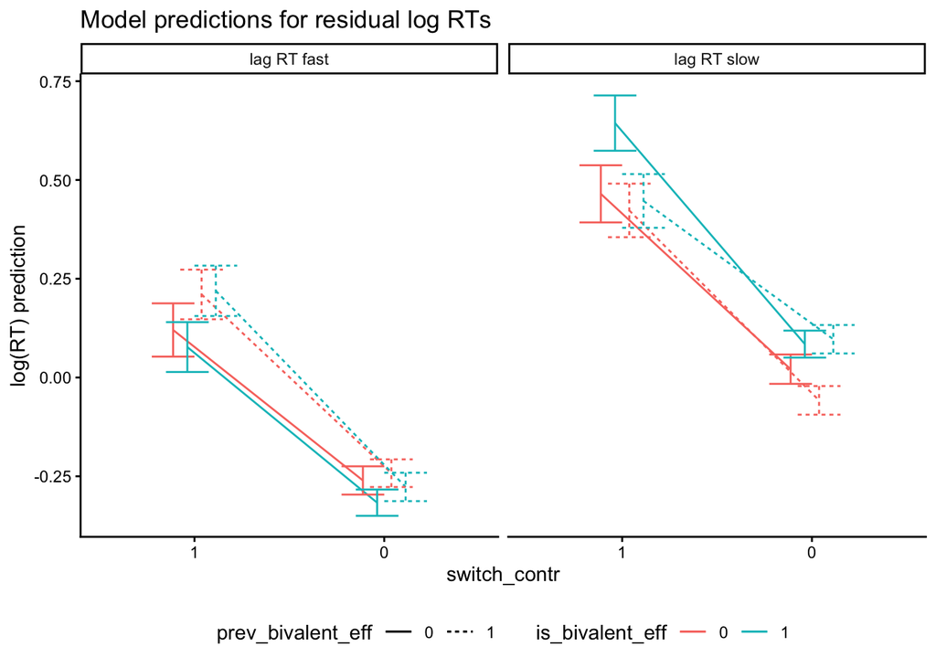

```r
ggplot(preds, aes(x = switch_contr, y = emmean, color = is_bivalent_eff, linetype = prev_bivalent_eff, group = interaction(is_bivalent_eff, prev_bivalent_eff)))+
  geom_line(position = pos)+
  geom_errorbar(aes(ymin = asymp.LCL, ymax = asymp.UCL), position = pos)+
  scale_x_discrete(limits = c("1", "0"))+
  facet_wrap(~speed, labeller = labeller(speed = c("slow" = "lag RT slow",
                                                   "fast" = "lag RT fast")))+
  labs(title = "Model predictions for residual log RTs",
       y = "log(RT) prediction")+
  theme_classic()+
  theme(legend.position = "bottom")
```

#### 7.1.1.1 Adding a lag switch

```r
alt_run <- alt_run %>%
  group_by(id, block) %>%
  mutate(lagSwitch_contr = lag(switch_contr, 1))

alt_run_rt_log_resrt_eff_w_s_int_lagswitch_switch_prev_bivalent <- xfun::cache_rds({
  lmer(time_log_res_w_s_int_c ~ is_bivalent_eff * prev_bivalent_eff * switch_contr * lag1_time_log_res_w_s_int_c + lagSwitch_contr +
         (lag1_time_log_res_w_s_int_c + switch_contr + prev_bivalent_eff + lagSwitch_contr| id),
       control = lmerControl(optimizer = "bobyqa"),
       alt_run %>% filter(filter_correct == 0)
  )
}, dir = "dominik/models/", file = "alt_run_rt_log_resrt_eff_w_s_int_lagswitch_switch_prev_bivalent.RDS", rerun = rerun_all)

summary(alt_run_rt_log_resrt_eff_w_s_int_switch_prev_bivalent)
```

```
## Linear mixed model fit by REML. t-tests use Satterthwaite's method [
## lmerModLmerTest]
## Formula: time_log_res_w_s_int_c ~ is_bivalent_eff * prev_bivalent_eff *
##     switch_contr * lag1_time_log_res_w_s_int_c + (lag1_time_log_res_w_s_int_c +
##     switch_contr + prev_bivalent_eff | id)
##    Data: alt_run %>% filter(filter_correct == 0)
## Control: lmerControl(optimizer = "bobyqa")
##
## REML criterion at convergence: 54930
##
## Scaled residuals:
##     Min      1Q  Median      3Q     Max
## -4.1178 -0.6538 -0.1134  0.4926  5.9410
##
## Random effects:
##  Groups   Name                        Variance  Std.Dev. Corr
##  id       (Intercept)                 0.0160161 0.12655
##           lag1_time_log_res_w_s_int_c 0.0010634 0.03261   0.11
##           switch_contr1               0.0225329 0.15011   0.21 -0.13
##           prev_bivalent_eff1          0.0001929 0.01389   0.63 -0.15  0.07
##  Residual                             0.1357298 0.36842
## Number of obs: 64276, groups:  id, 96
##
## Fixed effects:
##                                                                                 Estimate
## (Intercept)                                                                   -1.189e-01
## is_bivalent_eff1                                                               3.179e-02
## prev_bivalent_eff1                                                            -2.112e-03
## switch_contr1                                                                  4.447e-01
## lag1_time_log_res_w_s_int_c                                                    1.034e-01
## is_bivalent_eff1:prev_bivalent_eff1                                            5.641e-02
## is_bivalent_eff1:switch_contr1                                                 1.048e-02
## prev_bivalent_eff1:switch_contr1                                               4.423e-04
## is_bivalent_eff1:lag1_time_log_res_w_s_int_c                                   5.153e-02
## prev_bivalent_eff1:lag1_time_log_res_w_s_int_c                                -2.081e-02
## switch_contr1:lag1_time_log_res_w_s_int_c                                      9.214e-03
## is_bivalent_eff1:prev_bivalent_eff1:switch_contr1                             -1.077e-01
## is_bivalent_eff1:prev_bivalent_eff1:lag1_time_log_res_w_s_int_c                2.327e-02
## is_bivalent_eff1:switch_contr1:lag1_time_log_res_w_s_int_c                    -1.199e-02
## prev_bivalent_eff1:switch_contr1:lag1_time_log_res_w_s_int_c                  -5.773e-02
```

[output cut: 73 more lines]

```
## switch_contr1                                                                 ***
## lag1_time_log_res_w_s_int_c                                                   ***
## is_bivalent_eff1:prev_bivalent_eff1                                           ***
## is_bivalent_eff1:switch_contr1
## prev_bivalent_eff1:switch_contr1
## is_bivalent_eff1:lag1_time_log_res_w_s_int_c                                  ***
## prev_bivalent_eff1:lag1_time_log_res_w_s_int_c                                **
## switch_contr1:lag1_time_log_res_w_s_int_c
## is_bivalent_eff1:prev_bivalent_eff1:switch_contr1                             ***
## is_bivalent_eff1:prev_bivalent_eff1:lag1_time_log_res_w_s_int_c
## is_bivalent_eff1:switch_contr1:lag1_time_log_res_w_s_int_c
## prev_bivalent_eff1:switch_contr1:lag1_time_log_res_w_s_int_c                  **
## is_bivalent_eff1:prev_bivalent_eff1:switch_contr1:lag1_time_log_res_w_s_int_c **
## ---
## Signif. codes:  0 '***' 0.001 '**' 0.01 '*' 0.05 '.' 0.1 ' ' 1
```

```
##
## Correlation matrix not shown by default, as p = 16 > 12.
## Use print(x, correlation=TRUE)  or
##     vcov(x)        if you need it
```

```r
summary(alt_run_rt_log_resrt_eff_w_s_int_lagswitch_switch_prev_bivalent)
```

```
## Linear mixed model fit by REML. t-tests use Satterthwaite's method [
## lmerModLmerTest]
## Formula: time_log_res_w_s_int_c ~ is_bivalent_eff * prev_bivalent_eff *
##     switch_contr * lag1_time_log_res_w_s_int_c + lagSwitch_contr +
##     (lag1_time_log_res_w_s_int_c + switch_contr + prev_bivalent_eff +
##         lagSwitch_contr | id)
##    Data: alt_run %>% filter(filter_correct == 0)
## Control: lmerControl(optimizer = "bobyqa")
##
## REML criterion at convergence: 54646.5
##
## Scaled residuals:
##     Min      1Q  Median      3Q     Max
## -3.9389 -0.6523 -0.1099  0.4929  5.9970
##
## Random effects:
##  Groups   Name                        Variance  Std.Dev. Corr
##  id       (Intercept)                 0.0161228 0.12698
##           lag1_time_log_res_w_s_int_c 0.0018514 0.04303   0.09
##           switch_contr1               0.0248005 0.15748   0.12 -0.47
##           prev_bivalent_eff1          0.0002475 0.01573   0.52 -0.16  0.07
##           lagSwitch_contr1            0.0038764 0.06226   0.11 -0.60  0.64
##  Residual                             0.1348832 0.36726
##
##
##
##
##
##   0.25
##
## Number of obs: 64276, groups:  id, 96
##
## Fixed effects:
##                                                                                 Estimate
## (Intercept)                                                                   -1.325e-01
## is_bivalent_eff1                                                               3.327e-02
## prev_bivalent_eff1                                                            -1.809e-03
## switch_contr1                                                                  4.588e-01
## lag1_time_log_res_w_s_int_c                                                    7.894e-02
## lagSwitch_contr1                                                               4.877e-02
```

[output cut: 88 more lines]

```
## lag1_time_log_res_w_s_int_c                                                   ***
## lagSwitch_contr1                                                              ***
## is_bivalent_eff1:prev_bivalent_eff1                                           ***
## is_bivalent_eff1:switch_contr1
## prev_bivalent_eff1:switch_contr1
## is_bivalent_eff1:lag1_time_log_res_w_s_int_c                                  ***
## prev_bivalent_eff1:lag1_time_log_res_w_s_int_c                                **
## switch_contr1:lag1_time_log_res_w_s_int_c                                     ***
## is_bivalent_eff1:prev_bivalent_eff1:switch_contr1                             ***
## is_bivalent_eff1:prev_bivalent_eff1:lag1_time_log_res_w_s_int_c               *
## is_bivalent_eff1:switch_contr1:lag1_time_log_res_w_s_int_c
## prev_bivalent_eff1:switch_contr1:lag1_time_log_res_w_s_int_c                  ***
## is_bivalent_eff1:prev_bivalent_eff1:switch_contr1:lag1_time_log_res_w_s_int_c **
## ---
## Signif. codes:  0 '***' 0.001 '**' 0.01 '*' 0.05 '.' 0.1 ' ' 1
```

```
##
## Correlation matrix not shown by default, as p = 17 > 12.
## Use print(x, correlation=TRUE)  or
##     vcov(x)        if you need it
```

```r
anova(alt_run_rt_log_resrt_eff_w_s_int_switch_prev_bivalent, alt_run_rt_log_resrt_eff_w_s_int_lagswitch_switch_prev_bivalent)
```

```
## refitting model(s) with ML (instead of REML)
```

```
## Data: alt_run %>% filter(filter_correct == 0)
## Models:
## alt_run_rt_log_resrt_eff_w_s_int_switch_prev_bivalent: time_log_res_w_s_int_c ~ is_bivalent_eff * prev_bivalent_eff * switch_contr * lag1_time_log_res_w_s_int_c + (lag1_time_log_res_w_s_int_c + switch_contr + prev_bivalent_eff | id)
## alt_run_rt_log_resrt_eff_w_s_int_lagswitch_switch_prev_bivalent: time_log_res_w_s_int_c ~ is_bivalent_eff * prev_bivalent_eff * switch_contr * lag1_time_log_res_w_s_int_c + lagSwitch_contr + (lag1_time_log_res_w_s_int_c + switch_contr + prev_bivalent_eff + lagSwitch_contr | id)
##                                                                 npar   AIC
## alt_run_rt_log_resrt_eff_w_s_int_switch_prev_bivalent             27 54863
## alt_run_rt_log_resrt_eff_w_s_int_lagswitch_switch_prev_bivalent   33 54583
##                                                                   BIC logLik
## alt_run_rt_log_resrt_eff_w_s_int_switch_prev_bivalent           55108 -27404
## alt_run_rt_log_resrt_eff_w_s_int_lagswitch_switch_prev_bivalent 54883 -27259
##                                                                 -2*log(L)
## alt_run_rt_log_resrt_eff_w_s_int_switch_prev_bivalent               54809
## alt_run_rt_log_resrt_eff_w_s_int_lagswitch_switch_prev_bivalent     54517
##                                                                  Chisq Df
## alt_run_rt_log_resrt_eff_w_s_int_switch_prev_bivalent
## alt_run_rt_log_resrt_eff_w_s_int_lagswitch_switch_prev_bivalent 291.66  6
##                                                                 Pr(>Chisq)
## alt_run_rt_log_resrt_eff_w_s_int_switch_prev_bivalent
## alt_run_rt_log_resrt_eff_w_s_int_lagswitch_switch_prev_bivalent  < 2.2e-16 ***
## ---
## Signif. codes:  0 '***' 0.001 '**' 0.01 '*' 0.05 '.' 0.1 ' ' 1
```

#### 7.1.1.2 Coding position 2 as NA

One issue with the previous analysis is that the lag RT for the first trial after the switch is a switch RT. Therefore, I am here coding that RT as NA.

```r
alt_run_withinID_cycle2NA <- alt_run %>%
  filter(filter_correct == 0) %>%
  mutate(lag1_time_log_res_w_s_int_c = ifelse(cycle == 2, NA, lag1_time_log_res_w_s_int_c))

alt_run_rt_log_resrt_eff_w_s_int_cy2NA_switch_prev_bivalent <- xfun::cache_rds({
  lmer(time_log_res_w_s_int_c ~ is_bivalent_eff * prev_bivalent_eff * switch_contr * lag1_time_log_res_w_s_int_c +
         (lag1_time_log_res_w_s_int_c + switch_contr + prev_bivalent_eff| id),
       control = lmerControl(optimizer = "bobyqa"),
       alt_run_withinID_cycle2NA
  )
}, dir = "dominik/models/", file = "alt_run_rt_log_resrt_eff_w_s_int_cy2NA_switch_prev_bivalent.RDS", rerun = rerun_all)

summary(alt_run_rt_log_resrt_eff_w_s_int_cy2NA_switch_prev_bivalent)
```

```
## Linear mixed model fit by REML. t-tests use Satterthwaite's method [
## lmerModLmerTest]
## Formula: time_log_res_w_s_int_c ~ is_bivalent_eff * prev_bivalent_eff *
##     switch_contr * lag1_time_log_res_w_s_int_c + (lag1_time_log_res_w_s_int_c +
##     switch_contr + prev_bivalent_eff | id)
##    Data: alt_run_withinID_cycle2NA
## Control: lmerControl(optimizer = "bobyqa")
##
## REML criterion at convergence: 40521.8
##
## Scaled residuals:
##     Min      1Q  Median      3Q     Max
## -3.8997 -0.6557 -0.1084  0.4991  6.0893
##
## Random effects:
##  Groups   Name                        Variance  Std.Dev. Corr
##  id       (Intercept)                 0.0148823 0.12199
##           lag1_time_log_res_w_s_int_c 0.0018588 0.04311   0.04
##           switch_contr1               0.0251748 0.15867   0.14 -0.45
##           prev_bivalent_eff1          0.0003633 0.01906   0.27 -0.16  0.05
##  Residual                             0.1325917 0.36413
## Number of obs: 48518, groups:  id, 96
##
## Fixed effects:
##                                                                                 Estimate
## (Intercept)                                                                   -1.304e-01
## is_bivalent_eff1                                                               1.932e-02
## prev_bivalent_eff1                                                            -4.890e-03
## switch_contr1                                                                  4.569e-01
## lag1_time_log_res_w_s_int_c                                                    1.064e-01
## is_bivalent_eff1:prev_bivalent_eff1                                            3.700e-02
## is_bivalent_eff1:switch_contr1                                                 2.291e-02
## prev_bivalent_eff1:switch_contr1                                               3.204e-03
## is_bivalent_eff1:lag1_time_log_res_w_s_int_c                                   2.993e-02
## prev_bivalent_eff1:lag1_time_log_res_w_s_int_c                                -1.841e-02
## switch_contr1:lag1_time_log_res_w_s_int_c                                      9.297e-03
## is_bivalent_eff1:prev_bivalent_eff1:switch_contr1                             -8.848e-02
## is_bivalent_eff1:prev_bivalent_eff1:lag1_time_log_res_w_s_int_c               -1.046e-02
## is_bivalent_eff1:switch_contr1:lag1_time_log_res_w_s_int_c                     8.838e-03
## prev_bivalent_eff1:switch_contr1:lag1_time_log_res_w_s_int_c                  -5.860e-02
```

[output cut: 73 more lines]

```
## switch_contr1                                                                 ***
## lag1_time_log_res_w_s_int_c                                                   ***
## is_bivalent_eff1:prev_bivalent_eff1                                           ***
## is_bivalent_eff1:switch_contr1                                                **
## prev_bivalent_eff1:switch_contr1
## is_bivalent_eff1:lag1_time_log_res_w_s_int_c                                  **
## prev_bivalent_eff1:lag1_time_log_res_w_s_int_c                                .
## switch_contr1:lag1_time_log_res_w_s_int_c
## is_bivalent_eff1:prev_bivalent_eff1:switch_contr1                             ***
## is_bivalent_eff1:prev_bivalent_eff1:lag1_time_log_res_w_s_int_c
## is_bivalent_eff1:switch_contr1:lag1_time_log_res_w_s_int_c
## prev_bivalent_eff1:switch_contr1:lag1_time_log_res_w_s_int_c                  **
## is_bivalent_eff1:prev_bivalent_eff1:switch_contr1:lag1_time_log_res_w_s_int_c
## ---
## Signif. codes:  0 '***' 0.001 '**' 0.01 '*' 0.05 '.' 0.1 ' ' 1
```

```
##
## Correlation matrix not shown by default, as p = 16 > 12.
## Use print(x, correlation=TRUE)  or
##     vcov(x)        if you need it
```

```r
model_comp(summary(alt_run_rt_log_resrt_eff_w_s_int_cy2NA_switch_prev_bivalent), summary(alt_run_rt_log_resrt_eff_w_s_int_switch_prev_bivalent))
```

| Rows with differences in signs of estimates or binary significance (shared terms only) are bolded. term | Rows with differences in signs of estimates or binary significance (shared terms only) are bolded. Estimate_m1 | Rows with differences in signs of estimates or binary significance (shared terms only) are bolded. Estimate_m2 | Rows with differences in signs of estimates or binary significance (shared terms only) are bolded. p_m1 | Rows with differences in signs of estimates or binary significance (shared terms only) are bolded. p_m2 |
| --- | --- | --- | --- | --- |
| (Intercept) | -0.130 | -0.119 | 0.0000 | 0.0000 |
| is_bivalent_eff1 | 0.019 | 0.032 | 0.0000 | 0.0000 |
| prev_bivalent_eff1 | -0.005 | -0.002 | 0.2910 | 0.5670 |
| switch_contr1 | 0.457 | 0.445 | 0.0000 | 0.0000 |
| lag1_time_log_res_w_s_int_c | 0.106 | 0.103 | 0.0000 | 0.0000 |
| is_bivalent_eff1:prev_bivalent_eff1 | 0.037 | 0.056 | 0.0000 | 0.0000 |
| is_bivalent_eff1:switch_contr1 | 0.023 | 0.010 | 0.0020 | 0.1440 |
| prev_bivalent_eff1:switch_contr1 | 0.003 | 0.000 | 0.6700 | 0.9510 |
| is_bivalent_eff1:lag1_time_log_res_w_s_int_c | 0.030 | 0.052 | 0.0040 | 0.0000 |
| prev_bivalent_eff1:lag1_time_log_res_w_s_int_c | -0.018 | -0.021 | 0.0750 | 0.0040 |
| switch_contr1:lag1_time_log_res_w_s_int_c | 0.009 | 0.009 | 0.3610 | 0.3320 |
| is_bivalent_eff1:prev_bivalent_eff1:switch_contr1 | -0.088 | -0.108 | 0.0000 | 0.0000 |
| is_bivalent_eff1:prev_bivalent_eff1:lag1_time_log_res_w_s_int_c | -0.010 | 0.023 | 0.6090 | 0.1070 |
| is_bivalent_eff1:switch_contr1:lag1_time_log_res_w_s_int_c | 0.009 | -0.012 | 0.6420 | 0.4990 |
| prev_bivalent_eff1:switch_contr1:lag1_time_log_res_w_s_int_c | -0.059 | -0.058 | 0.0020 | 0.0010 |
| is_bivalent_eff1:prev_bivalent_eff1:switch_contr1:lag1_time_log_res_w_s_int_c | -0.056 | -0.092 | 0.1440 | 0.0090 |

```r
preds <- emmeans::emmeans(alt_run_rt_log_resrt_eff_w_s_int_cy2NA_switch_prev_bivalent, ~ is_bivalent_eff * prev_bivalent_eff * switch_contr * lag1_time_log_res_w_s_int_c, type = "response",
                          at = list(is_bivalent_eff = factor(c(0, 1)),
                                    prev_bivalent_eff = factor(c(0, 1)),
                                    switch_contr = factor(c(0, 1)),
                                    lag1_time_log_res_w_s_int_c = c(-1.5, 1.5))) %>%
  as.data.frame() %>%
  mutate(speed = case_when(lag1_time_log_res_w_s_int_c == min(lag1_time_log_res_w_s_int_c) ~ "fast",
                           lag1_time_log_res_w_s_int_c == max(lag1_time_log_res_w_s_int_c) ~ "slow") %>% factor())
```

```
## Note: D.f. calculations have been disabled because the number of observations exceeds 3000.
## To enable adjustments, add the argument 'pbkrtest.limit = 48518' (or larger)
## [or, globally, 'set emm_options(pbkrtest.limit = 48518)' or larger];
## but be warned that this may result in large computation time and memory use.
```

```
## Note: D.f. calculations have been disabled because the number of observations exceeds 3000.
## To enable adjustments, add the argument 'lmerTest.limit = 48518' (or larger)
## [or, globally, 'set emm_options(lmerTest.limit = 48518)' or larger];
## but be warned that this may result in large computation time and memory use.
```

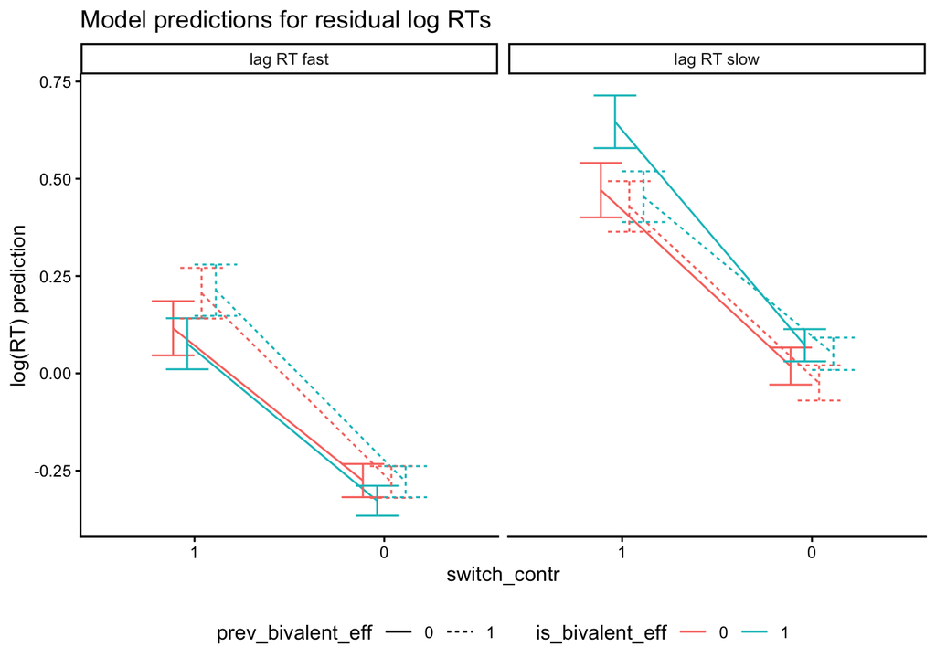

```r
ggplot(preds, aes(x = switch_contr, y = emmean, color = is_bivalent_eff, linetype = prev_bivalent_eff, group = interaction(is_bivalent_eff, prev_bivalent_eff)))+
  geom_line(position = pos)+
  geom_errorbar(aes(ymin = asymp.LCL, ymax = asymp.UCL), position = pos)+
  scale_x_discrete(limits = c("1", "0"))+
  facet_wrap(~speed, labeller = labeller(speed = c("slow" = "lag RT slow",
                                                   "fast" = "lag RT fast")))+
  labs(title = "Model predictions for residual log RTs",
       y = "log(RT) prediction")+
  theme_classic()+
  theme(legend.position = "bottom")
```

#### 7.1.1.3 Using the mean NS RT from previous group

```r
alt_run <- alt_run %>%
  group_by(id, block, trialgroup) %>%
  mutate(Avg_NS_RT_log_res_w_s_int_c = mean(lag1_time_log_res_w_s_int_c[switch == 0], na.rm = TRUE)) %>%
  group_by(id, block) %>%
  mutate(prev_group_Avg_NS_RT_log_res_w_s_int_c = lag(Avg_NS_RT_log_res_w_s_int_c, 1)) %>%
  group_by(id, block, trialgroup) %>%
  mutate(prev_group_Avg_NS_RT_log_res_w_s_int_c = prev_group_Avg_NS_RT_log_res_w_s_int_c[1])



alt_run_rt_log_resrt_eff_w_s_int_rt_prevgroup_switch_prev_bivalent <- xfun::cache_rds({
  lmer(time_log_res_w_s_int_c ~ is_bivalent_eff * prev_bivalent_eff * switch_contr * prev_group_Avg_NS_RT_log_res_w_s_int_c +
         (prev_group_Avg_NS_RT_log_res_w_s_int_c + switch_contr + prev_bivalent_eff| id),
       control = lmerControl(optimizer = "bobyqa"),
       alt_run %>%
         filter(filter_correct == 0)
  )
}, dir = "dominik/models/", file = "alt_run_rt_log_resrt_eff_w_s_int_rt_prevgroup_switch_prev_bivalent.RDS", rerun = rerun_all)

summary(alt_run_rt_log_resrt_eff_w_s_int_rt_prevgroup_switch_prev_bivalent)
```

```
## Linear mixed model fit by REML. t-tests use Satterthwaite's method [
## lmerModLmerTest]
## Formula: time_log_res_w_s_int_c ~ is_bivalent_eff * prev_bivalent_eff *
##     switch_contr * prev_group_Avg_NS_RT_log_res_w_s_int_c + (prev_group_Avg_NS_RT_log_res_w_s_int_c +
##     switch_contr + prev_bivalent_eff | id)
##    Data: alt_run %>% filter(filter_correct == 0)
## Control: lmerControl(optimizer = "bobyqa")
##
## REML criterion at convergence: 54305.3
##
## Scaled residuals:
##     Min      1Q  Median      3Q     Max
## -3.9927 -0.6526 -0.1154  0.4840  5.8221
##
## Random effects:
##  Groups   Name                                   Variance  Std.Dev. Corr
##  id       (Intercept)                            0.0181562 0.13474
##           prev_group_Avg_NS_RT_log_res_w_s_int_c 0.0037441 0.06119   0.02
##           switch_contr1                          0.0203887 0.14279   0.22 -0.25
##           prev_bivalent_eff1                     0.0002901 0.01703   0.56 -0.19
##  Residual                                        0.1375150 0.37083
##
##
##
##
##   0.22
##
## Number of obs: 62551, groups:  id, 96
##
## Fixed effects:
##                                                                                            Estimate
## (Intercept)                                                                              -1.170e-01
## is_bivalent_eff1                                                                          4.157e-02
## prev_bivalent_eff1                                                                       -2.088e-03
## switch_contr1                                                                             4.288e-01
## prev_group_Avg_NS_RT_log_res_w_s_int_c                                                    4.409e-02
## is_bivalent_eff1:prev_bivalent_eff1                                                       6.353e-02
## is_bivalent_eff1:switch_contr1                                                           -8.295e-03
## prev_bivalent_eff1:switch_contr1                                                          1.537e-02
## is_bivalent_eff1:prev_group_Avg_NS_RT_log_res_w_s_int_c                                   3.230e-02
```

[output cut: 79 more lines]

```
## switch_contr1                                                                            ***
## prev_group_Avg_NS_RT_log_res_w_s_int_c                                                   ***
## is_bivalent_eff1:prev_bivalent_eff1                                                      ***
## is_bivalent_eff1:switch_contr1
## prev_bivalent_eff1:switch_contr1                                                         *
## is_bivalent_eff1:prev_group_Avg_NS_RT_log_res_w_s_int_c                                  **
## prev_bivalent_eff1:prev_group_Avg_NS_RT_log_res_w_s_int_c                                *
## switch_contr1:prev_group_Avg_NS_RT_log_res_w_s_int_c                                     .
## is_bivalent_eff1:prev_bivalent_eff1:switch_contr1                                        ***
## is_bivalent_eff1:prev_bivalent_eff1:prev_group_Avg_NS_RT_log_res_w_s_int_c               .
## is_bivalent_eff1:switch_contr1:prev_group_Avg_NS_RT_log_res_w_s_int_c
## prev_bivalent_eff1:switch_contr1:prev_group_Avg_NS_RT_log_res_w_s_int_c                  ***
## is_bivalent_eff1:prev_bivalent_eff1:switch_contr1:prev_group_Avg_NS_RT_log_res_w_s_int_c *
## ---
## Signif. codes:  0 '***' 0.001 '**' 0.01 '*' 0.05 '.' 0.1 ' ' 1
```

```
##
## Correlation matrix not shown by default, as p = 16 > 12.
## Use print(x, correlation=TRUE)  or
##     vcov(x)        if you need it
```

```r
model_comp(
  summary(alt_run_rt_log_resrt_eff_w_s_int_rt_prevgroup_switch_prev_bivalent), summary(alt_run_rt_log_resrt_eff_w_s_int_switch_prev_bivalent))
```

| Rows with differences in signs of estimates or binary significance (shared terms only) are bolded. term | Rows with differences in signs of estimates or binary significance (shared terms only) are bolded. Estimate_m1 | Rows with differences in signs of estimates or binary significance (shared terms only) are bolded. Estimate_m2 | Rows with differences in signs of estimates or binary significance (shared terms only) are bolded. p_m1 | Rows with differences in signs of estimates or binary significance (shared terms only) are bolded. p_m2 |
| --- | --- | --- | --- | --- |
| (Intercept) | -0.117 | -0.119 | 0.0000 | 0.0000 |
| is_bivalent_eff1 | 0.042 | 0.032 | 0.0000 | 0.0000 |
| prev_bivalent_eff1 | -0.002 | -0.002 | 0.5970 | 0.5670 |
| switch_contr1 | 0.429 | 0.445 | 0.0000 | 0.0000 |
| prev_group_Avg_NS_RT_log_res_w_s_int_c | 0.044 |  | 0.0000 |  |
| is_bivalent_eff1:prev_bivalent_eff1 | 0.064 | 0.056 | 0.0000 | 0.0000 |
| is_bivalent_eff1:switch_contr1 | -0.008 | 0.010 | 0.2410 | 0.1440 |
| prev_bivalent_eff1:switch_contr1 | 0.015 | 0.000 | 0.0300 | 0.9510 |
| is_bivalent_eff1:prev_group_Avg_NS_RT_log_res_w_s_int_c | 0.032 |  | 0.0040 |  |
| prev_bivalent_eff1:prev_group_Avg_NS_RT_log_res_w_s_int_c | -0.023 |  | 0.0500 |  |
| switch_contr1:prev_group_Avg_NS_RT_log_res_w_s_int_c | 0.025 |  | 0.0590 |  |
| is_bivalent_eff1:prev_bivalent_eff1:switch_contr1 | -0.098 | -0.108 | 0.0000 | 0.0000 |
| is_bivalent_eff1:prev_bivalent_eff1:prev_group_Avg_NS_RT_log_res_w_s_int_c | 0.042 |  | 0.0610 |  |
| is_bivalent_eff1:switch_contr1:prev_group_Avg_NS_RT_log_res_w_s_int_c | -0.001 |  | 0.9720 |  |
| prev_bivalent_eff1:switch_contr1:prev_group_Avg_NS_RT_log_res_w_s_int_c | -0.087 |  | 0.0000 |  |
| is_bivalent_eff1:prev_bivalent_eff1:switch_contr1:prev_group_Avg_NS_RT_log_res_w_s_int_c | -0.107 |  | 0.0180 |  |
| lag1_time_log_res_w_s_int_c |  | 0.103 |  | 0.0000 |
| is_bivalent_eff1:lag1_time_log_res_w_s_int_c |  | 0.052 |  | 0.0000 |
| prev_bivalent_eff1:lag1_time_log_res_w_s_int_c |  | -0.021 |  | 0.0040 |
| switch_contr1:lag1_time_log_res_w_s_int_c |  | 0.009 |  | 0.3320 |
| is_bivalent_eff1:prev_bivalent_eff1:lag1_time_log_res_w_s_int_c |  | 0.023 |  | 0.1070 |
| is_bivalent_eff1:switch_contr1:lag1_time_log_res_w_s_int_c |  | -0.012 |  | 0.4990 |
| prev_bivalent_eff1:switch_contr1:lag1_time_log_res_w_s_int_c |  | -0.058 |  | 0.0010 |
| is_bivalent_eff1:prev_bivalent_eff1:switch_contr1:lag1_time_log_res_w_s_int_c |  | -0.092 |  | 0.0090 |

```r
preds <- emmeans::emmeans(alt_run_rt_log_resrt_eff_w_s_int_rt_prevgroup_switch_prev_bivalent, ~ is_bivalent_eff * prev_bivalent_eff * switch_contr * prev_group_Avg_NS_RT_log_res_w_s_int_c, type = "response",
                          at = list(is_bivalent_eff = factor(c(0, 1)),
                                    prev_bivalent_eff = factor(c(0, 1)),
                                    switch_contr = factor(c(0, 1)),
                                    prev_group_Avg_NS_RT_log_res_w_s_int_c = c(-1.5, 1.5))) %>%
  as.data.frame() %>%
  mutate(speed = case_when(prev_group_Avg_NS_RT_log_res_w_s_int_c == min(prev_group_Avg_NS_RT_log_res_w_s_int_c) ~ "fast",
                           prev_group_Avg_NS_RT_log_res_w_s_int_c == max(prev_group_Avg_NS_RT_log_res_w_s_int_c) ~ "slow") %>% factor())
```

```
## Note: D.f. calculations have been disabled because the number of observations exceeds 3000.
## To enable adjustments, add the argument 'pbkrtest.limit = 62551' (or larger)
## [or, globally, 'set emm_options(pbkrtest.limit = 62551)' or larger];
## but be warned that this may result in large computation time and memory use.
```

```
## Note: D.f. calculations have been disabled because the number of observations exceeds 3000.
## To enable adjustments, add the argument 'lmerTest.limit = 62551' (or larger)
## [or, globally, 'set emm_options(lmerTest.limit = 62551)' or larger];
## but be warned that this may result in large computation time and memory use.
```

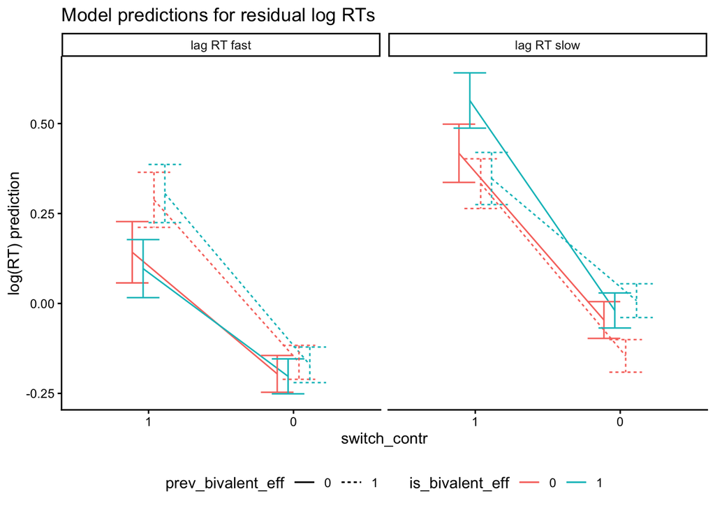

```r
ggplot(preds, aes(x = switch_contr, y = emmean, color = is_bivalent_eff, linetype = prev_bivalent_eff, group = interaction(is_bivalent_eff, prev_bivalent_eff)))+
  geom_line(position = pos)+
  geom_errorbar(aes(ymin = asymp.LCL, ymax = asymp.UCL), position = pos)+
  scale_x_discrete(limits = c("1", "0"))+
  facet_wrap(~speed, labeller = labeller(speed = c("slow" = "lag RT slow",
                                                   "fast" = "lag RT fast")))+
  labs(title = "Model predictions for residual log RTs",
       y = "log(RT) prediction")+
  theme_classic()+
  theme(legend.position = "bottom")
```

```r
make_model_table(alt_run_rt_log_resrt_eff_w_s_int_switch_prev_bivalent)
```

| Call: lmer(formula = time_log_res_w_s_int_c ~ is_bivalent_eff * prev_bivalent_eff * switch_contr * lag1_time_log_res_w_s_int_c + (lag1_time_log_res_w_s_int_c + switch_contr + prev_bivalent_eff \| id),… term | Call: lmer(formula = time_log_res_w_s_int_c ~ is_bivalent_eff * prev_bivalent_eff * switch_contr * lag1_time_log_res_w_s_int_c + (lag1_time_log_res_w_s_int_c + switch_contr + prev_bivalent_eff \| id),… Estimate | Call: lmer(formula = time_log_res_w_s_int_c ~ is_bivalent_eff * prev_bivalent_eff * switch_contr * lag1_time_log_res_w_s_int_c + (lag1_time_log_res_w_s_int_c + switch_contr + prev_bivalent_eff \| id),… Std. Error | Call: lmer(formula = time_log_res_w_s_int_c ~ is_bivalent_eff * prev_bivalent_eff * switch_contr * lag1_time_log_res_w_s_int_c + (lag1_time_log_res_w_s_int_c + switch_contr + prev_bivalent_eff \| id),… df | Call: lmer(formula = time_log_res_w_s_int_c ~ is_bivalent_eff * prev_bivalent_eff * switch_contr * lag1_time_log_res_w_s_int_c + (lag1_time_log_res_w_s_int_c + switch_contr + prev_bivalent_eff \| id),… t value | Call: lmer(formula = time_log_res_w_s_int_c ~ is_bivalent_eff * prev_bivalent_eff * switch_contr * lag1_time_log_res_w_s_int_c + (lag1_time_log_res_w_s_int_c + switch_contr + prev_bivalent_eff \| id),… Pr(>\|t\|) |
| --- | --- | --- | --- | --- | --- |
| (Intercept) | -0.12 | 0.01 | 94.45 | -9.13 | 0.0000 |
| is_bivalent_eff1 | 0.03 | 0.00 | 63,272.91 | 9.36 | 0.0000 |
| prev_bivalent_eff1 | -0.00 | 0.00 | 148.95 | -0.57 | 0.5670 |
| switch_contr1 | 0.44 | 0.02 | 95.71 | 28.25 | 0.0000 |
| lag1_time_log_res_w_s_int_c | 0.10 | 0.01 | 112.93 | 20.02 | 0.0000 |
| is_bivalent_eff1:prev_bivalent_eff1 | 0.06 | 0.01 | 58,656.85 | 8.34 | 0.0000 |
| is_bivalent_eff1:switch_contr1 | 0.01 | 0.01 | 64,072.94 | 1.46 | 0.1439 |
| prev_bivalent_eff1:switch_contr1 | 0.00 | 0.01 | 63,909.92 | 0.06 | 0.9509 |
| is_bivalent_eff1:lag1_time_log_res_w_s_int_c | 0.05 | 0.01 | 61,911.89 | 7.13 | 0.0000 |
| prev_bivalent_eff1:lag1_time_log_res_w_s_int_c | -0.02 | 0.01 | 10,664.19 | -2.86 | 0.0042 |
| switch_contr1:lag1_time_log_res_w_s_int_c | 0.01 | 0.01 | 61,210.16 | 0.97 | 0.3322 |
| is_bivalent_eff1:prev_bivalent_eff1:switch_contr1 | -0.11 | 0.01 | 64,053.09 | -7.55 | 0.0000 |
| is_bivalent_eff1:prev_bivalent_eff1:lag1_time_log_res_w_s_int_c | 0.02 | 0.01 | 63,527.98 | 1.61 | 0.1067 |
| is_bivalent_eff1:switch_contr1:lag1_time_log_res_w_s_int_c | -0.01 | 0.02 | 63,931.66 | -0.68 | 0.4985 |
| prev_bivalent_eff1:switch_contr1:lag1_time_log_res_w_s_int_c | -0.06 | 0.02 | 63,249.14 | -3.25 | 0.0011 |
| is_bivalent_eff1:prev_bivalent_eff1:switch_contr1:lag1_time_log_res_w_s_int_c | -0.09 | 0.04 | 63,965.06 | -2.60 | 0.0093 |

```r
make_model_table(alt_run_rt_log_resrt_eff_w_s_int_cy2NA_switch_prev_bivalent)
```

| Call: lmer(formula = time_log_res_w_s_int_c ~ is_bivalent_eff * prev_bivalent_eff * switch_contr * lag1_time_log_res_w_s_int_c + (lag1_time_log_res_w_s_int_c + switch_contr + prev_bivalent_eff \| id),… term | Call: lmer(formula = time_log_res_w_s_int_c ~ is_bivalent_eff * prev_bivalent_eff * switch_contr * lag1_time_log_res_w_s_int_c + (lag1_time_log_res_w_s_int_c + switch_contr + prev_bivalent_eff \| id),… Estimate | Call: lmer(formula = time_log_res_w_s_int_c ~ is_bivalent_eff * prev_bivalent_eff * switch_contr * lag1_time_log_res_w_s_int_c + (lag1_time_log_res_w_s_int_c + switch_contr + prev_bivalent_eff \| id),… Std. Error | Call: lmer(formula = time_log_res_w_s_int_c ~ is_bivalent_eff * prev_bivalent_eff * switch_contr * lag1_time_log_res_w_s_int_c + (lag1_time_log_res_w_s_int_c + switch_contr + prev_bivalent_eff \| id),… df | Call: lmer(formula = time_log_res_w_s_int_c ~ is_bivalent_eff * prev_bivalent_eff * switch_contr * lag1_time_log_res_w_s_int_c + (lag1_time_log_res_w_s_int_c + switch_contr + prev_bivalent_eff \| id),… t value | Call: lmer(formula = time_log_res_w_s_int_c ~ is_bivalent_eff * prev_bivalent_eff * switch_contr * lag1_time_log_res_w_s_int_c + (lag1_time_log_res_w_s_int_c + switch_contr + prev_bivalent_eff \| id),… Pr(>\|t\|) |
| --- | --- | --- | --- | --- | --- |
| (Intercept) | -0.13 | 0.01 | 94.15 | -10.32 | 0.0000 |
| is_bivalent_eff1 | 0.02 | 0.00 | 48,184.98 | 4.61 | 0.0000 |
| prev_bivalent_eff1 | -0.00 | 0.00 | 186.80 | -1.06 | 0.2914 |
| switch_contr1 | 0.46 | 0.02 | 96.04 | 27.47 | 0.0000 |
| lag1_time_log_res_w_s_int_c | 0.11 | 0.01 | 137.05 | 14.90 | 0.0000 |
| is_bivalent_eff1:prev_bivalent_eff1 | 0.04 | 0.01 | 46,464.08 | 4.43 | 0.0000 |
| is_bivalent_eff1:switch_contr1 | 0.02 | 0.01 | 48,288.69 | 3.05 | 0.0023 |
| prev_bivalent_eff1:switch_contr1 | 0.00 | 0.01 | 48,310.02 | 0.43 | 0.6702 |
| is_bivalent_eff1:lag1_time_log_res_w_s_int_c | 0.03 | 0.01 | 46,021.49 | 2.92 | 0.0035 |
| prev_bivalent_eff1:lag1_time_log_res_w_s_int_c | -0.02 | 0.01 | 12,633.05 | -1.78 | 0.0753 |
| switch_contr1:lag1_time_log_res_w_s_int_c | 0.01 | 0.01 | 46,313.41 | 0.91 | 0.3611 |
| is_bivalent_eff1:prev_bivalent_eff1:switch_contr1 | -0.09 | 0.01 | 48,293.94 | -5.91 | 0.0000 |
| is_bivalent_eff1:prev_bivalent_eff1:lag1_time_log_res_w_s_int_c | -0.01 | 0.02 | 47,613.12 | -0.51 | 0.6094 |
| is_bivalent_eff1:switch_contr1:lag1_time_log_res_w_s_int_c | 0.01 | 0.02 | 47,762.76 | 0.46 | 0.6420 |
| prev_bivalent_eff1:switch_contr1:lag1_time_log_res_w_s_int_c | -0.06 | 0.02 | 47,729.09 | -3.08 | 0.0021 |
| is_bivalent_eff1:prev_bivalent_eff1:switch_contr1:lag1_time_log_res_w_s_int_c | -0.06 | 0.04 | 48,025.59 | -1.46 | 0.1441 |

```r
make_model_table(alt_run_rt_log_resrt_eff_w_s_int_rt_prevgroup_switch_prev_bivalent)
```

| Call: lmer(formula = time_log_res_w_s_int_c ~ is_bivalent_eff * prev_bivalent_eff * switch_contr * prev_group_Avg_NS_RT_log_res_w_s_int_c + (prev_group_Avg_NS_RT_log_res_w_s_int_c + switch_contr + pre… term | Call: lmer(formula = time_log_res_w_s_int_c ~ is_bivalent_eff * prev_bivalent_eff * switch_contr * prev_group_Avg_NS_RT_log_res_w_s_int_c + (prev_group_Avg_NS_RT_log_res_w_s_int_c + switch_contr + pre… Estimate | Call: lmer(formula = time_log_res_w_s_int_c ~ is_bivalent_eff * prev_bivalent_eff * switch_contr * prev_group_Avg_NS_RT_log_res_w_s_int_c + (prev_group_Avg_NS_RT_log_res_w_s_int_c + switch_contr + pre… Std. Error | Call: lmer(formula = time_log_res_w_s_int_c ~ is_bivalent_eff * prev_bivalent_eff * switch_contr * prev_group_Avg_NS_RT_log_res_w_s_int_c + (prev_group_Avg_NS_RT_log_res_w_s_int_c + switch_contr + pre… df | Call: lmer(formula = time_log_res_w_s_int_c ~ is_bivalent_eff * prev_bivalent_eff * switch_contr * prev_group_Avg_NS_RT_log_res_w_s_int_c + (prev_group_Avg_NS_RT_log_res_w_s_int_c + switch_contr + pre… t value | Call: lmer(formula = time_log_res_w_s_int_c ~ is_bivalent_eff * prev_bivalent_eff * switch_contr * prev_group_Avg_NS_RT_log_res_w_s_int_c + (prev_group_Avg_NS_RT_log_res_w_s_int_c + switch_contr + pre… Pr(>\|t\|) |
| --- | --- | --- | --- | --- | --- |
| (Intercept) | -0.12 | 0.01 | 93.34 | -8.43 | 0.0000 |
| is_bivalent_eff1 | 0.04 | 0.00 | 61,754.95 | 11.80 | 0.0000 |
| prev_bivalent_eff1 | -0.00 | 0.00 | 145.35 | -0.53 | 0.5969 |
| switch_contr1 | 0.43 | 0.01 | 94.54 | 28.59 | 0.0000 |
| prev_group_Avg_NS_RT_log_res_w_s_int_c | 0.04 | 0.01 | 119.09 | 4.77 | 0.0000 |
| is_bivalent_eff1:prev_bivalent_eff1 | 0.06 | 0.01 | 58,916.23 | 9.05 | 0.0000 |
| is_bivalent_eff1:switch_contr1 | -0.01 | 0.01 | 62,267.31 | -1.17 | 0.2412 |
| prev_bivalent_eff1:switch_contr1 | 0.02 | 0.01 | 62,282.66 | 2.17 | 0.0303 |
| is_bivalent_eff1:prev_group_Avg_NS_RT_log_res_w_s_int_c | 0.03 | 0.01 | 59,637.89 | 2.85 | 0.0043 |
| prev_bivalent_eff1:prev_group_Avg_NS_RT_log_res_w_s_int_c | -0.02 | 0.01 | 2,277.91 | -1.96 | 0.0497 |
| switch_contr1:prev_group_Avg_NS_RT_log_res_w_s_int_c | 0.03 | 0.01 | 43,956.84 | 1.89 | 0.0594 |
| is_bivalent_eff1:prev_bivalent_eff1:switch_contr1 | -0.10 | 0.01 | 62,227.18 | -6.97 | 0.0000 |
| is_bivalent_eff1:prev_bivalent_eff1:prev_group_Avg_NS_RT_log_res_w_s_int_c | 0.04 | 0.02 | 60,693.07 | 1.87 | 0.0615 |
| is_bivalent_eff1:switch_contr1:prev_group_Avg_NS_RT_log_res_w_s_int_c | -0.00 | 0.02 | 62,258.99 | -0.03 | 0.9723 |
| prev_bivalent_eff1:switch_contr1:prev_group_Avg_NS_RT_log_res_w_s_int_c | -0.09 | 0.02 | 62,297.77 | -3.81 | 0.0001 |
| is_bivalent_eff1:prev_bivalent_eff1:switch_contr1:prev_group_Avg_NS_RT_log_res_w_s_int_c | -0.11 | 0.05 | 62,259.65 | -2.37 | 0.0178 |

## 7.2 Contrast coded (0, 1)

### 7.2.1 Removed subject intercepts - removed from output

```r
alt_run_rt_log_resrt_contr <- xfun::cache_rds({
  lmer(time_log_res ~ is_bivalent_contr * prev_bivalent_contr * switch_contr * lag1_time_log_res + (is_bivalent_contr + prev_bivalent_contr + switch_contr + lag1_time_log_res |id), control = lmerControl(optimizer = "bobyqa"),
       alt_run %>%
         filter(filter_correct == 0))
}, dir = "dominik/models/", file = "alt_run_rt_log_resrt_contr.RDS", rerun = rerun_all)



make_model_table(alt_run_rt_log_resrt_contr)

preds <- emmeans::emmeans(alt_run_rt_log_resrt_contr, ~ is_bivalent_contr * prev_bivalent_contr * switch_contr * lag1_time_log_res, type = "response",
                          at = list(is_bivalent_contr = factor(c(0, 1)),
                                    prev_bivalent_contr = factor(c(0, 1)),
                                    switch_contr = factor(c(0, 1)),
                                    lag1_time_log_res = c(-1.5, 1.5))) %>%
  as.data.frame() %>%
  mutate(speed = case_when(lag1_time_log_res == min(lag1_time_log_res) ~ "fast",
                           lag1_time_log_res == max(lag1_time_log_res) ~ "slow") %>% factor())



ggplot(preds, aes(x = switch_contr, y = emmean, color = is_bivalent_contr, linetype = prev_bivalent_contr, group = interaction(is_bivalent_contr, prev_bivalent_contr)))+
  geom_line(position = pos)+
  geom_errorbar(aes(ymin = asymp.LCL, ymax = asymp.UCL), position = pos)+
  scale_x_discrete(limits = c("1", "0"))+
  facet_wrap(~speed, labeller = labeller(speed = c("slow" = "lag RT slow",
                                                   "fast" = "lag RT fast")))+
  labs(title = "Model predictions for residual log RTs",
       y = "log(RT) prediction")+
  theme_classic()
```

### 7.2.2 Added subject intercepts

Convergence problems. Let’s simplify!

```r
#BASELINE MODEL

alt_run_rt_log_resrt_contr_w_s_int <- xfun::cache_rds({
  lmer(time_log_res_w_s_int_c ~ is_bivalent_contr * prev_bivalent_contr * switch_contr * lag1_time_log_res_w_s_int_c + (lag1_time_log_res_w_s_int_c | id),
       control = lmerControl(optimizer = "bobyqa"),
       alt_run %>%
         filter(filter_correct == 0))
}, dir = "dominik/models/", file = "alt_run_rt_log_resrt_contr_w_s_int.RDS", rerun = rerun_all)

make_model_table(alt_run_rt_log_resrt_contr_w_s_int)
```

| Call: lmer(formula = time_log_res_w_s_int_c ~ is_bivalent_contr * prev_bivalent_contr * switch_contr * lag1_time_log_res_w_s_int_c + (lag1_time_log_res_w_s_int_c \| id), data = alt_run %>% filter(filt… term | Call: lmer(formula = time_log_res_w_s_int_c ~ is_bivalent_contr * prev_bivalent_contr * switch_contr * lag1_time_log_res_w_s_int_c + (lag1_time_log_res_w_s_int_c \| id), data = alt_run %>% filter(filt… Estimate | Call: lmer(formula = time_log_res_w_s_int_c ~ is_bivalent_contr * prev_bivalent_contr * switch_contr * lag1_time_log_res_w_s_int_c + (lag1_time_log_res_w_s_int_c \| id), data = alt_run %>% filter(filt… Std. Error | Call: lmer(formula = time_log_res_w_s_int_c ~ is_bivalent_contr * prev_bivalent_contr * switch_contr * lag1_time_log_res_w_s_int_c + (lag1_time_log_res_w_s_int_c \| id), data = alt_run %>% filter(filt… df | Call: lmer(formula = time_log_res_w_s_int_c ~ is_bivalent_contr * prev_bivalent_contr * switch_contr * lag1_time_log_res_w_s_int_c + (lag1_time_log_res_w_s_int_c \| id), data = alt_run %>% filter(filt… t value | Call: lmer(formula = time_log_res_w_s_int_c ~ is_bivalent_contr * prev_bivalent_contr * switch_contr * lag1_time_log_res_w_s_int_c + (lag1_time_log_res_w_s_int_c \| id), data = alt_run %>% filter(filt… Pr(>\|t\|) |
| --- | --- | --- | --- | --- | --- |
| (Intercept) | -0.12 | 0.01 | 104.17 | -8.03 | 0.0000 |
| is_bivalent_contr1 | 0.00 | 0.00 | 64,153.09 | 0.88 | 0.3786 |
| prev_bivalent_contr1 | -0.03 | 0.00 | 64,141.87 | -6.27 | 0.0000 |
| switch_contr1 | 0.42 | 0.01 | 64,134.61 | 56.25 | 0.0000 |
| lag1_time_log_res_w_s_int_c | 0.08 | 0.01 | 651.85 | 8.32 | 0.0000 |
| is_bivalent_contr1:prev_bivalent_contr1 | 0.06 | 0.01 | 64,161.30 | 8.31 | 0.0000 |
| is_bivalent_contr1:switch_contr1 | 0.06 | 0.01 | 64,141.91 | 5.99 | 0.0000 |
| prev_bivalent_contr1:switch_contr1 | 0.05 | 0.01 | 64,142.15 | 5.17 | 0.0000 |
| is_bivalent_contr1:lag1_time_log_res_w_s_int_c | 0.04 | 0.01 | 63,753.62 | 4.00 | 0.0001 |
| prev_bivalent_contr1:lag1_time_log_res_w_s_int_c | -0.02 | 0.01 | 63,823.56 | -2.28 | 0.0224 |
| switch_contr1:lag1_time_log_res_w_s_int_c | 0.07 | 0.02 | 64,166.93 | 3.66 | 0.0003 |
| is_bivalent_contr1:prev_bivalent_contr1:switch_contr1 | -0.11 | 0.01 | 64,148.38 | -7.48 | 0.0000 |
| is_bivalent_contr1:prev_bivalent_contr1:lag1_time_log_res_w_s_int_c | 0.02 | 0.01 | 63,954.20 | 1.45 | 0.1473 |
| is_bivalent_contr1:switch_contr1:lag1_time_log_res_w_s_int_c | 0.02 | 0.03 | 64,160.72 | 0.81 | 0.4153 |
| prev_bivalent_contr1:switch_contr1:lag1_time_log_res_w_s_int_c | -0.04 | 0.03 | 64,161.26 | -1.37 | 0.1691 |
| is_bivalent_contr1:prev_bivalent_contr1:switch_contr1:lag1_time_log_res_w_s_int_c | -0.07 | 0.04 | 64,157.62 | -1.99 | 0.0469 |

```r
#this model is singular
alt_run_rt_log_resrt_contr_w_s_int_switch_is_bivalent <- xfun::cache_rds({
  lmer(time_log_res_w_s_int_c ~ is_bivalent_contr * prev_bivalent_contr * switch_contr * lag1_time_log_res_w_s_int_c +
         (lag1_time_log_res_w_s_int_c + switch_contr + is_bivalent_contr| id),
       control = lmerControl(optimizer = "bobyqa"),
       alt_run %>%
         filter(filter_correct == 0))
}, dir = "dominik/models/", file = "alt_run_rt_log_resrt_contr_w_s_int_switch_is_bivalent.RDS", rerun = rerun_all)


alt_run_rt_log_resrt_contr_w_s_int_switch_prev_bivalent <- xfun::cache_rds({
  lmer(time_log_res_w_s_int_c ~ is_bivalent_contr * prev_bivalent_contr * switch_contr * lag1_time_log_res_w_s_int_c +
         (lag1_time_log_res_w_s_int_c + switch_contr + prev_bivalent_contr| id),
       control = lmerControl(optimizer = "bobyqa"),
       alt_run %>%
         filter(filter_correct == 0))
}, dir = "dominik/models/", file = "alt_run_rt_log_resrt_contr_w_s_int_switch_prev_bivalent.RDS", rerun = rerun_all)


alt_run_rt_log_resrt_contr_w_s_int_prev_bivalent_is_bivalent <- xfun::cache_rds({
  lmer(time_log_res_w_s_int_c ~ is_bivalent_contr * prev_bivalent_contr * switch_contr * lag1_time_log_res_w_s_int_c +
         (lag1_time_log_res_w_s_int_c + prev_bivalent_contr + is_bivalent_contr| id),
       control = lmerControl(optimizer = "bobyqa"),
       alt_run %>%
         filter(filter_correct == 0))
}, dir = "dominik/models/", file = "alt_run_rt_log_resrt_contr_w_s_int_prev_bivalent_is_bivalent.RDS", rerun = rerun_all)
```

Final model:

```r
alt_run_rt_log_resrt_contr_w_s_int_final <- alt_run_rt_log_resrt_contr_w_s_int_switch_prev_bivalent
make_model_table(alt_run_rt_log_resrt_contr_w_s_int_final)
```

| Call: lmer(formula = time_log_res_w_s_int_c ~ is_bivalent_contr * prev_bivalent_contr * switch_contr * lag1_time_log_res_w_s_int_c + (lag1_time_log_res_w_s_int_c + switch_contr + prev_bivalent_contr \… term | Call: lmer(formula = time_log_res_w_s_int_c ~ is_bivalent_contr * prev_bivalent_contr * switch_contr * lag1_time_log_res_w_s_int_c + (lag1_time_log_res_w_s_int_c + switch_contr + prev_bivalent_contr \… Estimate | Call: lmer(formula = time_log_res_w_s_int_c ~ is_bivalent_contr * prev_bivalent_contr * switch_contr * lag1_time_log_res_w_s_int_c + (lag1_time_log_res_w_s_int_c + switch_contr + prev_bivalent_contr \… Std. Error | Call: lmer(formula = time_log_res_w_s_int_c ~ is_bivalent_contr * prev_bivalent_contr * switch_contr * lag1_time_log_res_w_s_int_c + (lag1_time_log_res_w_s_int_c + switch_contr + prev_bivalent_contr \… df | Call: lmer(formula = time_log_res_w_s_int_c ~ is_bivalent_contr * prev_bivalent_contr * switch_contr * lag1_time_log_res_w_s_int_c + (lag1_time_log_res_w_s_int_c + switch_contr + prev_bivalent_contr \… t value | Call: lmer(formula = time_log_res_w_s_int_c ~ is_bivalent_contr * prev_bivalent_contr * switch_contr * lag1_time_log_res_w_s_int_c + (lag1_time_log_res_w_s_int_c + switch_contr + prev_bivalent_contr \… Pr(>\|t\|) |
| --- | --- | --- | --- | --- | --- |
| (Intercept) | -0.12 | 0.01 | 102.56 | -9.23 | 0.0000 |
| is_bivalent_contr1 | 0.00 | 0.00 | 61,262.43 | 0.75 | 0.4506 |
| prev_bivalent_contr1 | -0.03 | 0.00 | 472.44 | -6.15 | 0.0000 |
| switch_contr1 | 0.41 | 0.02 | 129.89 | 24.27 | 0.0000 |
| lag1_time_log_res_w_s_int_c | 0.09 | 0.01 | 928.40 | 10.53 | 0.0000 |
| is_bivalent_contr1:prev_bivalent_contr1 | 0.06 | 0.01 | 58,656.76 | 8.34 | 0.0000 |
| is_bivalent_contr1:switch_contr1 | 0.06 | 0.01 | 64,065.71 | 6.36 | 0.0000 |
| prev_bivalent_contr1:switch_contr1 | 0.05 | 0.01 | 64,117.17 | 5.44 | 0.0000 |
| is_bivalent_contr1:lag1_time_log_res_w_s_int_c | 0.04 | 0.01 | 62,901.00 | 3.82 | 0.0001 |
| prev_bivalent_contr1:lag1_time_log_res_w_s_int_c | -0.03 | 0.01 | 26,867.73 | -3.03 | 0.0024 |
| switch_contr1:lag1_time_log_res_w_s_int_c | 0.02 | 0.02 | 63,777.40 | 1.06 | 0.2884 |
| is_bivalent_contr1:prev_bivalent_contr1:switch_contr1 | -0.11 | 0.01 | 64,053.08 | -7.55 | 0.0000 |
| is_bivalent_contr1:prev_bivalent_contr1:lag1_time_log_res_w_s_int_c | 0.02 | 0.01 | 63,527.97 | 1.61 | 0.1067 |
| is_bivalent_contr1:switch_contr1:lag1_time_log_res_w_s_int_c | 0.03 | 0.03 | 63,919.74 | 1.31 | 0.1904 |
| prev_bivalent_contr1:switch_contr1:lag1_time_log_res_w_s_int_c | -0.01 | 0.03 | 63,845.77 | -0.45 | 0.6545 |
| is_bivalent_contr1:prev_bivalent_contr1:switch_contr1:lag1_time_log_res_w_s_int_c | -0.09 | 0.04 | 63,965.06 | -2.60 | 0.0093 |

```r
preds <- emmeans::emmeans(alt_run_rt_log_resrt_contr_w_s_int_final, ~ is_bivalent_contr * prev_bivalent_contr * switch_contr * lag1_time_log_res_w_s_int_c, type = "response",
                          at = list(is_bivalent_contr = factor(c(0, 1)),
                                    prev_bivalent_contr = factor(c(0, 1)),
                                    switch_contr = factor(c(0, 1)),
                                    lag1_time_log_res_w_s_int_c = c(-1.5, 1.5))) %>%
  as.data.frame() %>%
  mutate(speed = case_when(lag1_time_log_res_w_s_int_c == min(lag1_time_log_res_w_s_int_c) ~ "fast",
                           lag1_time_log_res_w_s_int_c == max(lag1_time_log_res_w_s_int_c) ~ "slow") %>% factor())
```

```
## Note: D.f. calculations have been disabled because the number of observations exceeds 3000.
## To enable adjustments, add the argument 'pbkrtest.limit = 64276' (or larger)
## [or, globally, 'set emm_options(pbkrtest.limit = 64276)' or larger];
## but be warned that this may result in large computation time and memory use.
```

```
## Note: D.f. calculations have been disabled because the number of observations exceeds 3000.
## To enable adjustments, add the argument 'lmerTest.limit = 64276' (or larger)
## [or, globally, 'set emm_options(lmerTest.limit = 64276)' or larger];
## but be warned that this may result in large computation time and memory use.
```

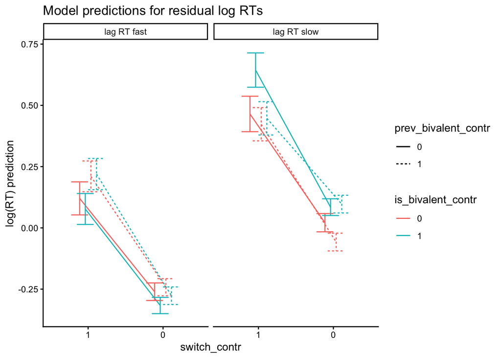

```r
ggplot(preds, aes(x = switch_contr, y = emmean, color = is_bivalent_contr, linetype = prev_bivalent_contr, group = interaction(is_bivalent_contr, prev_bivalent_contr)))+
  geom_line(position = pos)+
  geom_errorbar(aes(ymin = asymp.LCL, ymax = asymp.UCL), position = pos)+
  scale_x_discrete(limits = c("1", "0"))+
  facet_wrap(~speed, labeller = labeller(speed = c("slow" = "lag RT slow",
                                                   "fast" = "lag RT fast")))+
  labs(title = "Model predictions for residual log RTs",
       y = "log(RT) prediction")+
  theme_classic()
```

#### 7.2.2.1 Publication Figure

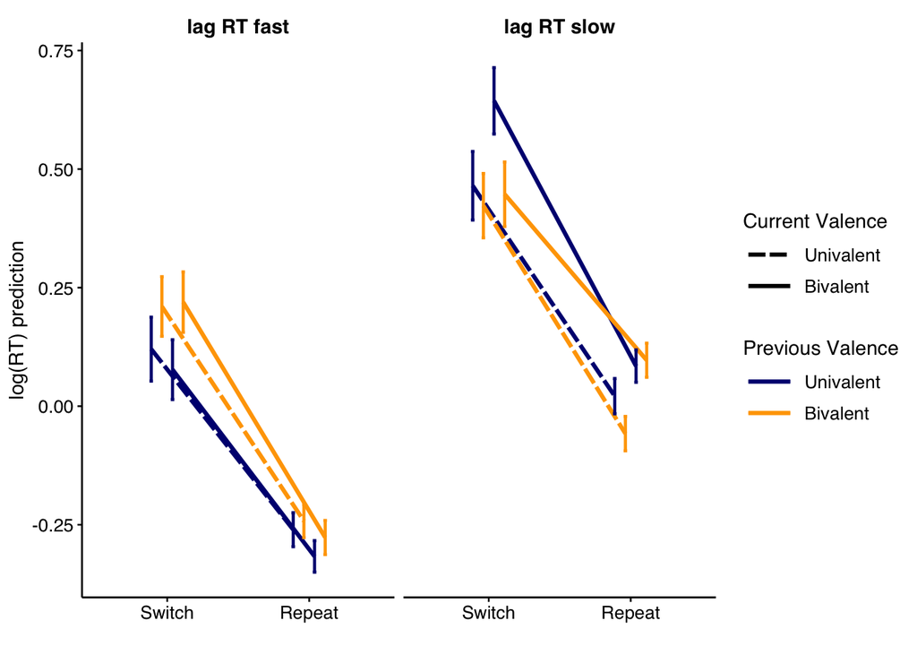

```r
plt_RTlog <- ggplot(preds, aes(x = switch_contr, y = emmean, color = prev_bivalent_contr, linetype = is_bivalent_contr, group = interaction(prev_bivalent_contr, is_bivalent_contr)))+
  geom_line(position = pos, linewidth = design$lines$linewidth)+
  geom_errorbar(aes(ymin = asymp.LCL, ymax = asymp.UCL),
                width = design$errorbar$width,
                position = pos,
                linewidth = design$errorbar$linewidth,
                linetype = "solid")+
  scale_color_manual(name = "Previous Valence",
                     labels = c("0" = "Univalent",
                                "1" = "Bivalent"),
                     values = c("0" = design$curr_val$color$uni,
                                "1" = design$curr_val$color$bi))+
  scale_linetype_manual(name = "Current Valence",
                        labels = c("0" = "Univalent",
                                   "1" = "Bivalent"),
                        values = c("0" = design$curr_val$linetype$uni,
                                   "1" = design$curr_val$linetype$bi))+
  scale_x_discrete(limits = c("1", "0"), labels = c("1" = "Switch", "0" = "Repeat"))+
  facet_wrap(~speed, labeller = labeller(speed = c("slow" = "lag RT slow",
                                                   "fast" = "lag RT fast")))+
  labs(x = "", y = "log(RT) prediction")+
  guides(
    linetype = guide_legend(order = 1),  # appears first
    color    = guide_legend(order = 2)   # appears second
  )

plt_RTlog
```

```r
ggsave(plot = plt_RTlog, "figures/AR_lagRT.svg", height = 5, width = 7.5, units = "in")
saveRDS(plt_RTlog, "figures/AR_lagRT.RDS")
```

## 7.3 Helmert-coded cycle variable (we decided to skip!)

### 7.3.1 Effect coded valence (-0.5, 0.5)

#### 7.3.1.1 Removed subject intercepts

```r
alt_run_rt_log_resrt_prev_helmert_eff <- xfun::cache_rds({
  lmer(time_log_res ~ is_bivalent_eff * prev_bivalent_eff * lag1_time_log_res * cycle_helmert + (is_bivalent_eff + prev_bivalent_eff + lag1_time_log_res + cycle_helmert | id), control = lmerControl(optimizer = "bobyqa"),
       alt_run %>%
         filter(filter_correct == 0))
}, dir = "dominik/models/", file = "alt_run_rt_log_resrt_prev_helmert_eff.RDS", rerun = rerun_all)



make_model_table(alt_run_rt_log_resrt_prev_helmert_eff)

preds <- emmeans::emmeans(alt_run_rt_log_resrt_prev_helmert_eff, ~ is_bivalent_eff * prev_bivalent_eff * lag1_time_log_res * cycle_helmert, type = "response",
                          at = list(is_bivalent_eff = factor(c(0, 1)),
                                    prev_bivalent_eff = factor(c(0, 1)),
                                    cycle_helmert = factor(c(1, 2, 3)),
                                    lag1_time_log_res = c(-1.5, 1.5))) %>%
  as.data.frame() %>%
  mutate(speed = case_when(lag1_time_log_res == min(lag1_time_log_res) ~ "fast",
                           lag1_time_log_res == max(lag1_time_log_res) ~ "slow") %>% factor())



ggplot(preds, aes(x = cycle_helmert, y = emmean, color = is_bivalent_eff, linetype = prev_bivalent_eff, group = interaction(is_bivalent_eff, prev_bivalent_eff)))+
  geom_line(position = pos)+
  geom_errorbar(aes(ymin = asymp.LCL, ymax = asymp.UCL), position = pos)+
  #scale_x_discrete(limits = c("1", "0"))+
  facet_wrap(~speed, labeller = labeller(speed = c("slow" = "lag RT slow",
                                                   "fast" = "lag RT fast")))+
  labs(title = "Model predictions for residual log RTs",
       y = "log(RT) prediction")+
  theme_classic()
```

#### 7.3.1.2 Added subject intercepts

```r
alt_run_rt_log_resrt_prev_helmert_eff_w_s_int <- xfun::cache_rds({
  lmer(time_log_res_w_s_int_c ~ is_bivalent_eff * prev_bivalent_eff * lag1_time_log_res_w_s_int_c * cycle_helmert + (is_bivalent_eff + prev_bivalent_eff + lag1_time_log_res_w_s_int_c + cycle_helmert | id), control = lmerControl(optimizer = "bobyqa"),
       alt_run %>%
         filter(filter_correct == 0))
}, dir = "dominik/models/", file = "alt_run_rt_log_resrt_prev_helmert_eff_w_s_int.RDS", rerun = rerun_all)

make_model_table(alt_run_rt_log_resrt_prev_helmert_eff_w_s_int)

preds <- emmeans::emmeans(alt_run_rt_log_resrt_prev_helmert_eff_w_s_int, ~ is_bivalent_eff * prev_bivalent_eff * lag1_time_log_res_w_s_int_c * cycle_helmert, type = "response",
                          at = list(is_bivalent_eff = factor(c(0, 1)),
                                    prev_bivalent_eff = factor(c(0, 1)),
                                    cycle_helmert = factor(c(1, 2, 3)),
                                    lag1_time_log_res_w_s_int_c = c(-1.5, 1.5))) %>%
  as.data.frame() %>%
  mutate(speed = case_when(lag1_time_log_res_w_s_int_c == min(lag1_time_log_res_w_s_int_c) ~ "fast",
                           lag1_time_log_res_w_s_int_c == max(lag1_time_log_res_w_s_int_c) ~ "slow") %>% factor())



ggplot(preds, aes(x = cycle_helmert, y = emmean, color = is_bivalent_eff, linetype = prev_bivalent_eff, group = interaction(is_bivalent_eff, prev_bivalent_eff)))+
  geom_line(position = pos)+
  geom_errorbar(aes(ymin = asymp.LCL, ymax = asymp.UCL), position = pos)+
  #scale_x_discrete(limits = c("1", "0"))+
  facet_wrap(~speed, labeller = labeller(speed = c("slow" = "lag RT slow",
                                                   "fast" = "lag RT fast")))+
  labs(title = "Model predictions for residual log RTs",
       y = "log(RT) prediction")+
  theme_classic()
```

### 7.3.2 contrast coded valence (0, 1)

#### 7.3.2.1 Removed subject intercepts

```r
alt_run_rt_log_resrt_prev_helmert_contr <- xfun::cache_rds({
  lmer(time_log_res ~ is_bivalent_contr * prev_bivalent_contr * lag1_time_log_res * cycle_helmert + (is_bivalent_contr + prev_bivalent_contr + lag1_time_log_res + cycle_helmert | id), control = lmerControl(optimizer = "bobyqa"),
       alt_run %>%
         filter(filter_correct == 0))

}, dir = "dominik/models/", file = "alt_run_rt_log_resrt_prev_helmert_contr.RDS", rerun = rerun_all)


make_model_table(alt_run_rt_log_resrt_prev_helmert_contr)



preds <- emmeans::emmeans(alt_run_rt_log_resrt_prev_helmert_contr, ~ is_bivalent_contr * prev_bivalent_contr * cycle_helmert * lag1_time_log_res, type = "response",
                          at = list(is_bivalent_contr = factor(c(0, 1)),
                                    prev_bivalent_contr = factor(c(0, 1)),
                                    cycle_helmert = factor(c(1, 2, 3)),
                                    lag1_time_log_res = c(-1.5, 1.5))) %>%
  as.data.frame() %>%
  mutate(speed = case_when(lag1_time_log_res == min(lag1_time_log_res) ~ "fast",
                           lag1_time_log_res == max(lag1_time_log_res) ~ "slow") %>% factor())



ggplot(preds, aes(x = cycle_helmert, y = emmean, color = is_bivalent_contr, linetype = prev_bivalent_contr, group = interaction(is_bivalent_contr, prev_bivalent_contr)))+
  geom_line(position = pos)+
  geom_errorbar(aes(ymin = asymp.LCL, ymax = asymp.UCL), position = pos)+
  #scale_x_discrete(limits = c("1", "0"))+
  facet_wrap(~speed, labeller = labeller(speed = c("slow" = "lag RT slow",
                                                   "fast" = "lag RT fast")))+
  labs(title = "Model predictions for residual log RTs",
       y = "log(RT) prediction")+
  theme_classic()
```

#### 7.3.2.2 Added subject intercepts

```r
alt_run_rt_log_resrt_prev_helmert_contr_w_s_int <- xfun::cache_rds({
  lmer(time_log_res_w_s_int_c ~ is_bivalent_contr * prev_bivalent_contr * lag1_time_log_res_w_s_int_c * cycle_helmert + (is_bivalent_contr + prev_bivalent_contr + lag1_time_log_res_w_s_int_c + cycle_helmert | id), control = lmerControl(optimizer = "bobyqa"),
       alt_run %>%
         filter(filter_correct == 0))
}, dir = "dominik/models/", file = "alt_run_rt_log_resrt_prev_helmert_contr_w_s_int.RDS", rerun = rerun_all)


make_model_table(alt_run_rt_log_resrt_prev_helmert_contr_w_s_int)



preds <- emmeans::emmeans(alt_run_rt_log_resrt_prev_helmert_contr_w_s_int, ~ is_bivalent_contr * prev_bivalent_contr * cycle_helmert * lag1_time_log_res_w_s_int_c, type = "response",
                          at = list(is_bivalent_contr = factor(c(0, 1)),
                                    prev_bivalent_contr = factor(c(0, 1)),
                                    cycle_helmert = factor(c(1, 2, 3)),
                                    lag1_time_log_res_w_s_int_c = c(-1.5, 1.5))) %>%
  as.data.frame() %>%
  mutate(speed = case_when(lag1_time_log_res_w_s_int_c == min(lag1_time_log_res_w_s_int_c) ~ "fast",
                           lag1_time_log_res_w_s_int_c == max(lag1_time_log_res_w_s_int_c) ~ "slow") %>% factor())



ggplot(preds, aes(x = cycle_helmert, y = emmean, color = is_bivalent_contr, linetype = prev_bivalent_contr, group = interaction(is_bivalent_contr, prev_bivalent_contr)))+
  geom_line(position = pos)+
  geom_errorbar(aes(ymin = asymp.LCL, ymax = asymp.UCL), position = pos)+
  #scale_x_discrete(limits = c("1", "0"))+
  facet_wrap(~speed, labeller = labeller(speed = c("slow" = "lag RT slow",
                                                   "fast" = "lag RT fast")))+
  labs(title = "Model predictions for residual log RTs",
       y = "log(RT) prediction")+
  theme_classic()
```

# 8 Individual differences analysis

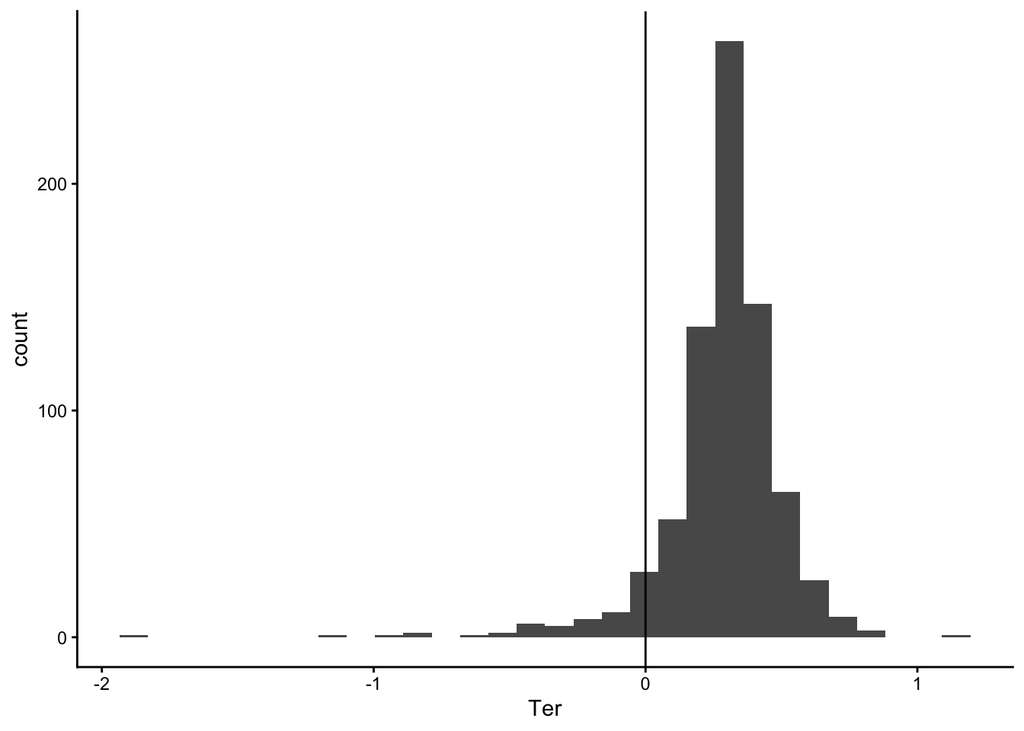

```r
alt_run_indiv <- alt_run_agg_ID_ddm_nocycle %>%
  pivot_wider(id_cols = id, names_from = c(is_bivalent_contr, prev_bivalent_contr, switch_contr),
              values_from = c(v, a, Ter, RT_log, Error),
              names_glue = "{.value}_s{switch_contr}_cbiv{is_bivalent_contr}_lbiv{prev_bivalent_contr}") %>%
  ungroup() %>%
  mutate(v_s0_cbiv0_lbiv0_NA = ifelse(Ter_s0_cbiv0_lbiv0 < 0, NA, v_s0_cbiv0_lbiv0),
         v_s0_cbiv0_lbiv1_NA = ifelse(Ter_s0_cbiv0_lbiv1 < 0, NA, v_s0_cbiv0_lbiv1),
         v_s0_cbiv1_lbiv0_NA = ifelse(Ter_s0_cbiv1_lbiv0 < 0, NA, v_s0_cbiv1_lbiv0),
         v_s0_cbiv1_lbiv1_NA = ifelse(Ter_s0_cbiv1_lbiv1 < 0, NA, v_s0_cbiv1_lbiv1),
         v_s1_cbiv0_lbiv0_NA = ifelse(Ter_s1_cbiv0_lbiv0 < 0, NA, v_s1_cbiv0_lbiv0),
         v_s1_cbiv0_lbiv1_NA = ifelse(Ter_s1_cbiv0_lbiv1 < 0, NA, v_s1_cbiv0_lbiv1),
         v_s1_cbiv1_lbiv0_NA = ifelse(Ter_s1_cbiv1_lbiv0 < 0, NA, v_s1_cbiv1_lbiv0),
         v_s1_cbiv1_lbiv1_NA = ifelse(Ter_s1_cbiv1_lbiv1 < 0, NA, v_s1_cbiv1_lbiv1))



alt_run_agg_ID_ddm_nocycle %>%
  ggplot(aes(x = Ter))+
  geom_histogram()+
  geom_vline(xintercept = 0)+
  theme_classic()
```

```r
alt_run_agg_ID_ddm_nocycle %>%
  ungroup() %>%
  summarize(N = n(),
            neg_ter = sum(Ter < 0),
            p_neg_Ter = neg_ter/N,
            subjects_w_any_neg_Ter = length(unique(id[Ter < 0])))
```

```
## # A tibble: 1 × 4
##       N neg_ter p_neg_Ter subjects_w_any_neg_Ter
##   <int>   <int>     <dbl>                  <int>
## 1   768      51    0.0664                     29
```

```r
alt_run_indiv <- alt_run_indiv %>%
  mutate(across(!id, ~ as.vector(scale(.x))))
```

## 8.1 Models

```r
alt_run_indiv_diff_models <- list(
  RT = list(
    uu0 = lm(RT_log_s1_cbiv0_lbiv0 ~ 1, alt_run_indiv),
    uu1 = lm(RT_log_s1_cbiv0_lbiv0 ~ RT_log_s0_cbiv0_lbiv0, alt_run_indiv),
    uu2 = lm(RT_log_s1_cbiv0_lbiv0 ~ RT_log_s0_cbiv0_lbiv0 + RT_log_s0_cbiv0_lbiv1, alt_run_indiv),
    uu3 = lm(RT_log_s1_cbiv0_lbiv0 ~ RT_log_s0_cbiv0_lbiv0 + RT_log_s0_cbiv0_lbiv1 + RT_log_s0_cbiv1_lbiv0, alt_run_indiv),
    uu4 = lm(RT_log_s1_cbiv0_lbiv0 ~ RT_log_s0_cbiv0_lbiv0 + RT_log_s0_cbiv0_lbiv1 + RT_log_s0_cbiv1_lbiv0 + RT_log_s0_cbiv1_lbiv1, alt_run_indiv),

    bu0 = lm(RT_log_s1_cbiv1_lbiv0 ~ 1, alt_run_indiv),
    bu1 = lm(RT_log_s1_cbiv1_lbiv0 ~ RT_log_s0_cbiv0_lbiv0, alt_run_indiv),
    bu2 = lm(RT_log_s1_cbiv1_lbiv0 ~ RT_log_s0_cbiv0_lbiv0 + RT_log_s0_cbiv0_lbiv1, alt_run_indiv),
    bu3 = lm(RT_log_s1_cbiv1_lbiv0 ~ RT_log_s0_cbiv0_lbiv0 + RT_log_s0_cbiv0_lbiv1 + RT_log_s0_cbiv1_lbiv0, alt_run_indiv),
    bu4 = lm(RT_log_s1_cbiv1_lbiv0 ~ RT_log_s0_cbiv0_lbiv0 + RT_log_s0_cbiv0_lbiv1 + RT_log_s0_cbiv1_lbiv0 + RT_log_s0_cbiv1_lbiv1, alt_run_indiv),

    ub0 = lm(RT_log_s1_cbiv0_lbiv1 ~ 1, alt_run_indiv),
    ub1 = lm(RT_log_s1_cbiv0_lbiv1 ~ RT_log_s0_cbiv0_lbiv0, alt_run_indiv),
    ub2 = lm(RT_log_s1_cbiv0_lbiv1 ~ RT_log_s0_cbiv0_lbiv0 + RT_log_s0_cbiv0_lbiv1, alt_run_indiv),
    ub3 = lm(RT_log_s1_cbiv0_lbiv1 ~ RT_log_s0_cbiv0_lbiv0 + RT_log_s0_cbiv0_lbiv1 + RT_log_s0_cbiv1_lbiv0, alt_run_indiv),
    ub4 = lm(RT_log_s1_cbiv0_lbiv1 ~ RT_log_s0_cbiv0_lbiv0 + RT_log_s0_cbiv0_lbiv1 + RT_log_s0_cbiv1_lbiv0 + RT_log_s0_cbiv1_lbiv1, alt_run_indiv),

    bb0 = lm(RT_log_s1_cbiv1_lbiv1 ~ 1, alt_run_indiv),
    bb1 = lm(RT_log_s1_cbiv1_lbiv1 ~ RT_log_s0_cbiv0_lbiv0, alt_run_indiv),
    bb2 = lm(RT_log_s1_cbiv1_lbiv1 ~ RT_log_s0_cbiv0_lbiv0 + RT_log_s0_cbiv0_lbiv1, alt_run_indiv),
    bb3 = lm(RT_log_s1_cbiv1_lbiv1 ~ RT_log_s0_cbiv0_lbiv0 + RT_log_s0_cbiv0_lbiv1 + RT_log_s0_cbiv1_lbiv0, alt_run_indiv),
    bb4 = lm(RT_log_s1_cbiv1_lbiv1 ~ RT_log_s0_cbiv0_lbiv0 + RT_log_s0_cbiv0_lbiv1 + RT_log_s0_cbiv1_lbiv0 + RT_log_s0_cbiv1_lbiv1, alt_run_indiv)
  ),


  Error = list(
    uu1 = lm(Error_s1_cbiv0_lbiv0 ~ 1, alt_run_indiv),
    uu1 = lm(Error_s1_cbiv0_lbiv0 ~ Error_s0_cbiv0_lbiv0, alt_run_indiv),
    uu2 = lm(Error_s1_cbiv0_lbiv0 ~ Error_s0_cbiv0_lbiv0 + Error_s0_cbiv0_lbiv1, alt_run_indiv),
    uu3 = lm(Error_s1_cbiv0_lbiv0 ~ Error_s0_cbiv0_lbiv0 + Error_s0_cbiv0_lbiv1 + Error_s0_cbiv1_lbiv0, alt_run_indiv),
    uu4 = lm(Error_s1_cbiv0_lbiv0 ~ Error_s0_cbiv0_lbiv0 + Error_s0_cbiv0_lbiv1 + Error_s0_cbiv1_lbiv0 + Error_s0_cbiv1_lbiv1, alt_run_indiv),

    bu0 = lm(Error_s1_cbiv1_lbiv0 ~ 1, alt_run_indiv),
    bu1 = lm(Error_s1_cbiv1_lbiv0 ~ Error_s0_cbiv0_lbiv0, alt_run_indiv),
    bu2 = lm(Error_s1_cbiv1_lbiv0 ~ Error_s0_cbiv0_lbiv0 + Error_s0_cbiv0_lbiv1, alt_run_indiv),
    bu3 = lm(Error_s1_cbiv1_lbiv0 ~ Error_s0_cbiv0_lbiv0 + Error_s0_cbiv0_lbiv1 + Error_s0_cbiv1_lbiv0, alt_run_indiv),
    bu4 = lm(Error_s1_cbiv1_lbiv0 ~ Error_s0_cbiv0_lbiv0 + Error_s0_cbiv0_lbiv1 + Error_s0_cbiv1_lbiv0 + Error_s0_cbiv1_lbiv1, alt_run_indiv),

    ub0 = lm(Error_s1_cbiv0_lbiv1 ~ 1, alt_run_indiv),
    ub1 = lm(Error_s1_cbiv0_lbiv1 ~ Error_s0_cbiv0_lbiv0, alt_run_indiv),
    ub2 = lm(Error_s1_cbiv0_lbiv1 ~ Error_s0_cbiv0_lbiv0 + Error_s0_cbiv0_lbiv1, alt_run_indiv),
    ub3 = lm(Error_s1_cbiv0_lbiv1 ~ Error_s0_cbiv0_lbiv0 + Error_s0_cbiv0_lbiv1 + Error_s0_cbiv1_lbiv0, alt_run_indiv),
    ub4 = lm(Error_s1_cbiv0_lbiv1 ~ Error_s0_cbiv0_lbiv0 + Error_s0_cbiv0_lbiv1 + Error_s0_cbiv1_lbiv0 + Error_s0_cbiv1_lbiv1, alt_run_indiv),

    bb0 = lm(Error_s1_cbiv1_lbiv1 ~ 1, alt_run_indiv),
    bb1 = lm(Error_s1_cbiv1_lbiv1 ~ Error_s0_cbiv0_lbiv0, alt_run_indiv),
    bb2 = lm(Error_s1_cbiv1_lbiv1 ~ Error_s0_cbiv0_lbiv0 + Error_s0_cbiv0_lbiv1, alt_run_indiv),
    bb3 = lm(Error_s1_cbiv1_lbiv1 ~ Error_s0_cbiv0_lbiv0 + Error_s0_cbiv0_lbiv1 + Error_s0_cbiv1_lbiv0, alt_run_indiv),
    bb4 = lm(Error_s1_cbiv1_lbiv1 ~ Error_s0_cbiv0_lbiv0 + Error_s0_cbiv0_lbiv1 + Error_s0_cbiv1_lbiv0 + Error_s0_cbiv1_lbiv1, alt_run_indiv)
  ),

  v = list(

    uu0 = lm(v_s1_cbiv0_lbiv0 ~ 1, alt_run_indiv),
    uu1 = lm(v_s1_cbiv0_lbiv0 ~ v_s0_cbiv0_lbiv0, alt_run_indiv),
    uu2 = lm(v_s1_cbiv0_lbiv0 ~ v_s0_cbiv0_lbiv0 + v_s0_cbiv0_lbiv1, alt_run_indiv),
    uu3 = lm(v_s1_cbiv0_lbiv0 ~ v_s0_cbiv0_lbiv0 + v_s0_cbiv0_lbiv1 + v_s0_cbiv1_lbiv0, alt_run_indiv),
    uu4 = lm(v_s1_cbiv0_lbiv0 ~ v_s0_cbiv0_lbiv0 + v_s0_cbiv0_lbiv1 + v_s0_cbiv1_lbiv0 + v_s0_cbiv1_lbiv1, alt_run_indiv),

    bu0 = lm(v_s1_cbiv1_lbiv0 ~ 1, alt_run_indiv),
    bu1 = lm(v_s1_cbiv1_lbiv0 ~ v_s0_cbiv0_lbiv0, alt_run_indiv),
    bu2 = lm(v_s1_cbiv1_lbiv0 ~ v_s0_cbiv0_lbiv0 + v_s0_cbiv0_lbiv1, alt_run_indiv),
    bu3 = lm(v_s1_cbiv1_lbiv0 ~ v_s0_cbiv0_lbiv0 + v_s0_cbiv0_lbiv1 + v_s0_cbiv1_lbiv0, alt_run_indiv),
    bu4 = lm(v_s1_cbiv1_lbiv0 ~ v_s0_cbiv0_lbiv0 + v_s0_cbiv0_lbiv1 + v_s0_cbiv1_lbiv0 + v_s0_cbiv1_lbiv1, alt_run_indiv),

    ub0 = lm(v_s1_cbiv0_lbiv1 ~ 1, alt_run_indiv),
    ub1 = lm(v_s1_cbiv0_lbiv1 ~ v_s0_cbiv0_lbiv0, alt_run_indiv),
    ub2 = lm(v_s1_cbiv0_lbiv1 ~ v_s0_cbiv0_lbiv0 + v_s0_cbiv0_lbiv1, alt_run_indiv),
    ub3 = lm(v_s1_cbiv0_lbiv1 ~ v_s0_cbiv0_lbiv0 + v_s0_cbiv0_lbiv1 + v_s0_cbiv1_lbiv0, alt_run_indiv),
    ub4 = lm(v_s1_cbiv0_lbiv1 ~ v_s0_cbiv0_lbiv0 + v_s0_cbiv0_lbiv1 + v_s0_cbiv1_lbiv0 + v_s0_cbiv1_lbiv1, alt_run_indiv),

    bb0 = lm(v_s1_cbiv1_lbiv1 ~ 1, alt_run_indiv),
    bb1 = lm(v_s1_cbiv1_lbiv1 ~ v_s0_cbiv0_lbiv0, alt_run_indiv),
    bb2 = lm(v_s1_cbiv1_lbiv1 ~ v_s0_cbiv0_lbiv0 + v_s0_cbiv0_lbiv1, alt_run_indiv),
    bb3 = lm(v_s1_cbiv1_lbiv1 ~ v_s0_cbiv0_lbiv0 + v_s0_cbiv0_lbiv1 + v_s0_cbiv1_lbiv0, alt_run_indiv),
    bb4 = lm(v_s1_cbiv1_lbiv1 ~ v_s0_cbiv0_lbiv0 + v_s0_cbiv0_lbiv1 + v_s0_cbiv1_lbiv0 + v_s0_cbiv1_lbiv1, alt_run_indiv)
  ),
  v_NA = list(

    uu0 = lm(v_s1_cbiv0_lbiv0_NA ~ 1, alt_run_indiv),
    uu1 = lm(v_s1_cbiv0_lbiv0_NA ~ v_s0_cbiv0_lbiv0_NA, alt_run_indiv),
    uu2 = lm(v_s1_cbiv0_lbiv0_NA ~ v_s0_cbiv0_lbiv0_NA + v_s0_cbiv0_lbiv1_NA, alt_run_indiv),
    uu3 = lm(v_s1_cbiv0_lbiv0_NA ~ v_s0_cbiv0_lbiv0_NA + v_s0_cbiv0_lbiv1_NA + v_s0_cbiv1_lbiv0_NA, alt_run_indiv),
    uu4 = lm(v_s1_cbiv0_lbiv0_NA ~ v_s0_cbiv0_lbiv0_NA + v_s0_cbiv0_lbiv1_NA + v_s0_cbiv1_lbiv0_NA + v_s0_cbiv1_lbiv1_NA, alt_run_indiv),

    bu0 = lm(v_s1_cbiv1_lbiv0_NA ~ 1, alt_run_indiv),
    bu1 = lm(v_s1_cbiv1_lbiv0_NA ~ v_s0_cbiv0_lbiv0_NA, alt_run_indiv),
    bu2 = lm(v_s1_cbiv1_lbiv0_NA ~ v_s0_cbiv0_lbiv0_NA + v_s0_cbiv0_lbiv1_NA, alt_run_indiv),
    bu3 = lm(v_s1_cbiv1_lbiv0_NA ~ v_s0_cbiv0_lbiv0_NA + v_s0_cbiv0_lbiv1_NA + v_s0_cbiv1_lbiv0_NA, alt_run_indiv),
    bu4 = lm(v_s1_cbiv1_lbiv0_NA ~ v_s0_cbiv0_lbiv0_NA + v_s0_cbiv0_lbiv1_NA + v_s0_cbiv1_lbiv0_NA + v_s0_cbiv1_lbiv1_NA, alt_run_indiv),

    ub0 = lm(v_s1_cbiv0_lbiv1_NA ~ 1, alt_run_indiv),
    ub1 = lm(v_s1_cbiv0_lbiv1_NA ~ v_s0_cbiv0_lbiv0_NA, alt_run_indiv),
    ub2 = lm(v_s1_cbiv0_lbiv1_NA ~ v_s0_cbiv0_lbiv0_NA + v_s0_cbiv0_lbiv1_NA, alt_run_indiv),
    ub3 = lm(v_s1_cbiv0_lbiv1_NA ~ v_s0_cbiv0_lbiv0_NA + v_s0_cbiv0_lbiv1_NA + v_s0_cbiv1_lbiv0_NA, alt_run_indiv),
    ub4 = lm(v_s1_cbiv0_lbiv1_NA ~ v_s0_cbiv0_lbiv0_NA + v_s0_cbiv0_lbiv1_NA + v_s0_cbiv1_lbiv0_NA + v_s0_cbiv1_lbiv1_NA, alt_run_indiv),

    bb0 = lm(v_s1_cbiv1_lbiv1_NA ~ 1, alt_run_indiv),
    bb1 = lm(v_s1_cbiv1_lbiv1_NA ~ v_s0_cbiv0_lbiv0_NA, alt_run_indiv),
    bb2 = lm(v_s1_cbiv1_lbiv1_NA ~ v_s0_cbiv0_lbiv0_NA + v_s0_cbiv0_lbiv1_NA, alt_run_indiv),
    bb3 = lm(v_s1_cbiv1_lbiv1_NA ~ v_s0_cbiv0_lbiv0_NA + v_s0_cbiv0_lbiv1_NA + v_s0_cbiv1_lbiv0_NA, alt_run_indiv),
    bb4 = lm(v_s1_cbiv1_lbiv1_NA ~ v_s0_cbiv0_lbiv0_NA + v_s0_cbiv0_lbiv1_NA + v_s0_cbiv1_lbiv0_NA + v_s0_cbiv1_lbiv1_NA, alt_run_indiv)
  )
)

summary(alt_run_indiv_diff_models$RT$uu4)
```

```
##
## Call:
## lm(formula = RT_log_s1_cbiv0_lbiv0 ~ RT_log_s0_cbiv0_lbiv0 +
##     RT_log_s0_cbiv0_lbiv1 + RT_log_s0_cbiv1_lbiv0 + RT_log_s0_cbiv1_lbiv1,
##     data = alt_run_indiv)
##
## Residuals:
##     Min      1Q  Median      3Q     Max
## -1.2821 -0.4259 -0.1032  0.3252  1.6485
##
## Coefficients:
##                         Estimate Std. Error t value Pr(>|t|)
## (Intercept)           -1.389e-14  6.733e-02   0.000    1.000
## RT_log_s0_cbiv0_lbiv0  6.360e-01  1.251e-01   5.083 1.97e-06 ***
## RT_log_s0_cbiv0_lbiv1  3.474e-02  1.923e-01   0.181    0.857
## RT_log_s0_cbiv1_lbiv0  7.524e-02  2.092e-01   0.360    0.720
## RT_log_s0_cbiv1_lbiv1  4.650e-02  1.193e-01   0.390    0.698
## ---
## Signif. codes:  0 '***' 0.001 '**' 0.01 '*' 0.05 '.' 0.1 ' ' 1
##
## Residual standard error: 0.6597 on 91 degrees of freedom
## Multiple R-squared:  0.5832, Adjusted R-squared:  0.5649
## F-statistic: 31.83 on 4 and 91 DF,  p-value: < 2.2e-16
```

## 8.2 RT

```r
RT_comparisons <- lapply(c("uu", "bu", "ub", "bb"), function(x){

  data.frame(model = compare_models(alt_run_indiv_diff_models$RT, x)$model_names,
             comparison_p = compare_models(alt_run_indiv_diff_models$RT, x)$comparison$`Pr(>F)`)

}) %>%
  bind_rows() %>%
  mutate(comparison_sig = ifelse(comparison_p < 0.05, 1, 0))


alt_run_RT_model_summary <- lapply(alt_run_indiv_diff_models$RT, function(x){
  m_sum <- x %>%
    summary()

  m_sum %>%
    coef() %>%
    as.data.frame() %>%
    mutate(r_sq = m_sum$r.squared,
           r_sq_adj = m_sum$adj.r.squared)


}) %>%
  bind_rows(.id = "model") %>%
  rownames_to_column("coefficient") %>%
  janitor::clean_names() %>%
  left_join(RT_comparisons) %>%
  filter(!grepl("(Intercept)", coefficient)) %>%
  mutate(coefficient = gsub("\\...[[:digit:]]+", "", coefficient),
         coefficient = gsub("RT_log_", "", coefficient),
         outcome = gsub("[[:digit:]]", "", model),
         outcome = factor(outcome, levels = c("uu", "ub", "bu", "bb")),
         is_sig = ifelse(pr_t < 0.05, 1, 0),
         # r_label = as.character(round(r_sq, 2)),
         # r_label = gsub("^0.", ".", r_label),
         r_label = sprintf("%.2f", r_sq),
         r_label = case_when(comparison_sig == 1 ~ paste0(r_label, "*"), .default = r_label),
         r_adj_label = sprintf("%.2f", r_sq_adj),
         r_adj_label = case_when(comparison_sig == 1 ~ paste0(r_adj_label, "*"), .default = r_adj_label),
         color = parse_number(model) %>% factor())
```

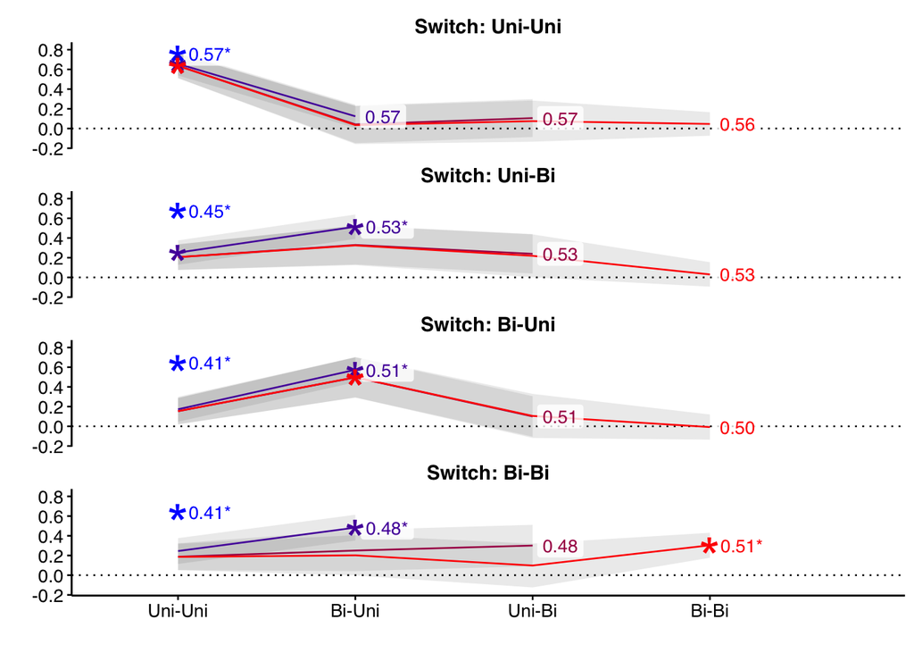

```r
n = 4
plt_betw_RT <- ggplot(alt_run_RT_model_summary, aes(x = coefficient, y = estimate, group = model, color = color))+
  geom_hline(yintercept = 0, linetype = "dotted")+
  geom_ribbon(aes(ymin = estimate - std_error,
                  ymax = estimate + std_error), alpha = 0.1, color = NA)+
  geom_line()+
  # geom_text(data = alt_run_RT_model_summary %>% group_by(model) %>% slice(n()),
  #           aes(label = r_adj_label), hjust = -0.3)+
  geom_label(data = alt_run_RT_model_summary %>% group_by(model) %>% slice(n()),
            aes(label = r_adj_label), hjust = -0.1, alpha = 0.8, label.size = 0)+
  geom_point(data = alt_run_RT_model_summary %>% filter(is_sig == 1), pch = "*", size = 10)+
   labs(x = "",
       y = "")+
  facet_wrap(~outcome, labeller = labeller(outcome = c("uu" = "Switch: Uni-Uni",
                                                       "ub" = "Switch: Uni-Bi",
                                                       "bu" = "Switch: Bi-Uni",
                                                       "bb" = "Switch: Bi-Bi")), ncol = 1)+
  scale_color_manual(values = colorRampPalette(c("blue", "red"))(n))+
  scale_x_discrete(labels = c("s0_cbiv0_lbiv1" = "Bi-Uni",
                              "s0_cbiv1_lbiv1" = "Bi-Bi",
                              "s0_cbiv0_lbiv0" = "Uni-Uni",
                              "s0_cbiv1_lbiv0" = "Uni-Bi",
                              "(Intercept)" = "Int"))+
  coord_cartesian(xlim = c(1, 4.5))+
  theme(legend.position = "none")
plt_betw_RT
```

```r
ggsave(plot = plt_betw_RT, "figures/AR_betw_RT.svg", width = 4, height = 6, units = "in")
saveRDS(plt_betw_RT, file = "figures/AR_betw_RT.RDS")
```

### 8.2.1 Model comp: univalent - univalent

```r
compare_models(alt_run_indiv_diff_models$RT, "uu")$comparison
```

```
## Analysis of Variance Table
##
## Model 1: RT_log_s1_cbiv0_lbiv0 ~ 1
## Model 2: RT_log_s1_cbiv0_lbiv0 ~ RT_log_s0_cbiv0_lbiv0
## Model 3: RT_log_s1_cbiv0_lbiv0 ~ RT_log_s0_cbiv0_lbiv0 + RT_log_s0_cbiv0_lbiv1
## Model 4: RT_log_s1_cbiv0_lbiv0 ~ RT_log_s0_cbiv0_lbiv0 + RT_log_s0_cbiv0_lbiv1 +
##     RT_log_s0_cbiv1_lbiv0
## Model 5: RT_log_s1_cbiv0_lbiv0 ~ RT_log_s0_cbiv0_lbiv0 + RT_log_s0_cbiv0_lbiv1 +
##     RT_log_s0_cbiv1_lbiv0 + RT_log_s0_cbiv1_lbiv1
##   Res.Df    RSS Df Sum of Sq        F Pr(>F)
## 1     95 95.000
## 2     94 40.266  1    54.734 125.7842 <2e-16 ***
## 3     93 39.795  1     0.471   1.0817 0.3011
## 4     92 39.664  1     0.131   0.3019 0.5840
## 5     91 39.598  1     0.066   0.1520 0.6976
## ---
## Signif. codes:  0 '***' 0.001 '**' 0.01 '*' 0.05 '.' 0.1 ' ' 1
```

### 8.2.2 Model comp: univalent - bivalent

```r
compare_models(alt_run_indiv_diff_models$RT, "ub")$comparison
```

```
## Analysis of Variance Table
##
## Model 1: RT_log_s1_cbiv0_lbiv1 ~ 1
## Model 2: RT_log_s1_cbiv0_lbiv1 ~ RT_log_s0_cbiv0_lbiv0
## Model 3: RT_log_s1_cbiv0_lbiv1 ~ RT_log_s0_cbiv0_lbiv0 + RT_log_s0_cbiv0_lbiv1
## Model 4: RT_log_s1_cbiv0_lbiv1 ~ RT_log_s0_cbiv0_lbiv0 + RT_log_s0_cbiv0_lbiv1 +
##     RT_log_s0_cbiv1_lbiv0
## Model 5: RT_log_s1_cbiv0_lbiv1 ~ RT_log_s0_cbiv0_lbiv0 + RT_log_s0_cbiv0_lbiv1 +
##     RT_log_s0_cbiv1_lbiv0 + RT_log_s0_cbiv1_lbiv1
##   Res.Df    RSS Df Sum of Sq       F    Pr(>F)
## 1     95 95.000
## 2     94 51.629  1    43.371 92.0678 1.793e-15 ***
## 3     93 43.562  1     8.067 17.1258 7.797e-05 ***
## 4     92 42.896  1     0.666  1.4143    0.2374
## 5     91 42.867  1     0.028  0.0601    0.8069
## ---
## Signif. codes:  0 '***' 0.001 '**' 0.01 '*' 0.05 '.' 0.1 ' ' 1
```

### 8.2.3 Model comp: bivalent - univalent

```r
compare_models(alt_run_indiv_diff_models$RT, "bu")$comparison
```

```
## Analysis of Variance Table
##
## Model 1: RT_log_s1_cbiv1_lbiv0 ~ 1
## Model 2: RT_log_s1_cbiv1_lbiv0 ~ RT_log_s0_cbiv0_lbiv0
## Model 3: RT_log_s1_cbiv1_lbiv0 ~ RT_log_s0_cbiv0_lbiv0 + RT_log_s0_cbiv0_lbiv1
## Model 4: RT_log_s1_cbiv1_lbiv0 ~ RT_log_s0_cbiv0_lbiv0 + RT_log_s0_cbiv0_lbiv1 +
##     RT_log_s0_cbiv1_lbiv0
## Model 5: RT_log_s1_cbiv1_lbiv0 ~ RT_log_s0_cbiv0_lbiv0 + RT_log_s0_cbiv0_lbiv1 +
##     RT_log_s0_cbiv1_lbiv0 + RT_log_s0_cbiv1_lbiv1
##   Res.Df    RSS Df Sum of Sq       F    Pr(>F)
## 1     95 95.000
## 2     94 55.407  1    39.593 79.6190 4.578e-14 ***
## 3     93 45.372  1    10.035 20.1796 2.065e-05 ***
## 4     92 45.255  1     0.117  0.2351    0.6289
## 5     91 45.253  1     0.002  0.0037    0.9517
## ---
## Signif. codes:  0 '***' 0.001 '**' 0.01 '*' 0.05 '.' 0.1 ' ' 1
```

### 8.2.4 Model comp: bivalent - bivalent

```r
compare_models(alt_run_indiv_diff_models$RT, "bb")$comparison
```

```
## Analysis of Variance Table
##
## Model 1: RT_log_s1_cbiv1_lbiv1 ~ 1
## Model 2: RT_log_s1_cbiv1_lbiv1 ~ RT_log_s0_cbiv0_lbiv0
## Model 3: RT_log_s1_cbiv1_lbiv1 ~ RT_log_s0_cbiv0_lbiv0 + RT_log_s0_cbiv0_lbiv1
## Model 4: RT_log_s1_cbiv1_lbiv1 ~ RT_log_s0_cbiv0_lbiv0 + RT_log_s0_cbiv0_lbiv1 +
##     RT_log_s0_cbiv1_lbiv0
## Model 5: RT_log_s1_cbiv1_lbiv1 ~ RT_log_s0_cbiv0_lbiv0 + RT_log_s0_cbiv0_lbiv1 +
##     RT_log_s0_cbiv1_lbiv0 + RT_log_s0_cbiv1_lbiv1
##   Res.Df    RSS Df Sum of Sq       F    Pr(>F)
## 1     95 95.000
## 2     94 55.708  1    39.292 79.9467 4.191e-14 ***
## 3     93 48.601  1     7.106 14.4589 0.0002589 ***
## 4     92 47.547  1     1.054  2.1452 0.1464604
## 5     91 44.725  1     2.822  5.7425 0.0186052 *
## ---
## Signif. codes:  0 '***' 0.001 '**' 0.01 '*' 0.05 '.' 0.1 ' ' 1
```

## 8.3 Error

```r
Error_comparisons <- lapply(c("uu", "bu", "ub", "bb"), function(x){

  data.frame(model = compare_models(alt_run_indiv_diff_models$Error, x)$model_names,
             comparison_p = compare_models(alt_run_indiv_diff_models$Error, x)$comparison$`Pr(>F)`)

}) %>%
  bind_rows() %>%
  mutate(comparison_sig = ifelse(comparison_p < 0.05, 1, 0))


alt_run_Error_model_summary <- lapply(alt_run_indiv_diff_models$Error, function(x){
  m_sum <- x %>%
    summary()

  m_sum %>%
    coef() %>%
    as.data.frame() %>%
    mutate(r_sq = m_sum$r.squared,
           r_sq_adj = m_sum$adj.r.squared)
}) %>%
  bind_rows(.id = "model") %>%
  rownames_to_column("coefficient") %>%
  janitor::clean_names() %>%
  left_join(Error_comparisons) %>%
  filter(!grepl("(Intercept)", coefficient)) %>%
  mutate(coefficient = gsub("\\...[[:digit:]]+", "", coefficient),
         coefficient = gsub("RT_log_", "", coefficient),
         outcome = gsub("[[:digit:]]", "", model),
         outcome = factor(outcome, levels = c("uu", "ub", "bu", "bb")),
         is_sig = ifelse(pr_t < 0.05, 1, 0),
         # r_label = as.character(round(r_sq, 2)),
         # r_label = gsub("^0.", ".", r_label),
         r_label = sprintf("%.2f", r_sq),
         r_label = case_when(comparison_sig == 1 ~ paste0(r_label, "*"), .default = r_label),
         r_adj_label = sprintf("%.2f", r_sq_adj),
         r_adj_label = case_when(comparison_sig == 1 ~ paste0(r_adj_label, "*"), .default = r_adj_label),
         color = parse_number(model) %>% factor())
```

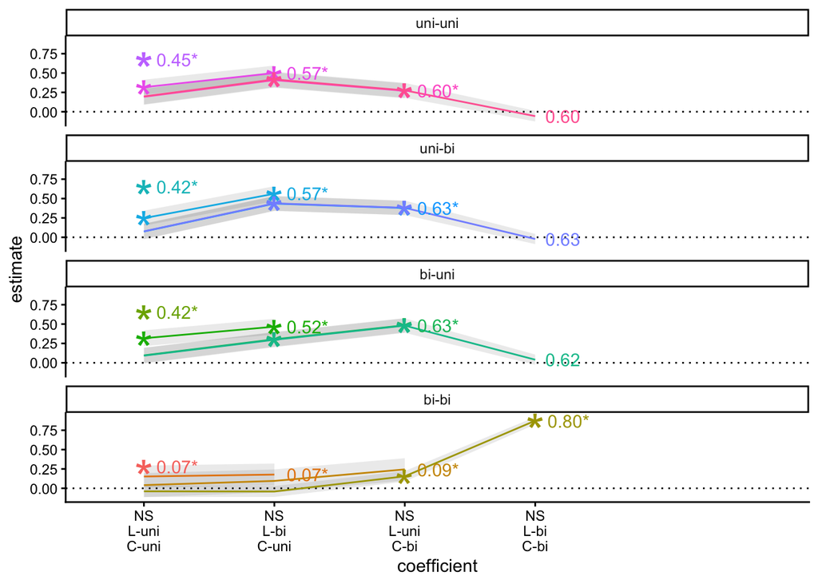

```r
ggplot(alt_run_Error_model_summary, aes(x = coefficient, y = estimate, group = model, color = model))+
  geom_hline(yintercept = 0, linetype = "dotted")+
  geom_ribbon(aes(ymin = estimate - std_error,
                  ymax = estimate + std_error), alpha = 0.1, color = NA)+
  geom_line()+
  geom_text(data = alt_run_Error_model_summary %>% group_by(model) %>% slice(n()),
            aes(label = r_adj_label), hjust = -0.3)+
  geom_point(data = alt_run_Error_model_summary %>% filter(is_sig == 1), pch = "*", size = 10)+
  theme_classic()+
  facet_wrap(~outcome, labeller = labeller(outcome = c("uu" = "uni-uni",
                                                       "ub" = "uni-bi",
                                                       "bu" = "bi-uni",
                                                       "bb" = "bi-bi")), ncol = 1)+
  scale_x_discrete(labels = c("Error_s0_cbiv0_lbiv1" = "NS\nL-bi\nC-uni",
                              "Error_s0_cbiv1_lbiv1" = "NS\nL-bi\nC-bi",
                              "Error_s0_cbiv0_lbiv0" = "NS\nL-uni\nC-uni",
                              "Error_s0_cbiv1_lbiv0" = "NS\nL-uni\nC-bi",
                              "(Intercept)" = "Int"))+
  coord_cartesian(xlim = c(1, 5.5))+
  theme(legend.position = "none")
```

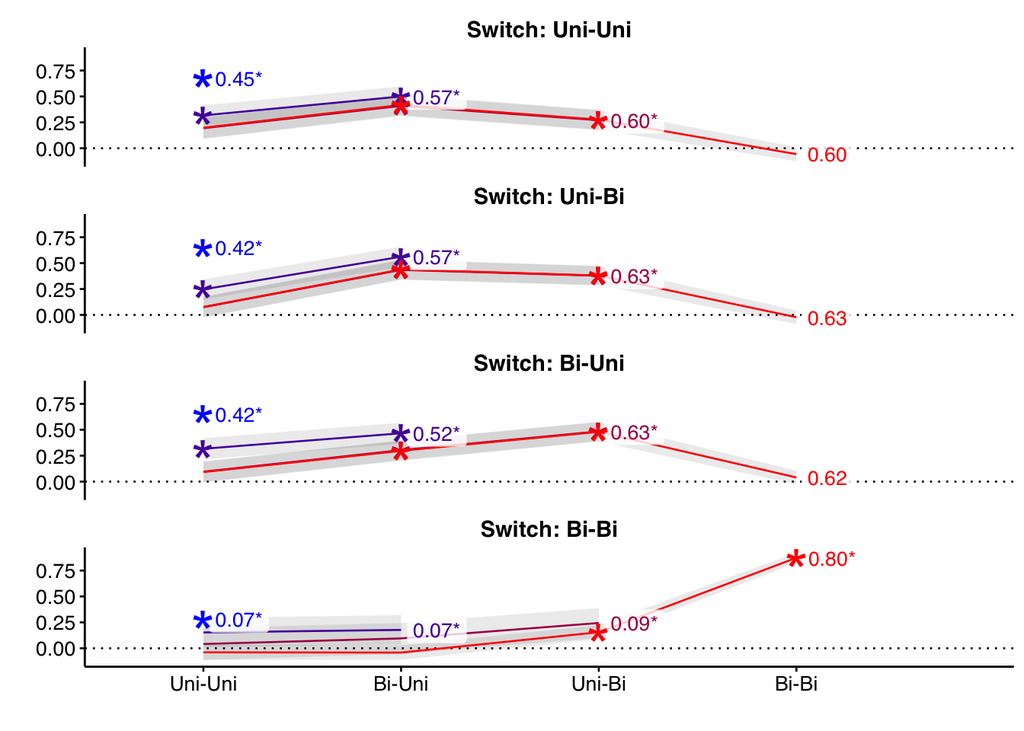

```r
plt_betw_Error <- ggplot(alt_run_Error_model_summary, aes(x = coefficient, y = estimate, group = model, color = color))+
  geom_hline(yintercept = 0, linetype = "dotted")+
  geom_ribbon(aes(ymin = estimate - std_error,
                  ymax = estimate + std_error), alpha = 0.1, color = NA)+
  geom_line()+
  # geom_text(data = alt_run_Error_model_summary %>% group_by(model) %>% slice(n()),
  #           aes(label = r_adj_label), hjust = -0.3)+
  geom_label(data = alt_run_Error_model_summary %>% group_by(model) %>% slice(n()),
            aes(label = r_adj_label), hjust = -0.1, alpha = 0.8, label.size = 0)+
  geom_point(data = alt_run_Error_model_summary %>% filter(is_sig == 1), pch = "*", size = 10)+
   labs(x = "",
       y = "")+
  facet_wrap(~outcome, labeller = labeller(outcome = c("uu" = "Switch: Uni-Uni",
                                                       "ub" = "Switch: Uni-Bi",
                                                       "bu" = "Switch: Bi-Uni",
                                                       "bb" = "Switch: Bi-Bi")), ncol = 1)+
  scale_color_manual(values = colorRampPalette(c("blue", "red"))(n))+
  scale_x_discrete(labels = c("Error_s0_cbiv0_lbiv1" = "Bi-Uni",
                              "Error_s0_cbiv1_lbiv1" = "Bi-Bi",
                              "Error_s0_cbiv0_lbiv0" = "Uni-Uni",
                              "Error_s0_cbiv1_lbiv0" = "Uni-Bi",
                              "(Intercept)" = "Int"))+
  coord_cartesian(xlim = c(1, 4.5))+
  theme(legend.position = "none")
plt_betw_Error
```

```r
ggsave(plot= plt_betw_Error, "figures/AR_betw_Error.svg", width = 4, height = 6, units = "in")
saveRDS(plt_betw_Error, "figures/AR_betw_Error.RDS")
```

### 8.3.1 Model comp: univalent - univalent

```r
compare_models(alt_run_indiv_diff_models$Error, "uu")$comparison
```

```
## Analysis of Variance Table
##
## Model 1: Error_s1_cbiv0_lbiv0 ~ 1
## Model 2: Error_s1_cbiv0_lbiv0 ~ Error_s0_cbiv0_lbiv0
## Model 3: Error_s1_cbiv0_lbiv0 ~ Error_s0_cbiv0_lbiv0 + Error_s0_cbiv0_lbiv1
## Model 4: Error_s1_cbiv0_lbiv0 ~ Error_s0_cbiv0_lbiv0 + Error_s0_cbiv0_lbiv1 +
##     Error_s0_cbiv1_lbiv0
## Model 5: Error_s1_cbiv0_lbiv0 ~ Error_s0_cbiv0_lbiv0 + Error_s0_cbiv0_lbiv1 +
##     Error_s0_cbiv1_lbiv0 + Error_s0_cbiv1_lbiv1
##   Res.Df    RSS Df Sum of Sq        F    Pr(>F)
## 1     95 95.000
## 2     94 51.615  1    43.385 107.7160 < 2.2e-16 ***
## 3     93 40.112  1    11.503  28.5590 6.679e-07 ***
## 4     92 36.929  1     3.182   7.9007  0.006051 **
## 5     91 36.653  1     0.277   0.6873  0.409248
## ---
## Signif. codes:  0 '***' 0.001 '**' 0.01 '*' 0.05 '.' 0.1 ' ' 1
```

### 8.3.2 Model comp: univalent - bivalent

```r
compare_models(alt_run_indiv_diff_models$Error, "ub")$comparison
```

```
## Analysis of Variance Table
##
## Model 1: Error_s1_cbiv0_lbiv1 ~ 1
## Model 2: Error_s1_cbiv0_lbiv1 ~ Error_s0_cbiv0_lbiv0
## Model 3: Error_s1_cbiv0_lbiv1 ~ Error_s0_cbiv0_lbiv0 + Error_s0_cbiv0_lbiv1
## Model 4: Error_s1_cbiv0_lbiv1 ~ Error_s0_cbiv0_lbiv0 + Error_s0_cbiv0_lbiv1 +
##     Error_s0_cbiv1_lbiv0
## Model 5: Error_s1_cbiv0_lbiv1 ~ Error_s0_cbiv0_lbiv0 + Error_s0_cbiv0_lbiv1 +
##     Error_s0_cbiv1_lbiv0 + Error_s0_cbiv1_lbiv1
##   Res.Df    RSS Df Sum of Sq        F    Pr(>F)
## 1     95 95.000
## 2     94 54.790  1    40.210 107.6336 < 2.2e-16 ***
## 3     93 40.248  1    14.542  38.9256 1.367e-08 ***
## 4     92 34.038  1     6.210  16.6233 9.746e-05 ***
## 5     91 33.996  1     0.042   0.1125    0.7381
## ---
## Signif. codes:  0 '***' 0.001 '**' 0.01 '*' 0.05 '.' 0.1 ' ' 1
```

### 8.3.3 Model comp: bivalent - univalent

```r
compare_models(alt_run_indiv_diff_models$Error, "bu")$comparison
```

```
## Analysis of Variance Table
##
## Model 1: Error_s1_cbiv1_lbiv0 ~ 1
## Model 2: Error_s1_cbiv1_lbiv0 ~ Error_s0_cbiv0_lbiv0
## Model 3: Error_s1_cbiv1_lbiv0 ~ Error_s0_cbiv0_lbiv0 + Error_s0_cbiv0_lbiv1
## Model 4: Error_s1_cbiv1_lbiv0 ~ Error_s0_cbiv0_lbiv0 + Error_s0_cbiv0_lbiv1 +
##     Error_s0_cbiv1_lbiv0
## Model 5: Error_s1_cbiv1_lbiv0 ~ Error_s0_cbiv0_lbiv0 + Error_s0_cbiv0_lbiv1 +
##     Error_s0_cbiv1_lbiv0 + Error_s0_cbiv1_lbiv1
##   Res.Df    RSS Df Sum of Sq        F    Pr(>F)
## 1     95 95.000
## 2     94 54.627  1    40.373 107.2143 < 2.2e-16 ***
## 3     93 44.608  1    10.019  26.6061 1.449e-06 ***
## 4     92 34.404  1    10.204  27.0970 1.191e-06 ***
## 5     91 34.268  1     0.136   0.3623    0.5487
## ---
## Signif. codes:  0 '***' 0.001 '**' 0.01 '*' 0.05 '.' 0.1 ' ' 1
```

### 8.3.4 Model comp: bivalent - bivalent

```r
compare_models(alt_run_indiv_diff_models$Error, "bb")$comparison
```

```
## Analysis of Variance Table
##
## Model 1: Error_s1_cbiv1_lbiv1 ~ 1
## Model 2: Error_s1_cbiv1_lbiv1 ~ Error_s0_cbiv0_lbiv0
## Model 3: Error_s1_cbiv1_lbiv1 ~ Error_s0_cbiv0_lbiv0 + Error_s0_cbiv0_lbiv1
## Model 4: Error_s1_cbiv1_lbiv1 ~ Error_s0_cbiv0_lbiv0 + Error_s0_cbiv0_lbiv1 +
##     Error_s0_cbiv1_lbiv0
## Model 5: Error_s1_cbiv1_lbiv1 ~ Error_s0_cbiv0_lbiv0 + Error_s0_cbiv0_lbiv1 +
##     Error_s0_cbiv1_lbiv0 + Error_s0_cbiv1_lbiv1
##   Res.Df    RSS Df Sum of Sq        F    Pr(>F)
## 1     95 95.000
## 2     94 87.531  1     7.469  37.4447 2.333e-08 ***
## 3     93 86.076  1     1.454   7.2912 0.0082627 **
## 4     92 83.480  1     2.596  13.0158 0.0005044 ***
## 5     91 18.153  1    65.327 327.4860 < 2.2e-16 ***
## ---
## Signif. codes:  0 '***' 0.001 '**' 0.01 '*' 0.05 '.' 0.1 ' ' 1
```

## 8.4 v

```r
v_comparisons <- lapply(c("uu", "bu", "ub", "bb"), function(x){

  data.frame(model = compare_models(alt_run_indiv_diff_models$v, x)$model_names,
             comparison_p = compare_models(alt_run_indiv_diff_models$v, x)$comparison$`Pr(>F)`)

}) %>%
  bind_rows() %>%
  mutate(comparison_sig = ifelse(comparison_p < 0.05, 1, 0))



alt_run_v_model_summary <- lapply(alt_run_indiv_diff_models$v, function(x){
  m_sum <- x %>%
    summary()

  m_sum %>%
    coef() %>%
    as.data.frame() %>%
    mutate(r_sq = m_sum$r.squared,
           r_sq_adj = m_sum$adj.r.squared)
}) %>%
  bind_rows(.id = "model") %>%
  rownames_to_column("coefficient") %>%
  janitor::clean_names() %>%
  left_join(v_comparisons) %>%
  filter(!grepl("(Intercept)", coefficient)) %>%
  mutate(coefficient = gsub("\\...[[:digit:]]+", "", coefficient),
         coefficient = gsub("RT_log_", "", coefficient),
         outcome = gsub("[[:digit:]]", "", model),
         outcome = factor(outcome, levels = c("uu", "ub", "bu", "bb")),
         is_sig = ifelse(pr_t < 0.05, 1, 0),
         # r_label = as.character(round(r_sq, 2)),
         # r_label = gsub("^0.", ".", r_label),
         r_label = sprintf("%.2f", r_sq),
         r_label = case_when(comparison_sig == 1 ~ paste0(r_label, "*"), .default = r_label),
         r_adj_label = sprintf("%.2f", r_sq_adj),
         r_adj_label = case_when(comparison_sig == 1 ~ paste0(r_adj_label, "*"), .default = r_adj_label),
         color = parse_number(model) %>% factor())
```

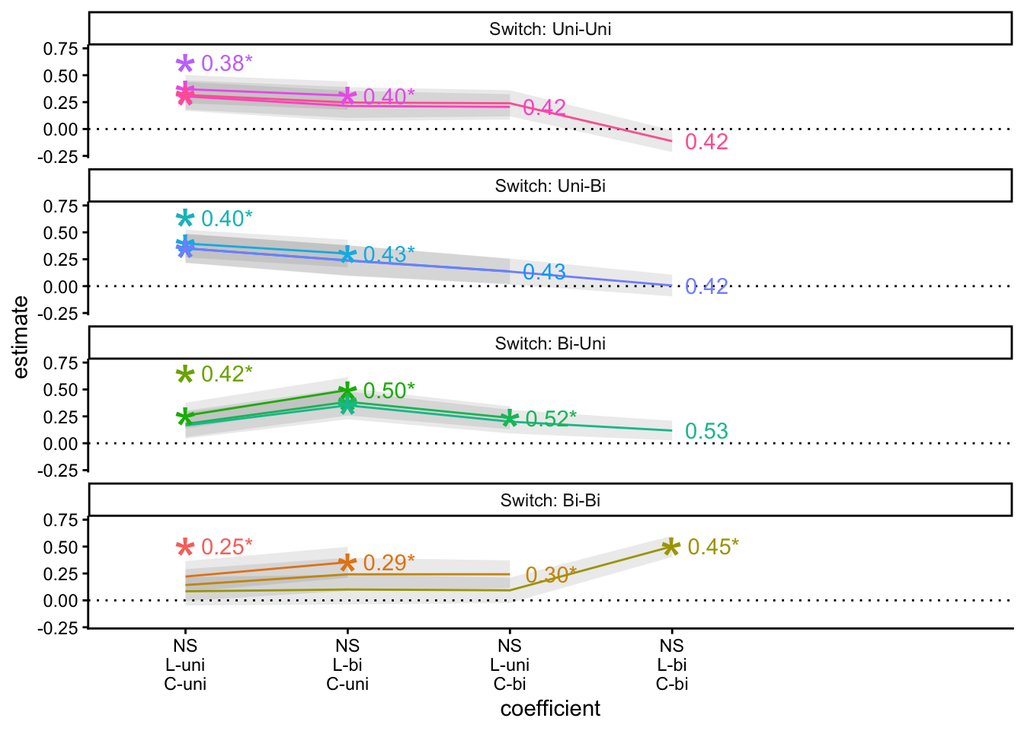

```r
ggplot(alt_run_v_model_summary, aes(x = coefficient, y = estimate, group = model, color = model))+
  geom_hline(yintercept = 0, linetype = "dotted")+
  geom_ribbon(aes(ymin = estimate - std_error,
                  ymax = estimate + std_error), alpha = 0.1, color = NA)+
  geom_line()+
  geom_text(data = alt_run_v_model_summary %>% group_by(model) %>% slice(n()),
            aes(label = r_adj_label), hjust = -0.3)+
  geom_point(data = alt_run_v_model_summary %>% filter(is_sig == 1), pch = "*", size = 10)+
  theme_classic()+
  facet_wrap(~outcome, labeller = labeller(outcome = c("uu" = "Switch: Uni-Uni",
                                                       "ub" = "Switch: Uni-Bi",
                                                       "bu" = "Switch: Bi-Uni",
                                                       "bb" = "Switch: Bi-Bi")), ncol = 1)+
  scale_x_discrete(labels = c("v_s0_cbiv0_lbiv1" = "NS\nL-bi\nC-uni",
                              "v_s0_cbiv1_lbiv1" = "NS\nL-bi\nC-bi",
                              "v_s0_cbiv0_lbiv0" = "NS\nL-uni\nC-uni",
                              "v_s0_cbiv1_lbiv0" = "NS\nL-uni\nC-bi",
                              "(Intercept)" = "Int"))+
  coord_cartesian(xlim = c(1, 5.5))+
  theme(legend.position = "none")
```

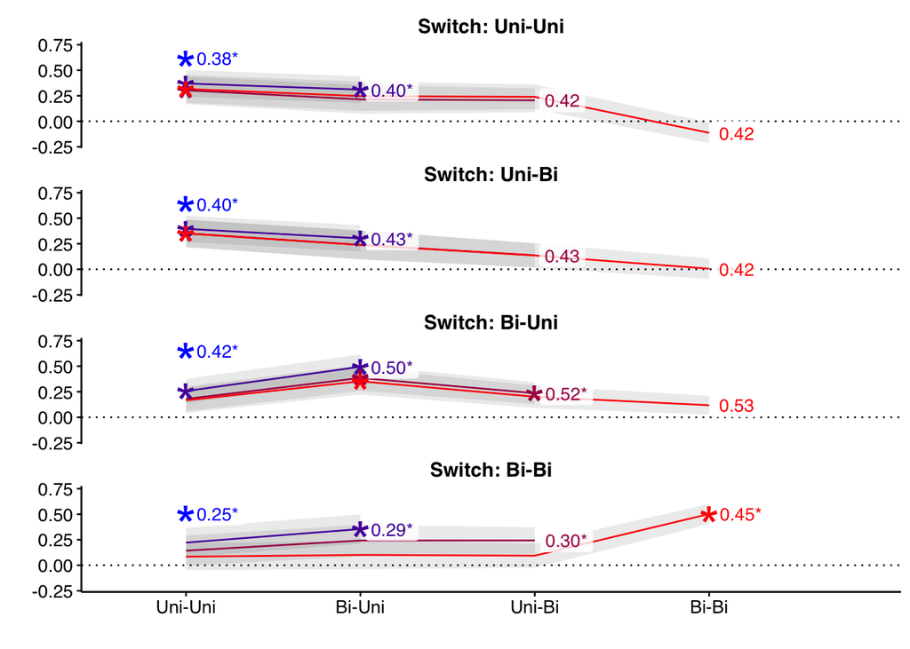

```r
plt_betw_v <- ggplot(alt_run_v_model_summary, aes(x = coefficient, y = estimate, group = model, color = color))+
  geom_hline(yintercept = 0, linetype = "dotted")+
  geom_ribbon(aes(ymin = estimate - std_error,
                  ymax = estimate + std_error), alpha = 0.1, color = NA)+
  geom_line()+
  # geom_text(data = alt_run_v_model_summary %>% group_by(model) %>% slice(n()),
  #           aes(label = r_adj_label), hjust = -0.3)+
  geom_label(data = alt_run_v_model_summary %>% group_by(model) %>% slice(n()),
            aes(label = r_adj_label), hjust = -0.1, alpha = 0.8, label.size = 0)+
  geom_point(data = alt_run_v_model_summary %>% filter(is_sig == 1), pch = "*", size = 10)+
  labs(x = "",
       y = "")+
  facet_wrap(~outcome, labeller = labeller(outcome = c("uu" = "Switch: Uni-Uni",
                                                       "ub" = "Switch: Uni-Bi",
                                                       "bu" = "Switch: Bi-Uni",
                                                       "bb" = "Switch: Bi-Bi")), ncol = 1)+
  scale_color_manual(values = colorRampPalette(c("blue", "red"))(n))+
  scale_x_discrete(labels = c("v_s0_cbiv0_lbiv1" = "Bi-Uni",
                              "v_s0_cbiv1_lbiv1" = "Bi-Bi",
                              "v_s0_cbiv0_lbiv0" = "Uni-Uni",
                              "v_s0_cbiv1_lbiv0" = "Uni-Bi",
                              "(Intercept)" = "Int"))+
  coord_cartesian(xlim = c(1, 4.5))+
  theme(legend.position = "none")

plt_betw_v
```

```r
ggsave(plot = plt_betw_v, "figures/AR_betw_v.svg", width = 4, height = 6, units = "in")
saveRDS(plt_betw_v, "figures/AR_betw_v.RDS")
```

### 8.4.1 Model comp: univalent - univalent

```r
compare_models(alt_run_indiv_diff_models$v, "uu")$comparison
```

```
## Analysis of Variance Table
##
## Model 1: v_s1_cbiv0_lbiv0 ~ 1
## Model 2: v_s1_cbiv0_lbiv0 ~ v_s0_cbiv0_lbiv0
## Model 3: v_s1_cbiv0_lbiv0 ~ v_s0_cbiv0_lbiv0 + v_s0_cbiv0_lbiv1
## Model 4: v_s1_cbiv0_lbiv0 ~ v_s0_cbiv0_lbiv0 + v_s0_cbiv0_lbiv1 + v_s0_cbiv1_lbiv0
## Model 5: v_s1_cbiv0_lbiv0 ~ v_s0_cbiv0_lbiv0 + v_s0_cbiv0_lbiv1 + v_s0_cbiv1_lbiv0 +
##     v_s0_cbiv1_lbiv1
##   Res.Df    RSS Df Sum of Sq       F    Pr(>F)
## 1     95 95.000
## 2     94 58.689  1    36.311 62.5011 5.999e-12 ***
## 3     93 55.365  1     3.324  5.7215   0.01882 *
## 4     92 53.591  1     1.774  3.0540   0.08391 .
## 5     91 52.868  1     0.723  1.2450   0.26746
## ---
## Signif. codes:  0 '***' 0.001 '**' 0.01 '*' 0.05 '.' 0.1 ' ' 1
```

### 8.4.2 Model comp: univalent - bivalent

```r
compare_models(alt_run_indiv_diff_models$v, "ub")$comparison
```

```
## Analysis of Variance Table
##
## Model 1: v_s1_cbiv0_lbiv1 ~ 1
## Model 2: v_s1_cbiv0_lbiv1 ~ v_s0_cbiv0_lbiv0
## Model 3: v_s1_cbiv0_lbiv1 ~ v_s0_cbiv0_lbiv0 + v_s0_cbiv0_lbiv1
## Model 4: v_s1_cbiv0_lbiv1 ~ v_s0_cbiv0_lbiv0 + v_s0_cbiv0_lbiv1 + v_s0_cbiv1_lbiv0
## Model 5: v_s1_cbiv0_lbiv1 ~ v_s0_cbiv0_lbiv0 + v_s0_cbiv0_lbiv1 + v_s0_cbiv1_lbiv0 +
##     v_s0_cbiv1_lbiv1
##   Res.Df    RSS Df Sum of Sq       F    Pr(>F)
## 1     95 95.000
## 2     94 56.338  1    38.662 67.1650 1.506e-12 ***
## 3     93 53.172  1     3.166  5.5002   0.02119 *
## 4     92 52.384  1     0.788  1.3689   0.24505
## 5     91 52.382  1     0.002  0.0033   0.95404
## ---
## Signif. codes:  0 '***' 0.001 '**' 0.01 '*' 0.05 '.' 0.1 ' ' 1
```

### 8.4.3 Model comp: bivalent - univalent

```r
compare_models(alt_run_indiv_diff_models$v, "bu")$comparison
```

```
## Analysis of Variance Table
##
## Model 1: v_s1_cbiv1_lbiv0 ~ 1
## Model 2: v_s1_cbiv1_lbiv0 ~ v_s0_cbiv0_lbiv0
## Model 3: v_s1_cbiv1_lbiv0 ~ v_s0_cbiv0_lbiv0 + v_s0_cbiv0_lbiv1
## Model 4: v_s1_cbiv1_lbiv0 ~ v_s0_cbiv0_lbiv0 + v_s0_cbiv0_lbiv1 + v_s0_cbiv1_lbiv0
## Model 5: v_s1_cbiv1_lbiv0 ~ v_s0_cbiv0_lbiv0 + v_s0_cbiv0_lbiv1 + v_s0_cbiv1_lbiv0 +
##     v_s0_cbiv1_lbiv1
##   Res.Df    RSS Df Sum of Sq       F    Pr(>F)
## 1     95 95.000
## 2     94 54.723  1    40.277 84.9513 1.110e-14 ***
## 3     93 46.271  1     8.452 17.8262 5.725e-05 ***
## 4     92 43.938  1     2.333  4.9215   0.02901 *
## 5     91 43.145  1     0.792  1.6712   0.19937
## ---
## Signif. codes:  0 '***' 0.001 '**' 0.01 '*' 0.05 '.' 0.1 ' ' 1
```

### 8.4.4 Model comp: bivalent - bivalent

```r
compare_models(alt_run_indiv_diff_models$v, "bb")$comparison
```

```
## Analysis of Variance Table
##
## Model 1: v_s1_cbiv1_lbiv1 ~ 1
## Model 2: v_s1_cbiv1_lbiv1 ~ v_s0_cbiv0_lbiv0
## Model 3: v_s1_cbiv1_lbiv1 ~ v_s0_cbiv0_lbiv0 + v_s0_cbiv0_lbiv1
## Model 4: v_s1_cbiv1_lbiv1 ~ v_s0_cbiv0_lbiv0 + v_s0_cbiv0_lbiv1 + v_s0_cbiv1_lbiv0
## Model 5: v_s1_cbiv1_lbiv1 ~ v_s0_cbiv0_lbiv0 + v_s0_cbiv0_lbiv1 + v_s0_cbiv1_lbiv0 +
##     v_s0_cbiv1_lbiv1
##   Res.Df    RSS Df Sum of Sq       F    Pr(>F)
## 1     95 95.000
## 2     94 70.805  1   24.1953 44.3474 2.041e-09 ***
## 3     93 66.458  1    4.3466  7.9669  0.005851 **
## 4     92 63.986  1    2.4726  4.5319  0.035969 *
## 5     91 49.648  1   14.3373 26.2789 1.652e-06 ***
## ---
## Signif. codes:  0 '***' 0.001 '**' 0.01 '*' 0.05 '.' 0.1 ' ' 1
```

## 8.5 v NA

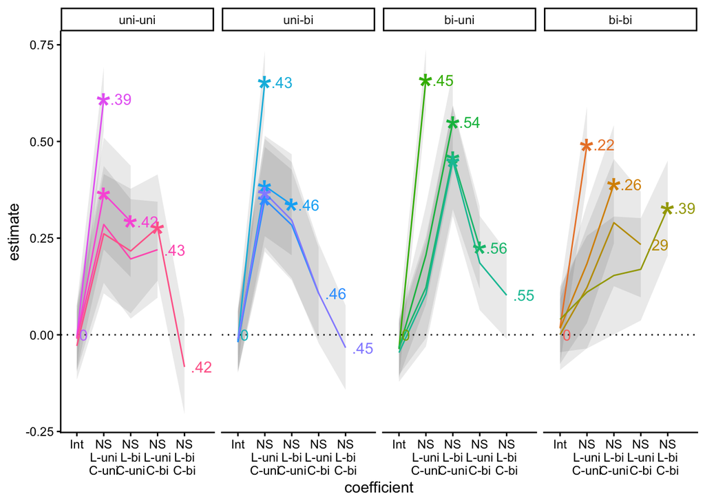

```r
alt_run_v_NA_model_summary <- lapply(alt_run_indiv_diff_models$v_NA, function(x){
  m_sum <- x %>%
    summary()

  m_sum %>%
    coef() %>%
    as.data.frame() %>%
    mutate(r_sq = m_sum$r.squared,
           r_sq_adj = m_sum$adj.r.squared)

}) %>%
  bind_rows(.id = "model") %>%
  rownames_to_column("coefficient") %>%
  janitor::clean_names() %>%
  mutate(coefficient = gsub("\\...[[:digit:]]+", "", coefficient),
         coefficient = gsub("v_", "", coefficient),
         coefficient = gsub("_NA", "", coefficient),
         outcome = gsub("[[:digit:]]", "", model),
         outcome = factor(outcome, levels = c("uu", "ub", "bu", "bb")),
         is_sig = ifelse(pr_t < 0.05, 1, 0),
         r_label = as.character(round(r_sq, 2)),
         r_label = gsub("^0.", ".", r_label),
         r_adj_label = as.character(round(r_sq_adj, 2)),
         r_adj_label = gsub("^0.", ".", r_adj_label),
         outcome = factor(outcome, levels = c("uu", "ub", "bu", "bb")),
         color = parse_number(model) %>% factor())


ggplot(alt_run_v_NA_model_summary, aes(x = coefficient, y = estimate, group = model, color = model))+
  geom_hline(yintercept = 0, linetype = "dotted")+
  geom_ribbon(aes(ymin = estimate - std_error,
                  ymax = estimate + std_error), alpha = 0.1, color = NA)+
  geom_line()+
  geom_text(data = alt_run_v_NA_model_summary %>% group_by(model) %>% slice(n()),
            aes(label = r_adj_label), hjust = -0.3)+
  geom_point(data = alt_run_v_NA_model_summary %>% filter(is_sig == 1), pch = "*", size = 10)+
  theme_classic()+
  facet_wrap(~outcome, labeller = labeller(outcome = c("uu" = "uni-uni",
                                                       "ub" = "uni-bi",
                                                       "bu" = "bi-uni",
                                                       "bb" = "bi-bi")), nrow = 1)+
  scale_x_discrete(labels = c("s0_cbiv0_lbiv1" = "NS\nL-bi\nC-uni",
                              "s0_cbiv1_lbiv1" = "NS\nL-bi\nC-bi",
                              "s0_cbiv0_lbiv0" = "NS\nL-uni\nC-uni",
                              "s0_cbiv1_lbiv0" = "NS\nL-uni\nC-bi",
                              "(Intercept)" = "Int"))+
  coord_cartesian(xlim = c(1, 5.5))+
  theme(legend.position = "none")
```

```r
# compare_models(alt_run_indiv_diff_models$v_NA, "uu")
# compare_models(alt_run_indiv_diff_models$v_NA, "ub")
# compare_models(alt_run_indiv_diff_models$v_NA, "bu")
# compare_models(alt_run_indiv_diff_models$v_NA, "bb")
```